# Data Visualization Analysis

**Design Principles Demonstrated:**

1. **Visual Hierarchy**: Most important metric on top
2. **Plot Type Selection**: Line for trends, bars for ratings
3. **Color Coding**: Different colors for different metrics
4. **Reference Lines**: Target satisfaction marked
5. **Consistent Formatting**: Similar styling across panels

**Advanced Layouts with GridSpec**

**Beyond Simple Grids:**

Sometimes you need asymmetric layouts where subplots have different sizes.

**GridSpec Allows:**

- Subplots spanning multiple cells
- Unequal subplot sizes
- Complex dashboard layouts
- Professional report structures

**Example: Executive Summary Layout**

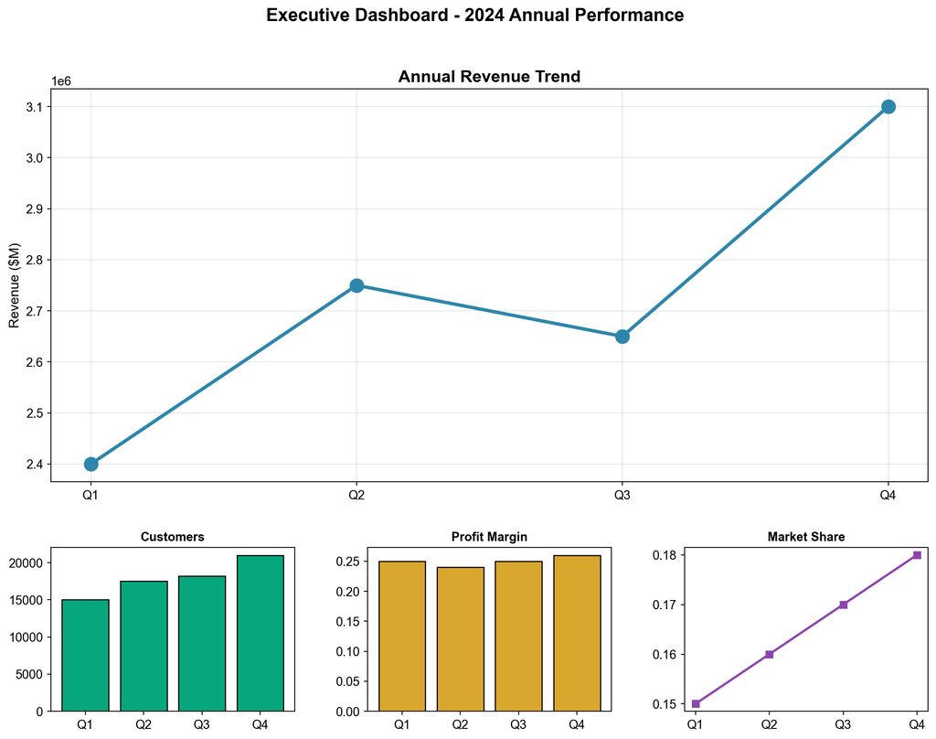

```python
import matplotlib.pyplot as plt
import matplotlib.gridspec as gridspec

fig = plt.figure(figsize=(14, 10))

# Create custom grid: 3 rows, 3 columns
gs = gridspec.GridSpec(3, 3, figure=fig, hspace=0.4, wspace=0.3)

# Large main plot spanning top 2 rows, all columns
ax_main = fig.add_subplot(gs[0:2, :])

# Three smaller plots in bottom row
ax_bottom_left = fig.add_subplot(gs[2, 0])
ax_bottom_center = fig.add_subplot(gs[2, 1])
ax_bottom_right = fig.add_subplot(gs[2, 2])

# Main plot: Primary metric (revenue trend)
quarters = ['Q1', 'Q2', 'Q3', 'Q4']
revenue = [2400000, 2750000, 2650000, 3100000]
ax_main.plot(quarters, revenue, marker='o', linewidth=3, markersize=12, color='#2E86AB')
ax_main.set_title('Annual Revenue Trend', fontsize=15, fontweight='bold')
ax_main.set_ylabel('Revenue ($M)', fontsize=12)
ax_main.grid(True, alpha=0.3)

# Bottom plots: Supporting metrics
# Left: Customer count
customers = [15000, 17500, 18200, 21000]
ax_bottom_left.bar(quarters, customers, color='#06A77D', edgecolor='black')
ax_bottom_left.set_title('Customers', fontsize=11, fontweight='bold')

# Center: Profit margin
margins = [0.25, 0.24, 0.25, 0.26]
ax_bottom_center.bar(quarters, margins, color='#D9A72E', edgecolor='black')
ax_bottom_center.set_title('Profit Margin', fontsize=11, fontweight='bold')

# Right: Market share
share = [0.15, 0.16, 0.17, 0.18]
ax_bottom_right.plot(quarters, share, marker='s', linewidth=2, color='#8E44AD')
ax_bottom_right.set_title('Market Share', fontsize=11, fontweight='bold')

fig.suptitle('Executive Dashboard - 2024 Annual Performance',
             fontsize=16, fontweight='bold')

plt.savefig('M2L03_Executive_Dashboard.png', dpi=300, bbox_inches='tight')
plt.show()
```

**Output:**

*[Chart: “Annual Revenue Trend”, y: Revenue ($M)]*

**When to Use GridSpec:**

- Dashboard with featured metric + supporting metrics
- Report with main chart + detail insets
- Comparison where one metric needs more emphasis
- Publications with specific layout requirements

### 2.3.3 Lab Session

**Lab 3: Building Multi-Panel Dashboards**

**Objective:** Create professional multi-plot visualizations that present comprehensive business analyses in cohesive, easy-to-understand formats.

**Scenario:** You’re the Business Intelligence Analyst at “RetailMax Corporation.” The Q4 Board Meeting is next week, and executives need comprehensive dashboards showing performance across multiple dimensions. You’ll create three different multi-panel visualizations for different audiences.

**Pre-Lab Setup:**

1. Create file: `M2L03_YourName_Dashboards.py`
2. Import matplotlib.pyplot and any needed libraries
3. Create output folder: “Lab3_Outputs”

**Part A: Regional Performance Dashboard (35 points)**

**Context:** The VP of Sales needs to compare performance across four regions simultaneously to identify best practices and struggling areas.

**Data:**

```python
months = ['Jan', 'Feb', 'Mar', 'Apr', 'May', 'Jun']
northeast = [145000, 158000, 152000, 171000, 168000, 182000]
southeast = [132000, 138000, 145000, 151000, 158000, 165000]
midwest = [158000, 171000, 165000, 183000, 178000, 195000]
west = [141000, 145000, 148000, 162000, 171000, 178000]
```

**Tasks:**

1. **Create 2x2 regional comparison (20 points):**
   - Figure size: (14, 10)
   - Create four subplots (2 rows, 2 columns)
   - Share Y-axis across all subplots for fair comparison
   - Layout: Northeast (top-left), Southeast (top-right), Midwest (bottom-left), West (bottom-right)
   - Each subplot: Line plot with markers
   - Use consistent color (#2E86AB) across all regions
   - Line width: 2.5, marker size: 8
2. **Format each subplot (10 points):**
   - Title for each: “{Region} Region Sales”
   - X-label on bottom row only: “Month”
   - Y-label on left column only: “Sales Revenue ($)”
   - Grid on all plots (alpha=0.3)
   - Overall figure title: “Regional Sales Performance - H1 2024”
3. **Polish and save (5 points):**
   - Use tight_layout()
   - Save as: `M2L03_YourName_RegionalDashboard.png`
   - High resolution (dpi=300)

**Part B: Product Performance Vertical Dashboard (30 points)**

**Context:** The Product Manager needs a comprehensive view of how the flagship product is performing across multiple metrics.

**Data:**

```python
quarters = ['Q1', 'Q2', 'Q3', 'Q4']
units_sold = [8500, 9200, 11000, 12500]
avg_price = [349, 339, 329, 319]
customer_satisfaction = [4.1, 4.3, 4.5, 4.6]
return_rate = [0.08, 0.07, 0.06, 0.05]  # 8%, 7%, 6%, 5%
```

**Tasks:**

1. **Create 4-panel vertical stack (15 points):**
   - Figure size: (12, 14)
   - Four subplots in one column (4 rows, 1 column)
   - Share X-axis across all subplots
   - Panel 1: Units Sold (line plot, markers, color: #2E86AB)
   - Panel 2: Average Price (line plot, markers, color: #D9A72E)
   - Panel 3: Customer Satisfaction (bar plot, color: #06A77D)
   - Panel 4: Return Rate (bar plot, color: #E74C3C)
2. **Professional formatting (10 points):**
   - Each panel title: “{Metric Name}” (left-aligned, size 13, bold)
   - Y-labels appropriate for each metric
   - X-label only on bottom plot: “Quarter”
   - Format satisfaction as “4.5” (one decimal)
   - Format return rate as percentage: “8%”, “7%”, etc.
   - Grid on all plots
3. **Add business context (5 points):**
   - On satisfaction plot: Add horizontal red dashed line at 4.0 (target)
   - On return rate plot: Add horizontal red dashed line at 0.07 (industry average)
   - Include legends for reference lines
   - Overall title: “Flagship Product Performance Dashboard - 2024”

**Part C: Executive KPI Dashboard (35 points)**

**Context:** The CEO needs a high-level dashboard with the most important KPIs visible at a glance, with one primary metric emphasized.

**Data:**

```python
months = ['Jan', 'Feb', 'Mar', 'Apr', 'May', 'Jun', 'Jul', 'Aug', 'Sep', 'Oct', 'Nov', 'Dec']
monthly_revenue = [2100000, 2250000, 2400000, 2350000, 2500000, 2650000,
                   2600000, 2750000, 2850000, 2800000, 3100000, 3200000]
monthly_profit = [420000, 450000, 480000, 470000, 500000, 530000,
                  520000, 550000, 570000, 560000, 620000, 640000]
customer_count = [45000, 47000, 49000, 51000, 54000, 57000,
                  60000, 63000, 66000, 69000, 73000, 78000]
employee_count = [450, 455, 460, 465, 470, 475,
                  480, 485, 490, 495, 500, 505]
```

**Tasks:**

1. **Create custom layout using GridSpec (15 points):**
   - Figure size: (16, 10)
   - Use GridSpec to create:
     - Top section: One large plot spanning full width (2 rows)
     - Bottom section: Three equal smaller plots (1 row, 3 columns)
   - Main plot: Revenue trend (line, thick, prominent)
   - Bottom-left: Profit trend (line)
   - Bottom-center: Customer growth (line or bar)
   - Bottom-right: Employee headcount (bar)
2. **Emphasize hierarchy (12 points):**
   - Main plot styling:
     - Larger title (size 15, bold)
     - Thicker line (width 4)
     - Larger markers (size 12)
     - Color: #1F4788 (professional blue)
     - More prominent grid
   - Supporting plots styling:
     - Smaller titles (size 11, bold)
     - Standard line width (2.5)
     - Consistent color scheme
     - Lighter grids
3. **Professional finish (8 points):**
   - Format main plot Y-axis as millions: “$2.1M”, “$3.2M”, etc.
   - Format all numbers appropriately
   - Overall figure title: “RetailMax Corporation - 2024 Annual Performance”
     - Size 17, bold, positioned properly
   - Use subplots_adjust or tight_layout for optimal spacing
   - Save as: `M2L03_YourName_ExecutiveDashboard.png`

**Bonus Challenge (+20 points):**

**Create an Interactive Comparison Dashboard:**

Use the following data for 3 products:

```python
quarters = ['Q1 2023', 'Q2 2023', 'Q3 2023', 'Q4 2023',
            'Q1 2024', 'Q2 2024', 'Q3 2024', 'Q4 2024']
product_a_sales = [450, 480, 510, 540, 580, 620, 650, 680]
product_b_sales = [380, 390, 410, 430, 460, 490, 520, 550]
product_c_sales = [290, 310, 330, 360, 390, 420, 450, 480]
```

**Requirements:**

1. Create a 3x3 grid (9 subplots)
2. Top row: Sales trends for each product (3 separate plots)
3. Middle row: Year-over-year growth rates for each product
   - Calculate: (2024 value - 2023 value) / 2023 value
4. Bottom row: Market share comparison (stacked or grouped bars)
5. Use shared axes where appropriate
6. Apply professional color scheme (colorblind-friendly)
7. Include comprehensive labels and legends
8. Add overall insights as text annotations

**Deliverables:**

1. Python file: `M2L03_YourName_Dashboards.py`
2. PNG files:
   - `M2L03_YourName_RegionalDashboard.png`
   - `M2L03_YourName_ProductDashboard.png`
   - `M2L03_YourName_ExecutiveDashboard.png`
   - `M2L03_YourName_Bonus.png` (if bonus attempted)

**Grading Rubric:**

- Part A (Regional Dashboard): 35 points
- Part B (Product Dashboard): 30 points
- Part C (Executive Dashboard): 35 points
- Bonus: +20 points

**Success Criteria:**

- All subplots display correctly
- Shared axes used appropriately for comparisons
- Visual hierarchy established (main vs. supporting plots)
- Consistent formatting within each dashboard
- Professional appearance suitable for executive presentation
- All numbers formatted appropriately
- Proper spacing (no overlapping elements)
- High-resolution outputs
- Code well-organized with comments

**Design Best Practices:**

1. **Consistency**: Use same colors, fonts, styles within each dashboard
2. **Hierarchy**: Emphasize most important information
3. **Comparison**: Shared axes when comparing similar metrics
4. **Context**: Reference lines, targets, benchmarks where relevant
5. **Clarity**: Each subplot should be self-explanatory
6. **Professionalism**: Clean, polished, presentation-ready

**Common Pitfalls to Avoid:**

- Inconsistent colors across related subplots
- Missing labels on any subplot
- Overlapping titles or labels
- Different scales making comparison difficult
- Too much information crowded together
- Inconsistent formatting across panels
- Poor use of space (too cramped or too spread out)

## 2.4 Section 4: Business Charts (Bar, Line, and Pie Charts)

### 2.4.1 Objective

- Master bar charts for categorical comparisons
- Create effective line charts for temporal analysis
- Understand when (and when not) to use pie charts
- Apply horizontal vs. vertical bar chart layouts appropriately
- Use grouped and stacked bars for complex comparisons
- Follow visualization best practices for business communication

### 2.4.2 Main Contents with Examples

**Bar Charts - The Foundation of Categorical Comparison**

**Why Bar Charts Dominate Business:**

Bar charts are the most common visualization in business because they excel at answering the fundamental question: **“How do these categories compare?”**

**Perfect for:**

- Sales by region
- Revenue by product line
- Performance by salesperson
- Budget by department
- Customer count by segment

**The Human Visual System:**

- We’re excellent at comparing bar lengths
- Horizontal alignment makes comparison natural
- Clear, unambiguous representation
- Works well in black-and-white (important for printing)

**Basic Vertical Bar Chart:**

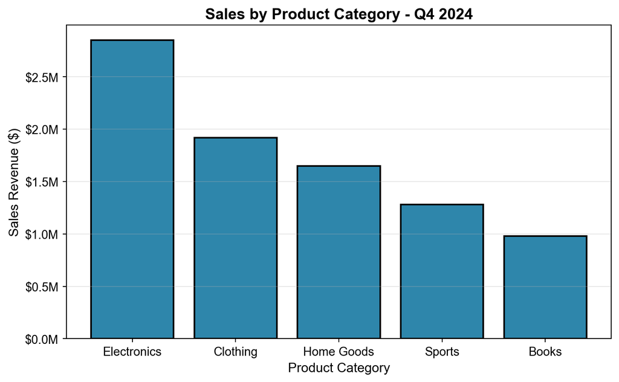

```python
import matplotlib.pyplot as plt

# Sales by product category
categories = ['Electronics', 'Clothing', 'Home Goods', 'Sports', 'Books']
sales = [2850000, 1920000, 1650000, 1280000, 980000]

fig, ax = plt.subplots(figsize=(8, 5))

ax.bar(categories, sales, color='#2E86AB', edgecolor='black', linewidth=1.5)

ax.set_title('Sales by Product Category - Q4 2024', fontsize=14, fontweight='bold')
ax.set_xlabel('Product Category', fontsize=12)
ax.set_ylabel('Sales Revenue ($)', fontsize=12)

# Format Y-axis as millions
ax.yaxis.set_major_formatter(plt.FuncFormatter(lambda x, p: f'${x/1e6:.1f}M'))

ax.grid(True, alpha=0.3, axis='y')

plt.tight_layout()
plt.show()
```

**Output:**

*[Bar chart: “Sales by Product Category - Q4 2024”, x: Product Category, y: Sales Revenue ($)]*

**Key Bar Chart Elements:**

- **Width**: Bars should be consistent width
- **Spacing**: Slight gap between bars aids readability
- **Baseline**: Always starts at zero (critical for honest comparison)
- **Edge color**: Defines bar boundaries clearly
- **Grid**: Horizontal grid lines help reading values

**Horizontal Bar Charts - When to Switch Orientation**

**Use Horizontal Bars When:**

1. **Long category names**: “North American Technology Division” won’t fit under vertical bar
2. **Many categories**: >8 categories become crowded vertically
3. **Emphasis on ranking**: Horizontal layout emphasizes order
4. **Reading flow**: Top-to-bottom feels natural for rankings

**Creating Horizontal Bars:**

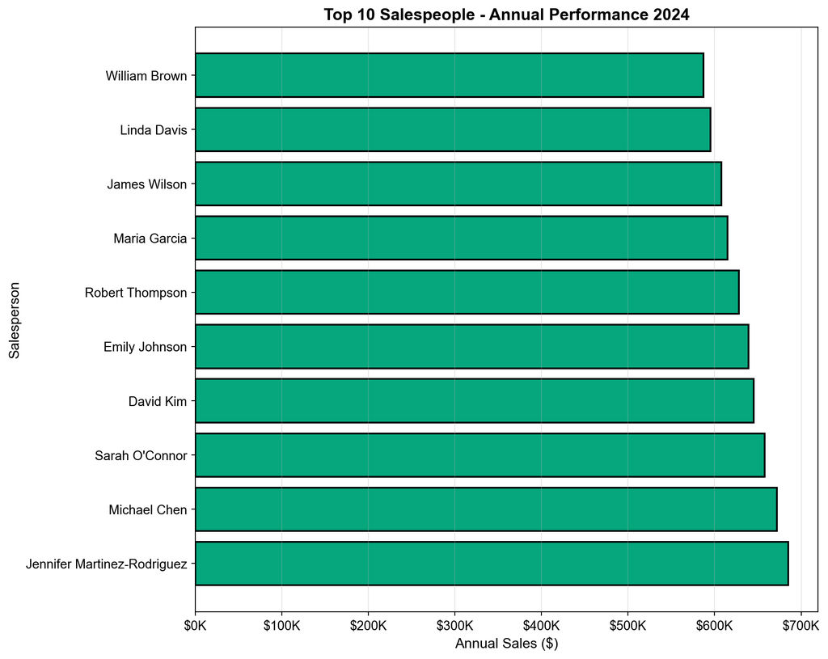

```python
import matplotlib.pyplot as plt

# Top 10 salespeople (long names)
salespeople = ['Jennifer Martinez-Rodriguez', 'Michael Chen',
               'Sarah O\'Connor', 'David Kim', 'Emily Johnson',
               'Robert Thompson', 'Maria Garcia', 'James Wilson',
               'Linda Davis', 'William Brown']
sales = [685000, 672000, 658000, 645000, 639000,
         628000, 615000, 608000, 595000, 587000]

fig, ax = plt.subplots(figsize=(10, 8))

# Use barh() for horizontal
ax.barh(salespeople, sales, color='#06A77D', edgecolor='black', linewidth=1.5)

ax.set_title('Top 10 Salespeople - Annual Performance 2024',
             fontsize=14, fontweight='bold')
ax.set_xlabel('Annual Sales ($)', fontsize=12)
ax.set_ylabel('Salesperson', fontsize=12)

# Format X-axis as thousands with K suffix
ax.xaxis.set_major_formatter(plt.FuncFormatter(lambda x, p: f'${x/1000:.0f}K'))

ax.grid(True, alpha=0.3, axis='x')

plt.tight_layout()
plt.show()
```

**Output:**

*[Horizontal bar chart: “Top 10 Salespeople - Annual Performance 2024”, x: Annual Sales ($), y: Salesperson]*

**Horizontal Bar Advantages:**

**Grouped Bar Charts - Comparing Multiple Series**

**The Business Need:**

Compare the same categories across different groups:

- This year vs. last year by quarter
- Actual vs. budget by department
- Male vs. female customers by age group
- Product sales across different regions

**Creating Grouped Bars:**

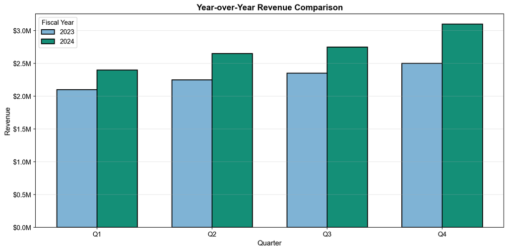

```python
import matplotlib.pyplot as plt
import numpy as np

# Quarterly revenue: 2023 vs 2024
quarters = ['Q1', 'Q2', 'Q3', 'Q4']
revenue_2023 = [2100000, 2250000, 2350000, 2500000]
revenue_2024 = [2400000, 2650000, 2750000, 3100000]

fig, ax = plt.subplots(figsize=(12, 6))

# Position bars side-by-side
x = np.arange(len(quarters))  # [0, 1, 2, 3]
width = 0.35  # Width of each bar

# Create grouped bars
bars1 = ax.bar(x - width/2, revenue_2023, width, label='2023',
               color='#7FB3D5', edgecolor='black', linewidth=1.5)
bars2 = ax.bar(x + width/2, revenue_2024, width, label='2024',
               color='#148F77', edgecolor='black', linewidth=1.5)

# Set x-axis labels
ax.set_xticks(x)
ax.set_xticklabels(quarters)

ax.set_title('Year-over-Year Revenue Comparison', fontsize=14, fontweight='bold')
ax.set_xlabel('Quarter', fontsize=12)
ax.set_ylabel('Revenue', fontsize=12)

# Format Y-axis
ax.yaxis.set_major_formatter(plt.FuncFormatter(lambda x, p: f'${x/1e6:.1f}M'))

ax.legend(title='Fiscal Year', fontsize=11)
ax.grid(True, alpha=0.3, axis='y')

plt.tight_layout()
plt.show()
```

**Output:**

*[Bar chart: “Year-over-Year Revenue Comparison”, x: Quarter, y: Revenue]*

**Grouped Bar Formula:**

- Calculate positions: `x = np.arange(len(categories))`
- Offset bars: `x - width/2` for first group, `x + width/2` for second
- For three groups: `x - width`, `x`, `x + width`

**When to Use Grouped Bars:**

- Comparing 2-4 groups
- Each category has multiple values
- Differences within categories matter more than totals

**Stacked Bar Charts - Showing Part-to-Whole**

**The Composition Question:**

Stacked bars answer: “What makes up this total?”

- Revenue by product line per quarter (total quarterly revenue)
- Budget allocation by department per year (total yearly budget)
- Employee distribution by level per division (total employees)

**Creating Stacked Bars:**

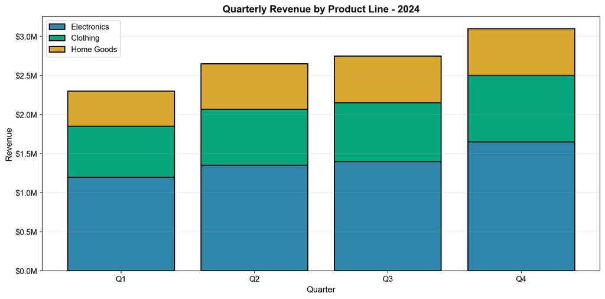

```python
import matplotlib.pyplot as plt
import numpy as np

# Quarterly revenue by product line
quarters = ['Q1', 'Q2', 'Q3', 'Q4']
electronics = [1200000, 1350000, 1400000, 1650000]
clothing = [650000, 720000, 750000, 850000]
home_goods = [450000, 580000, 600000, 600000]

fig, ax = plt.subplots(figsize=(12, 6))

# Stack bars on top of each other
ax.bar(quarters, electronics, label='Electronics',
       color='#2E86AB', edgecolor='black', linewidth=1.5)
ax.bar(quarters, clothing, bottom=electronics, label='Clothing',
       color='#06A77D', edgecolor='black', linewidth=1.5)
ax.bar(quarters, home_goods,
       bottom=np.array(electronics) + np.array(clothing),
       label='Home Goods', color='#D9A72E', edgecolor='black', linewidth=1.5)

ax.set_title('Quarterly Revenue by Product Line - 2024',
             fontsize=14, fontweight='bold')
ax.set_xlabel('Quarter', fontsize=12)
ax.set_ylabel('Revenue', fontsize=12)

# Format Y-axis
ax.yaxis.set_major_formatter(plt.FuncFormatter(lambda x, p: f'${x/1e6:.1f}M'))

ax.legend(loc='upper left', fontsize=11)
ax.grid(True, alpha=0.3, axis='y')

plt.tight_layout()
plt.show()
```

**Output:**

*[Bar chart: “Quarterly Revenue by Product Line - 2024”, x: Quarter, y: Revenue]*

**Stacked Bar Logic:**

- First series: Normal bar chart
- Second series: Use `bottom=first_series` to stack on top
- Third series: `bottom=first_series + second_series`

**When to Use Stacked Bars:**

- Total matters AND components matter
- Showing composition over time
- Limited categories (3-5 stacks maximum)
- Colors are distinctive

**Warning:** Stacked bars make it hard to compare middle sections. Only the bottom section and total are easy to compare.

**Line Charts - Temporal Trends and Continuous Data**

**The Time Series Specialist:**

Line charts are the default for showing change over time because:

- Lines imply continuity between points
- Slopes show rate of change
- Trends are immediately visible
- Multiple series can be compared easily

**When Line Charts Excel:**

- Monthly sales trends
- Stock prices over time
- Temperature readings
- Website traffic patterns
- Any sequential data

**Professional Line Chart:**

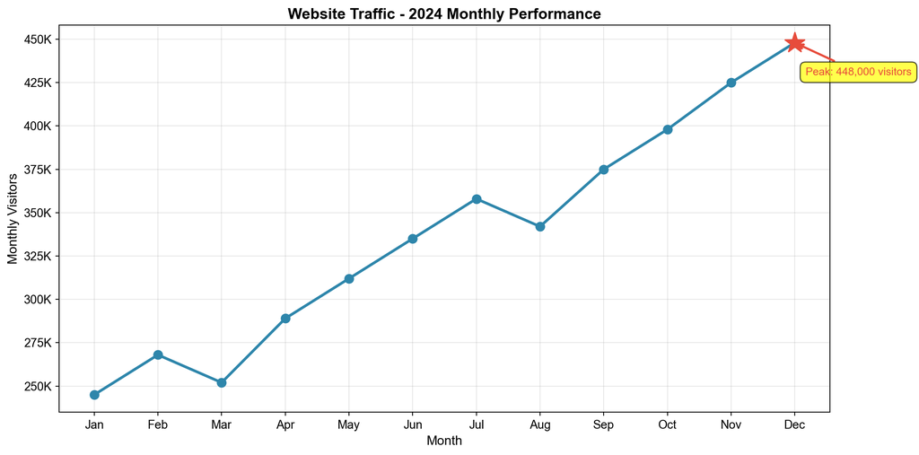

```python
import matplotlib.pyplot as plt

# Monthly website traffic
months = ['Jan', 'Feb', 'Mar', 'Apr', 'May', 'Jun',
          'Jul', 'Aug', 'Sep', 'Oct', 'Nov', 'Dec']
visitors = [245000, 268000, 252000, 289000, 312000, 335000,
            358000, 342000, 375000, 398000, 425000, 448000]

fig, ax = plt.subplots(figsize=(12, 6))

ax.plot(months, visitors, marker='o', linewidth=2.5, markersize=8,
        color='#2E86AB')

# Highlight peak month
max_idx = visitors.index(max(visitors))
ax.plot(months[max_idx], visitors[max_idx], marker='*',
        markersize=20, color='#E74C3C', zorder=3)

ax.set_title('Website Traffic - 2024 Monthly Performance',
             fontsize=14, fontweight='bold')
ax.set_xlabel('Month', fontsize=12)
ax.set_ylabel('Monthly Visitors', fontsize=12)

# Format Y-axis with K suffix
ax.yaxis.set_major_formatter(plt.FuncFormatter(lambda x, p: f'{x/1000:.0f}K'))

# Annotate peak
ax.annotate(f'Peak: {max(visitors):,} visitors',
            xy=(months[max_idx], visitors[max_idx]),
            xytext=(10, -30), textcoords='offset points',
            fontsize=10, color='#E74C3C',
            bbox=dict(boxstyle='round,pad=0.5', facecolor='yellow', alpha=0.7),
            arrowprops=dict(arrowstyle='->', color='#E74C3C', lw=2))

ax.grid(True, alpha=0.3)

plt.tight_layout()
plt.show()
```

**Output:**

*[Line chart: “Website Traffic - 2024 Monthly Performance”, x: Month, y: Monthly Visitors]*

**Advanced Line Chart Features:**

- **Markers**: Emphasize data points
- **Annotations**: Highlight important events
- **Reference lines**: Show targets or benchmarks
- **Shading**: Highlight specific periods
- **Multiple lines**: Compare trends

**Pie Charts - Use Sparingly and Wisely**

**The Controversial Chart:**

Pie charts are controversial in data visualization:

- **Proponents**: Intuitive, shows parts of whole clearly
- **Critics**: Humans are bad at comparing angles/areas

**When Pie Charts Work:**

- **Few categories** (3-5 maximum, ideally 2-3)
- **Clear majority**: One category dominates (>50%)
- **Simple message**: “X makes up most of our Y”
- **Non-technical audience**: Familiar and accessible

**When to Avoid Pie Charts:**

- Many categories (use bar chart)
- Similar-sized categories (angles too hard to compare)
- Comparing multiple pies (very difficult)
- Precise comparisons needed (bar chart better)

**Creating an Effective Pie Chart:**

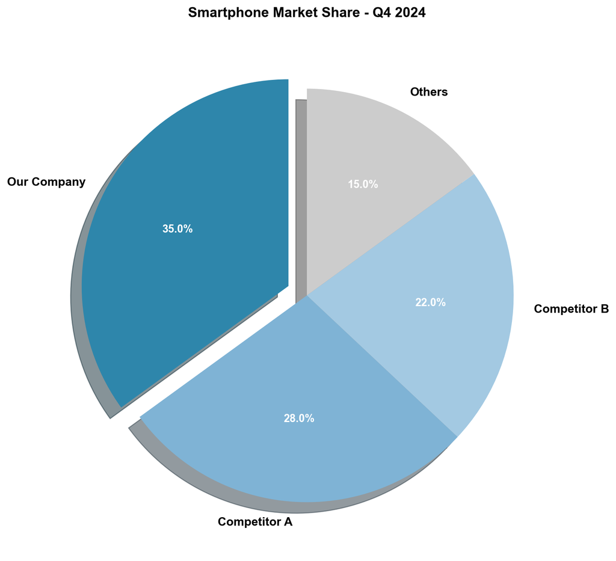

```python
import matplotlib.pyplot as plt

# Market share (simple, clear story)
companies = ['Our Company', 'Competitor A', 'Competitor B', 'Others']
market_share = [35, 28, 22, 15]

fig, ax = plt.subplots(figsize=(10, 8))

# Create pie chart
colors = ['#2E86AB', '#7FB3D5', '#A3C9E2', '#CCCCCC']
explode = (0.1, 0, 0, 0)  # Emphasize our company

wedges, texts, autotexts = ax.pie(market_share,
                                    labels=companies,
                                    autopct='%1.1f%%',
                                    startangle=90,
                                    colors=colors,
                                    explode=explode,
                                    shadow=True)

# Format text
for text in texts:
    text.set_fontsize(12)
    text.set_fontweight('bold')

for autotext in autotexts:
    autotext.set_color('white')
    autotext.set_fontsize(11)
    autotext.set_fontweight('bold')

ax.set_title('Smartphone Market Share - Q4 2024',
             fontsize=14, fontweight='bold', pad=20)

plt.tight_layout()
plt.show()
```

**Output:**

*[Pie chart: “Smartphone Market Share - Q4 2024”]*

**Pie Chart Best Practices:**

**Better Alternatives to Pie Charts:**

For most situations, consider:

- **Horizontal bar chart**: Easier comparison of categories
- **Donut chart**: Same as pie, but central hole can hold title/total
- **Treemap**: For hierarchical data
- **Stacked percentage bar**: Shows composition more clearly

**Choosing the Right Chart Type**

**Decision Framework:**

**Question: How do categories compare?** → **Bar Chart** (vertical or horizontal)

**Question: How has this changed over time?** → **Line Chart**

**Question: What is the composition of this whole?** → **Stacked Bar Chart** or **Pie Chart** (if 2-3 categories)

**Question: How do multiple groups compare across categories?** → **Grouped Bar Chart**

**Question: What is the relationship between two variables?** → **Scatter Plot** (covered in Section 1)

**Chart Selection Table:**

| Data Type | Best Chart | When to Use | Avoid If |
| --- | --- | --- | --- |
| Categories vs Values | Vertical Bar | Few categories, short names | >12 categories |
| Categories vs Values | Horizontal Bar | Long names, many categories, rankings | Categories unordered |
| Time Series | Line Chart | Continuous data, trends important | Few time points |
| Comparison Over Time | Grouped Bar | 2-4 groups, emphasis on periods | Many groups |
| Part-to-Whole | Stacked Bar | Composition changes, total matters | >5 components |
| Part-to-Whole | Pie Chart | 2-4 categories, simple message | Precise comparison needed |

### 2.4.3 Lab Session

**Lab 4: Comprehensive Business Charts**

**Objective:** Master bar charts, line charts, and pie charts by creating a complete analytical report for a business scenario.

**Scenario:** You’re the Data Analyst at “MetroMart Retail,” a regional supermarket chain. The Annual Strategy Meeting is approaching, and leadership needs comprehensive visualizations analyzing 2024 performance across products, time, regions, and categories. You’ll create a professional analytical report with multiple chart types.

**Pre-Lab Setup:**

1. Create file: `M2L04_YourName_BusinessCharts.py`
2. Import necessary libraries
3. Create output folder: “Lab4_Outputs”

**Part A: Product Category Performance (25 points)**

**Context:** The Merchandising VP needs to see which product categories drove the most revenue.

**Data:**

```python
categories = ['Fresh Produce', 'Dairy & Eggs', 'Meat & Seafood',
              'Bakery', 'Frozen Foods', 'Beverages', 'Snacks', 'Health & Beauty']
annual_revenue = [4850000, 3920000, 3650000, 2180000, 2950000,
                  3120000, 2680000, 1850000]
```

**Tasks:**

1. **Create professional vertical bar chart (15 points):**
   - Figure size: (12, 7)
   - Bars with color: #2E86AB
   - Black edge color, line width 1.5
   - Sort bars from highest to lowest revenue
   - Add horizontal grid lines (alpha=0.3)
2. **Format professionally (10 points):**
   - Title: “Annual Revenue by Product Category - 2024”
   - Y-axis label: “Revenue”
   - X-axis label: “Product Category”
   - Format Y-axis as millions: “$4.9M”, “$3.9M”, etc.
   - Rotate X-axis labels 45 degrees, right-aligned
   - Save as: `M2L04_YourName_CategoryRevenue.png`

**Part B: Monthly Sales Trend Analysis (25 points)**

**Context:** The Finance team needs to see monthly revenue patterns to identify seasonality and trends.

**Data:**

```python
months = ['Jan', 'Feb', 'Mar', 'Apr', 'May', 'Jun',
          'Jul', 'Aug', 'Sep', 'Oct', 'Nov', 'Dec']
monthly_revenue = [2180000, 2050000, 2320000, 2280000, 2450000, 2390000,
                   2520000, 2480000, 2350000, 2580000, 2850000, 3150000]
```

**Tasks:**

1. **Create trend line chart (12 points):**
   - Figure size: (14, 6)
   - Line color: #148F77 (dark green)
   - Line width: 3
   - Circular markers, size 10
   - Add semi-transparent markers (alpha=0.6)
2. **Add analytical features (8 points):**
   - Highlight December (peak month) with red star marker (size 20)
   - Add annotation pointing to December with text: “Holiday Peak: $3.15M”
   - Add horizontal reference line at $2.5M (dashed, red, label “Target”)
   - Include legend for reference line
3. **Professional formatting (5 points):**
   - Title: “MetroMart - 2024 Monthly Revenue Trend”
   - Format Y-axis as millions
   - Grid with alpha=0.3
   - Save as: `M2L04_YourName_MonthlyTrend.png`

**Part C: Regional Comparison (25 points)**

**Context:** Operations needs to compare performance across store regions.

**Data:**

```python
regions = ['Downtown Metro', 'Suburban North', 'Suburban South',
           'Suburban East', 'Suburban West', 'Urban Center']
q1_sales = [2850000, 3120000, 2980000, 2750000, 3050000, 2890000]
q2_sales = [3020000, 3280000, 3150000, 2920000, 3180000, 3050000]
q3_sales = [2950000, 3180000, 3080000, 2850000, 3120000, 2980000]
q4_sales = [3350000, 3580000, 3420000, 3180000, 3450000, 3280000]
```

**Tasks:**

1. **Create horizontal bar chart for total annual sales (15 points):**
   - Calculate total sales for each region (sum of 4 quarters)
   - Use horizontal bars (barh)
   - Sort regions by total sales (highest at top)
   - Figure size: (12, 7)
   - Professional color scheme
   - Edge color black, width 1.5
2. **Add data labels (5 points):**
   - Show exact revenue on each bar
   - Format as: “$12.8M”
   - Position at end of bar
   - Font size: 11, bold
3. **Format and save (5 points):**
   - Title: “Annual Sales by Region - 2024”
   - X-axis label: “Total Annual Sales”
   - Format X-axis as millions
   - Grid on X-axis
   - Save as: `M2L04_YourName_RegionalSales.png`

**Part D: Quarterly Performance Grouped Bars (25 points)**

**Context:** Strategic planning needs quarterly performance comparison for top 4 product categories.

**Data:**

```python
quarters = ['Q1', 'Q2', 'Q3', 'Q4']
produce = [1150000, 1220000, 1180000, 1300000]
dairy = [980000, 1020000, 950000, 970000]
meat = [890000, 920000, 910000, 930000]
frozen = [720000, 750000, 730000, 750000]
```

**Tasks:**

1. **Create grouped bar chart (15 points):**
   - Figure size: (14, 7)
   - Four groups of bars (one per quarter)
   - Four bars per group (one per category)
   - Use colorblind-friendly palette:
     - Produce: #648FFF (blue)
     - Dairy: #FFB000 (orange)
     - Meat: #DC267F (pink)
     - Frozen: #785EF0 (purple)
   - Each bar: edge color black, line width 1
2. **Professional formatting (10 points):**
   - Title: “Quarterly Performance by Product Category - 2024”
   - X-axis: Quarter labels
   - Y-axis: “Revenue”
   - Format Y-axis as millions
   - Legend with title “Product Category”
   - Grid on Y-axis
   - Save as: `M2L04_YourName_QuarterlyGrouped.png`

**Part E: Market Composition Pie Chart (Optional - 20 points)**

**Context:** The executive summary needs a simple visual showing revenue composition by major category groups.

**Data:**

```python
category_groups = ['Perishables', 'Packaged Goods', 'Non-Food']
revenue_by_group = [14900000, 8750000, 1850000]
```

**Tasks:**

1. **Create effective pie chart (15 points):**
   - Figure size: (10, 8)
   - Explode the largest category (0.1)
   - Use professional color scheme (avoid garish colors)
   - Show percentages with one decimal place
   - Start angle: 90 degrees
   - Add shadow for depth
2. **Professional presentation (5 points):**
   - Title: “2024 Revenue Composition by Category Group”
   - Bold labels, size 12
   - White percentage text, bold, size 11
   - Save as: `M2L04_YourName_Composition.png`

**Bonus Challenge (+25 points):**

**Create a Comprehensive Dashboard Combining Multiple Chart Types:**

Using all the data provided above, create ONE figure that combines:

1. A main trend line (monthly revenue) - largest subplot
2. A supporting bar chart (top 5 categories) - medium subplot
3. A pie chart (category groups) - small subplot

**Requirements:**

- Use GridSpec for custom layout
- Professional styling throughout
- Consistent color scheme
- Clear hierarchy (main chart prominent)
- Overall dashboard title
- Save as: `M2L04_YourName_Dashboard.png`

**Deliverables:**

1. Python file: `M2L04_YourName_BusinessCharts.py`
2. PNG files:
   - `M2L04_YourName_CategoryRevenue.png`
   - `M2L04_YourName_MonthlyTrend.png`
   - `M2L04_YourName_RegionalSales.png`
   - `M2L04_YourName_QuarterlyGrouped.png`
   - `M2L04_YourName_Composition.png` (if Part E attempted)
   - `M2L04_YourName_Dashboard.png` (if bonus attempted)

**Grading Rubric:**

- Part A (Category Bar Chart): 25 points
- Part B (Monthly Trend Line): 25 points
- Part C (Regional Horizontal Bars): 25 points
- Part D (Grouped Bars): 25 points
- Part E (Pie Chart): +20 points
- Bonus (Dashboard): +25 points

**Success Criteria:**

- Appropriate chart type for each scenario
- All axes labeled with units
- Numbers formatted professionally
- Colors chosen intentionally
- Titles descriptive and specific
- High resolution output (dpi=300)
- Sorted data where appropriate
- No overlapping text
- Professional appearance suitable for executive presentation

**Chart Selection Checklist:**

Before creating each chart, ask: - [ ] Is this categorical comparison? → Bar chart - [ ] Is this showing change over time? → Line chart - [ ] Do I need to compare groups? → Grouped bars - [ ] Am I showing composition? → Stacked bars or pie - [ ] Are there many categories? → Horizontal bars - [ ] Do labels fit? → Rotate or use horizontal layout

**Professional Touches:**

- Sort bars by value (unless order is meaningful)
- Use consistent colors across related charts
- Add reference lines to show targets
- Annotate important points
- Format large numbers with M/K suffixes
- Include appropriate decimal places
- Add light grids for readability

**End of Module 2: Core Visualization with Matplotlib**

**Key Takeaways:**

- Matplotlib provides complete control over visualization appearance
- Professional customization transforms basic plots into boardroom-ready charts
- Multiple subplots enable comprehensive dashboards and comparisons
- Choosing the right chart type is critical for effective communication
- Bar, line, and pie charts each serve specific business communication needs

# 3 Module 3: Statistical Visualization with Seaborn

## 3.1 Section 1: Introduction to Seaborn and Statistical Plots

### 3.1.1 Objective

- Understand Seaborn’s role as a high-level statistical visualization library
- Learn the relationship between Seaborn and Matplotlib
- Master Seaborn’s styling and theme system for professional aesthetics
- Create fundamental statistical plots: histograms, KDE plots, and box plots
- Interpret statistical visualizations for business insights
- Apply Seaborn’s figure-level vs. axes-level plotting functions

### 3.1.2 Main Contents with Examples

**What is Seaborn and Why Use It?**

**The Evolution Beyond Matplotlib:**

While Matplotlib gives you complete control, it requires significant code for common statistical visualizations. Seaborn was created to solve this problem by providing:

- **Statistical focus**: Built-in statistical calculations and visualizations
- **Beautiful defaults**: Professional appearance with minimal customization
- **Less code**: Complex plots in single commands
- **Integrated statistics**: Automatic confidence intervals, regression lines, distributions
- **Pandas integration**: Works seamlessly with DataFrames

**A Revealing Comparison:**

Consider creating a visualization showing the relationship between two variables with a regression line:

**Matplotlib approach**: 30+ lines of code

- Calculate regression manually
- Plot scatter points
- Calculate and plot regression line
- Calculate and plot confidence intervals
- Customize colors, labels, styles

**Seaborn approach**: 1 line of code

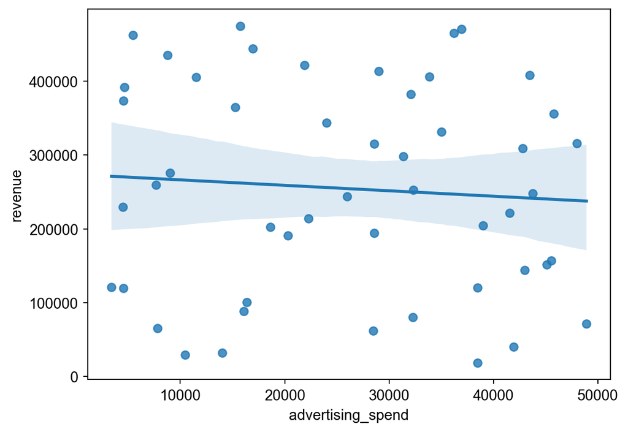

```python
df = pd.DataFrame({
    'advertising_spend': np.random.uniform(1000, 50000, 50),
    'revenue': np.random.uniform(10000, 500000, 50)
})
sns.regplot(data=df, x='advertising_spend', y='revenue')
plt.show()
```

**Output:**

*[Regression scatter plot: x: advertising_spend, y: revenue]*

Seaborn handles all statistical calculations and styling automatically.

**When to Use Each Library:**

**Use Matplotlib when:**

- You need pixel-perfect custom control
- Creating novel visualization types
- Building interactive visualizations
- Working on specialized scientific plots

**Use Seaborn when:**

- Exploring data statistically
- Creating standard business analytics plots
- Need beautiful visualizations quickly
- Working with categorical and continuous data together
- Presenting to non-technical stakeholders

**Important Understanding:** Seaborn is built on top of Matplotlib, not a replacement. You’ll often use both together - Seaborn for the plot structure, Matplotlib for fine-tuning.

**Installing and Importing Seaborn**

**Installation:**

Seaborn should already be installed from Module 1, but if needed:

```
pip install seaborn
```

**Standard Import Convention:**

```python
import seaborn as sns
import matplotlib.pyplot as plt
import pandas as pd
```

The alias `sns` is universally used (named after Samuel Norman Seaborn, a character from “The West Wing” TV show).

**Version Check:**

```python
import seaborn as sns
print(sns.__version__)  # Should be 0.12 or higher
```

```
0.13.2
```

**Output:**

**Seaborn’s Theme and Style System**

**The Aesthetic Advantage:**

One of Seaborn’s most appreciated features is its built-in aesthetic system. With one line, you can transform your visualizations from basic to professional.

**Setting Overall Style:**

Seaborn provides five preset themes:

```python
import seaborn as sns
import matplotlib.pyplot as plt

# Available styles:
sns.set_style("darkgrid")   # Dark background with grid (default)
sns.set_style("whitegrid")  # White background with grid
sns.set_style("dark")       # Dark background, no grid
sns.set_style("white")      # White background, no grid
sns.set_style("ticks")      # White background with tick marks
```

**Output:**

**Style Characteristics:**

- **darkgrid**: Best for presentations, easy to read values
- **whitegrid**: Professional reports, clean appearance
- **white**: Minimal, modern, emphasizes data
- **ticks**: Traditional academic/scientific look
- **dark**: Bold, modern, good for screens

**Understanding Context:**

Seaborn also provides context settings that scale all elements appropriately for different uses:

```python
# Contexts scale font sizes and element sizes
sns.set_context("paper")     # Smallest, for journal papers
sns.set_context("notebook")  # Default, good for screen viewing
sns.set_context("talk")      # Larger, for presentations
sns.set_context("poster")    # Largest, for posters/large displays
```

**Output:**

**Business Context Usage:**

- **Notebook**: Daily analysis, sharing via email
- **Talk**: PowerPoint presentations, board meetings
- **Poster**: Trade shows, lobby displays, large screens

**Color Palettes:**

Seaborn provides sophisticated color palettes designed by professionals:

```python
# Set color palette
sns.set_palette("deep")      # Deep, saturated colors (default)
sns.set_palette("muted")     # Softer, muted colors (professional)
sns.set_palette("bright")    # Bright, vibrant colors
sns.set_palette("pastel")    # Pastel colors (subtle)
sns.set_palette("dark")      # Dark colors
sns.set_palette("colorblind") # Colorblind-safe palette (recommended!)
```

**Output:**

**Professional Setup for Business:**

```python
import seaborn as sns
import matplotlib.pyplot as plt

# Configure for business presentations
sns.set_theme(style="whitegrid",      # Clean, professional
              context="talk",          # Large enough for presentations
              palette="colorblind")    # Accessible to all
```

**Output:**

This single setup ensures all subsequent Seaborn plots have a professional, accessible appearance.

**Understanding Seaborn’s Two Interfaces**

**A Critical Concept:**

Seaborn has two types of functions, and understanding the difference is essential:

**1. Figure-level functions (newer, recommended):**

- Create entire figures with built-in structure
- Names end with “plot”: `relplot()`, `displot()`, `catplot()`
- Return FacetGrid objects
- Better for complex, multi-panel visualizations
- Automatic legend and label management

**2. Axes-level functions (older, more control):**

- Create plots on existing axes
- Direct names: `histplot()`, `boxplot()`, `scatterplot()`
- Return matplotlib axes objects
- Better for integration with existing figures
- More matplotlib-like control

**Practical Example:**

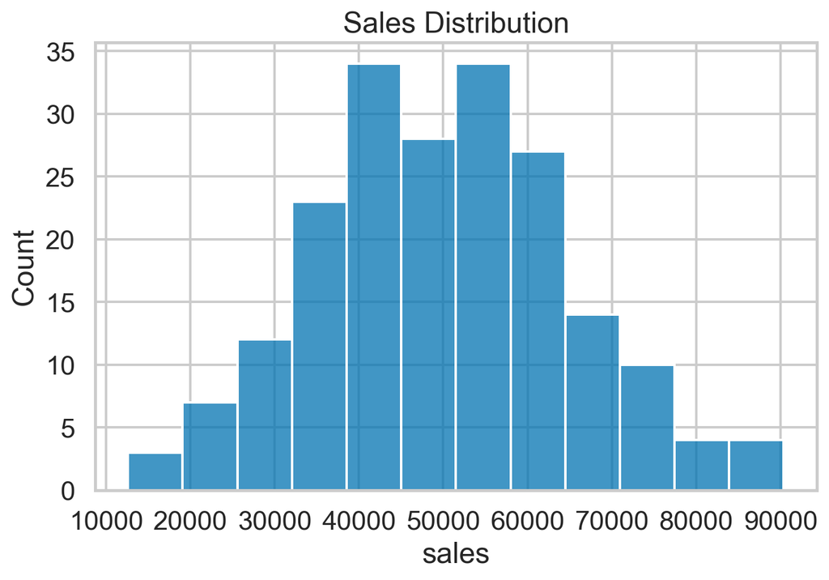

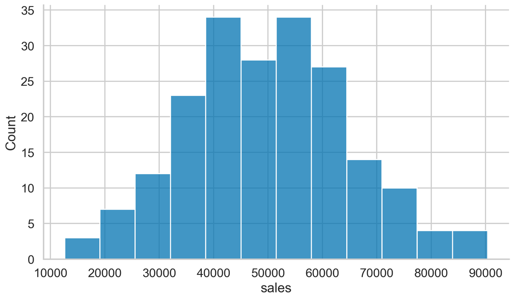

```python
df = pd.DataFrame({'sales': np.random.normal(50000, 15000, 200)})

# Axes-level: You control the figure
fig, ax = plt.subplots(figsize=(8, 5))
sns.histplot(data=df, x='sales', ax=ax)
ax.set_title('Sales Distribution')
plt.show()

# Figure-level: Seaborn controls the figure
sns.displot(data=df, x='sales', height=6, aspect=1.67)
plt.show()
```

**Output:**

*[Distribution plot: “Sales Distribution”, x: sales]*

**Which to Use?**

- **Learning**: Start with axes-level (more familiar if you know Matplotlib)
- **Quick exploration**: Figure-level (less code)
- **Custom layouts**: Axes-level (more control)
- **Multi-panel**: Figure-level (automatic faceting)

**Histograms - Understanding Data Distribution**

**Why Histograms Matter in Business:**

Before making decisions based on averages, you must understand the distribution:

- Are most customers spending around the average, or are there two distinct groups?
- Is revenue normally distributed, or heavily skewed by a few big deals?
- Are there outliers affecting our analysis?

Histograms answer these questions visually by showing:

- **Shape**: Normal, skewed, bimodal?
- **Center**: Where is the typical value?
- **Spread**: How variable is the data?
- **Outliers**: Any extreme values?

**Creating a Histogram with Seaborn:**

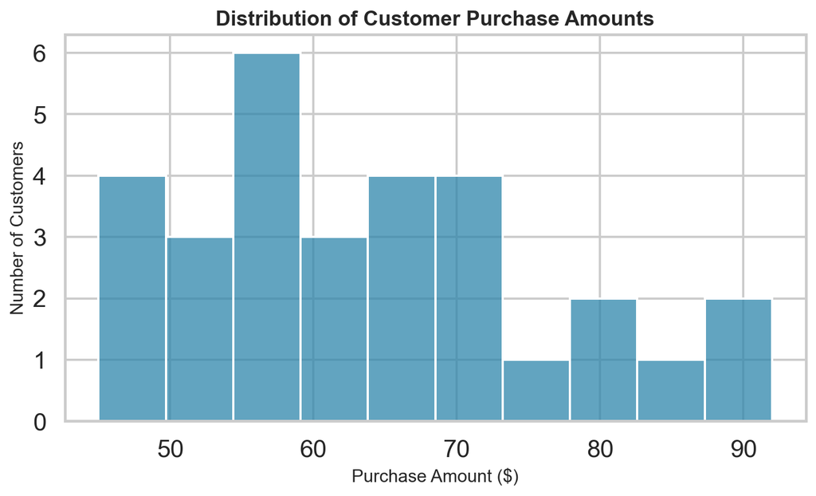

```python
import seaborn as sns
import matplotlib.pyplot as plt
import pandas as pd

# Sample data: Customer purchase amounts
data = {
    'purchase_amount': [45, 52, 48, 61, 58, 63, 55, 72, 68, 51,
                        88, 45, 59, 67, 73, 49, 56, 78, 82, 65,
                        92, 54, 61, 75, 69, 57, 64, 71, 85, 58]
}
df = pd.DataFrame(data)

# Create histogram
fig, ax = plt.subplots(figsize=(8, 5))
sns.histplot(data=df, x='purchase_amount', bins=10,
             kde=False, color='#2E86AB', ax=ax)

ax.set_title('Distribution of Customer Purchase Amounts',
             fontsize=14, fontweight='bold')
ax.set_xlabel('Purchase Amount ($)', fontsize=12)
ax.set_ylabel('Number of Customers', fontsize=12)

plt.tight_layout()
plt.show()
```

**Output:**

*[Distribution plot: “Distribution of Customer Purchase Amounts”, x: Purchase Amount ($), y: Number of Customers]*

**Understanding Histogram Parameters:**

- **bins**: Number of bars (groups). Too few = oversimplified, too many = noisy
  - Rule of thumb: √n (square root of number of observations)
  - For 30 observations: ~5-6 bins; for 100: ~10 bins; for 1000: ~30 bins
- **kde**: Kernel Density Estimate - smooth curve showing distribution
  - `kde=True` adds a smooth line over the bars
  - Helps visualize the overall shape
- **color**: Single color for the bars

**Reading the Story:**

Looking at a histogram, ask:

1. **Shape**: Is it symmetric (normal) or skewed (one tail longer)?
2. **Peaks**: One peak (unimodal) or multiple peaks (bimodal)?
3. **Outliers**: Any bars far from the main cluster?
4. **Range**: What’s the spread from minimum to maximum?

**Business Interpretation Example:**

A histogram of customer purchase amounts showing:

- **Right-skewed**: Most customers spend $40-60, but a few big spenders reach $150+
- **Business insight**: Can’t rely on average alone; need strategies for both typical customers and high-value customers

**KDE Plots - Smooth Distribution Curves**

**Beyond Histogram Bars:**

Kernel Density Estimation (KDE) creates a smooth curve representing the data distribution. Think of it as a smoothed histogram that’s easier to compare across groups.

**Advantages of KDE:**

- Smooth, professional appearance
- Easier to overlay multiple distributions
- Shows shape clearly without bar edge artifacts
- Better for presentations (less “technical” looking)

**Creating a KDE Plot:**

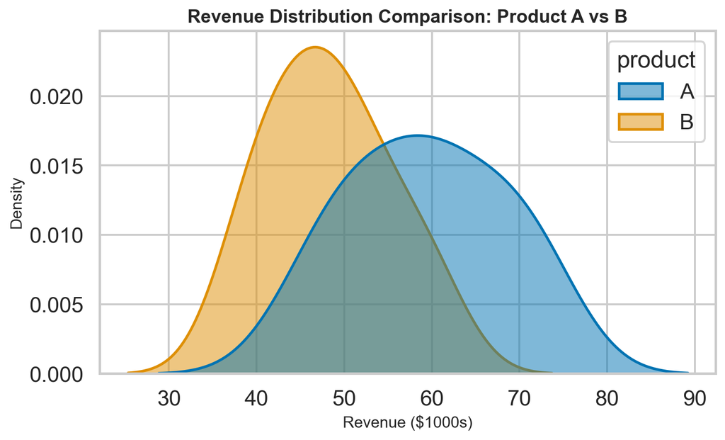

```python
import seaborn as sns
import matplotlib.pyplot as plt

# Revenue data for two product lines
product_a_revenue = [45, 52, 48, 61, 58, 63, 55, 72, 68, 51, 59, 67, 73]
product_b_revenue = [38, 42, 45, 39, 51, 48, 43, 55, 52, 46, 49, 58, 61]

df = pd.DataFrame({
    'revenue': product_a_revenue + product_b_revenue,
    'product': ['A']*len(product_a_revenue) + ['B']*len(product_b_revenue)
})

fig, ax = plt.subplots(figsize=(8, 5))

# KDE plots for both products
sns.kdeplot(data=df, x='revenue', hue='product',
            fill=True, alpha=0.5, linewidth=2, ax=ax)

ax.set_title('Revenue Distribution Comparison: Product A vs B',
             fontsize=14, fontweight='bold')
ax.set_xlabel('Revenue ($1000s)', fontsize=12)
ax.set_ylabel('Density', fontsize=12)

plt.tight_layout()
plt.show()
```

**Output:**

*[Distribution plot: “Revenue Distribution Comparison: Product A vs B”, x: Revenue ($1000s), y: Density]*

**KDE Parameters Explained:**

- **hue**: Variable to separate by color (creates multiple curves)
- **fill**: Fill the area under the curve (True/False)
- **alpha**: Transparency (important when overlapping)
- **linewidth**: Thickness of the outline

**Interpreting KDE Plots:**

The Y-axis shows “density” - not counts, but relative concentration:

- **Higher peaks**: More observations in this range
- **Wider spread**: More variability
- **Multiple peaks**: Distinct subgroups

**Business Use Case:**

Comparing customer lifetime value distributions across regions:

- West Coast: Narrow, high peak around $500 = consistent customers
- East Coast: Wide, low peak = highly variable customer value
- **Insight**: West Coast needs retention strategy, East Coast needs segmentation

**Box Plots - The Statistical Summary**

**The Five-Number Summary:**

Box plots (also called box-and-whisker plots) compress a distribution into five key statistics:

1. **Minimum**: Lowest value (excluding outliers)
2. **Q1 (First Quartile)**: 25% of data is below this
3. **Median (Q2)**: Middle value (50% below, 50% above)
4. **Q3 (Third Quartile)**: 75% of data is below this
5. **Maximum**: Highest value (excluding outliers)
6. **Outliers**: Points beyond whiskers (shown as individual dots)

**Why Box Plots Matter:**

In business, you often need to compare distributions across categories:

- Sales performance across regions
- Salaries across departments
- Product ratings across age groups

Box plots excel at this by showing multiple distributions side-by-side compactly.

**Anatomy of a Box Plot:**

```
    Outlier •

    --------  Maximum (within 1.5×IQR of Q3)
    ┌───┐
    │   │     Q3 (75th percentile)
    │---│     Median (50th percentile)  ← Line inside box
    │   │     Q1 (25th percentile)
    └───┘
    --------  Minimum (within 1.5×IQR of Q1)

    Outlier •
```

**Creating Box Plots:**

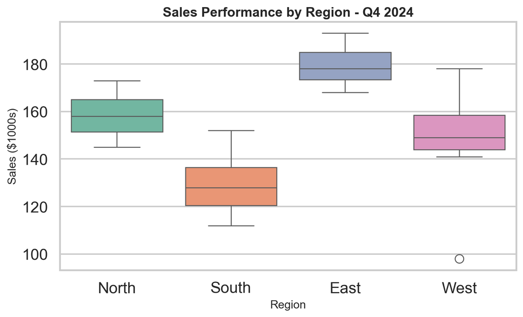

```python
import seaborn as sns
import matplotlib.pyplot as plt
import pandas as pd

# Salesperson performance across regions
data = {
    'region': ['North']*15 + ['South']*15 + ['East']*15 + ['West']*15,
    'sales': [
        # North: generally higher, consistent
        145, 152, 148, 161, 158, 163, 155, 172, 168, 151, 159, 167, 173, 149, 156,
        # South: lower, more variable
        112, 128, 115, 135, 122, 138, 125, 148, 132, 119, 127, 141, 152, 118, 129,
        # East: highest performance
        168, 175, 172, 181, 178, 183, 175, 192, 188, 171, 179, 187, 193, 169, 176,
        # West: mixed, with outliers
        141, 145, 98, 162, 148, 155, 143, 178, 152, 146, 149, 165, 172, 142, 151
    ]
}
df = pd.DataFrame(data)

fig, ax = plt.subplots(figsize=(8, 5))

sns.boxplot(data=df, x='region', y='sales',
            palette='Set2', ax=ax)

ax.set_title('Sales Performance by Region - Q4 2024',
             fontsize=14, fontweight='bold')
ax.set_xlabel('Region', fontsize=12)
ax.set_ylabel('Sales ($1000s)', fontsize=12)

plt.tight_layout()
plt.show()
```

**Output:**

*[Box plot: “Sales Performance by Region - Q4 2024”, x: Region, y: Sales ($1000s)]*

**Reading Box Plots for Business Insights:**

**1. Compare Medians (center lines):**

- East region has highest median → top performer overall

**2. Compare Box Heights (IQR - interquartile range):**

- North has small box → consistent performance
- South has tall box → high variability (some stars, some struggles)

**3. Identify Outliers (dots beyond whiskers):**

- West has low outlier → investigate underperforming salesperson
- Outliers may indicate data errors or special cases

**4. Compare Whisker Ranges:**

- Overall spread shows best-case and worst-case scenarios

**Business Application:**

A CFO looking at departmental budget variance box plots:

- **Finance department**: Small box, no outliers = predictable, well-controlled
- **Marketing department**: Large box, several outliers = needs budget management attention
- **Action**: Implement stricter controls in Marketing, use Finance as best practice model

### 3.1.3 Lab Session

**Lab 1: Statistical Visualization Fundamentals**

**Objective:** Master Seaborn’s foundational capabilities by creating professional statistical visualizations that reveal data distributions and enable comparisons.

**Scenario:** You’re the Analytics Manager at “HealthyLife Fitness,” a gym chain with 500+ members. The executive team is reviewing Q4 performance and needs statistical visualizations to understand member behavior, revenue patterns, and facility usage. Your task is to create a comprehensive statistical analysis report.

**Pre-Lab Setup:**

1. Create file: `S1234567_YourName_StatPlots.py`
2. Import libraries:

```python
import seaborn as sns
import matplotlib.pyplot as plt
import pandas as pd
import numpy as np
```

3. Set Seaborn theme at the top of your file:

```python
sns.set_theme(style="whitegrid", context="talk", palette="colorblind")
```

4. Create output folder: “Lab1_Outputs”

**Part A: Member Age Distribution Analysis (25 points)**

**Context:** The marketing team wants to understand the age demographics of your membership to target advertising effectively.

**Data:**

```python
# Generate realistic age distribution (you'll learn to load real data later)
np.random.seed(42)
member_ages = np.concatenate([
    np.random.normal(28, 5, 150),   # Young professionals
    np.random.normal(45, 8, 200),   # Middle-aged
    np.random.normal(65, 6, 100),   # Seniors
    np.random.uniform(18, 75, 50)   # Random others
])
member_ages = member_ages[(member_ages >= 18) & (member_ages <= 80)]

df_ages = pd.DataFrame({'age': member_ages})
```

**Tasks:**

1. **Create a histogram with KDE overlay (15 points):**
   - Figure size: (12, 6)
   - Use `sns.histplot()` with `kde=True`
   - Use 20 bins
   - Color: professional choice (avoid default blue)
   - Add edge color to bars (black, linewidth=1)
   - Title: “HealthyLife Fitness - Member Age Distribution”
   - X-axis label: “Age (years)”
   - Y-axis label: “Number of Members”
2. **Interpret the distribution (10 points):**
   - In code comments, answer:
     - How many distinct age groups (peaks) do you see?
     - What’s the approximate age range with most members?
     - Are there any gaps or unusual patterns?
     - What does this mean for marketing strategy?
   - Add a vertical line at the median age using: `ax.axvline(df_ages['age'].median(), color='red', linestyle='--', linewidth=2, label='Median Age')`
   - Include legend
3. **Save the visualization:**
   - Filename: `S1234567_YourName_AgeDistribution.png`
   - High resolution (dpi=300)

**Part B: Revenue Distribution Comparison (30 points)**

**Context:** The finance director needs to compare monthly revenue distributions across different membership tiers (Basic, Premium, Elite) to assess pricing strategy effectiveness.

**Data:**

```python
np.random.seed(42)
basic_revenue = np.random.normal(450, 75, 180)      # Basic: $450 avg
premium_revenue = np.random.normal(850, 120, 150)   # Premium: $850 avg
elite_revenue = np.random.normal(1500, 200, 70)     # Elite: $1500 avg

df_revenue = pd.DataFrame({
    'monthly_revenue': np.concatenate([basic_revenue, premium_revenue, elite_revenue]),
    'tier': ['Basic']*180 + ['Premium']*150 + ['Elite']*70
})
```

**Tasks:**

1. **Create overlapping KDE plots (15 points):**
   - Figure size: (12, 7)
   - Use `sns.kdeplot()` with:
     - `x='monthly_revenue'`
     - `hue='tier'`
     - `fill=True`
     - `alpha=0.5`
     - `linewidth=2.5`
   - Title: “Monthly Revenue Distribution by Membership Tier”
   - X-axis label: “Monthly Revenue per Member ($)”
   - Y-axis label: “Density”
   - Ensure legend is visible and well-positioned
2. **Add reference lines (10 points):**
   - Calculate and add vertical lines for mean revenue of each tier
   - Use different line styles for each tier
   - Add text labels showing the exact mean values
   - Hint: Use `df_revenue.groupby('tier')['monthly_revenue'].mean()`
3. **Business interpretation (5 points):**
   - In comments, answer:
     - Which tier has the most consistent (least variable) revenue?
     - Is there any overlap between tiers?
     - What percentage of Basic members might be good candidates for Premium upgrade?
     - Save as: `S1234567_YourName_RevenueTiers.png`

**Part C: Facility Usage Box Plot Comparison (25 points)**

**Context:** Operations needs to compare average weekly gym visits across different times of day and days of week to optimize staffing.

**Data:**

```python
np.random.seed(42)

# Weekly visits by time of day
morning_visits = np.random.poisson(12, 100)    # Morning: avg 12/week
afternoon_visits = np.random.poisson(8, 100)   # Afternoon: avg 8/week
evening_visits = np.random.poisson(15, 100)    # Evening: avg 15/week (busiest)
night_visits = np.random.poisson(5, 100)       # Night: avg 5/week

df_visits = pd.DataFrame({
    'weekly_visits': np.concatenate([morning_visits, afternoon_visits,
                                     evening_visits, night_visits]),
    'time_period': ['Morning (6-10am)']*100 + ['Afternoon (10am-4pm)']*100 +
                   ['Evening (4-8pm)']*100 + ['Night (8pm-12am)']*100
})
```

**Tasks:**

1. **Create professional box plot (15 points):**
   - Figure size: (12, 7)
   - Use `sns.boxplot()` with:
     - `x='time_period'`
     - `y='weekly_visits'`
     - Choose professional color palette
   - Title: “Member Weekly Visits by Time Period”
   - X-axis label: “Time Period”
   - Y-axis label: “Average Weekly Visits”
   - Rotate X-axis labels if needed for readability
2. **Enhance with statistical information (10 points):**
   - Add horizontal line showing overall median visits across all periods
   - Use distinct color (e.g., red) with dashed style
   - Add label: “Overall Median”
   - Make line width 2
   - Calculate and print (in comments):
     - Which period has highest median?
     - Which period has most variability (tallest box)?
     - Identify any outliers and their values
3. **Save and document:**
   - Save as: `S1234567_YourName_UsageByTime.png`
   - In comments, provide staffing recommendations based on the visualization

**Part D: Multi-Facility Comparison (20 points)**

**Context:** The VP of Operations oversees 5 locations and needs to compare member satisfaction scores across facilities to identify underperforming locations.

**Data:**

```python
np.random.seed(42)

facilities = ['Downtown', 'Suburban North', 'Suburban South', 'University District', 'Business Park']
all_scores = []
all_facilities = []

for facility in facilities:
    if facility == 'University District':
        scores = np.random.normal(4.8, 0.3, 80)  # Highest satisfaction
    elif facility == 'Business Park':
        scores = np.random.normal(3.9, 0.7, 60)  # Lowest, most variable
    else:
        scores = np.random.normal(4.3, 0.5, 70)  # Average

    scores = np.clip(scores, 1, 5)  # Keep between 1-5
    all_scores.extend(scores)
    all_facilities.extend([facility] * len(scores))

df_satisfaction = pd.DataFrame({
    'facility': all_facilities,
    'satisfaction_score': all_scores
})
```

**Tasks:**

1. **Create comparison box plot (12 points):**
   - Figure size: (14, 7)
   - Use horizontal box plot (`orient='h'` or swap x/y)
   - Sort facilities by median satisfaction (highest to lowest)
   - Use color gradient (best = green, worst = red)
   - Title: “Member Satisfaction by Facility Location - Q4 2024”
   - Include axis labels with units
2. **Add performance benchmarks (8 points):**
   - Add vertical line at satisfaction score of 4.5 (corporate target)
   - Add vertical line at satisfaction score of 4.0 (minimum acceptable)
   - Use different colors and label each line
   - Shade the area above 4.5 in light green (excellent zone)
   - Hint: Use `ax.axvspan()` for shading
3. **Save and analyze:**
   - Save as: `S1234567_YourName_FacilitySatisfaction.png`
   - In comments, identify which facilities need immediate attention

**Bonus Challenge (+20 points):**

**Create a Comprehensive Statistical Dashboard:**

Combine all four analyses into a single 2×2 subplot figure:

- Top-left: Age distribution histogram
- Top-right: Revenue KDE comparisons
- Bottom-left: Usage box plots
- Bottom-right: Facility satisfaction box plots

**Additional Requirements:**

- Figure size: (20, 16)
- Consistent styling across all subplots
- Overall figure title: “HealthyLife Fitness - Q4 2024 Statistical Analysis Dashboard”
- Proper spacing (no overlapping elements)
- Each subplot should be readable and professional
- Save as: `S1234567_YourName_Dashboard.png`

**Deliverables:**

1. Python file: `S1234567_YourName_StatPlots.py`
2. Four PNG files (five if bonus attempted):
   - `S1234567_YourName_AgeDistribution.png`
   - `S1234567_YourName_RevenueTiers.png`
   - `S1234567_YourName_UsageByTime.png`
   - `S1234567_YourName_FacilitySatisfaction.png`
   - `S1234567_YourName_Dashboard.png` (bonus)

**Grading Rubric:**

- Part A (Age Distribution): 25 points
- Part B (Revenue Comparison): 30 points
- Part C (Usage Box Plots): 25 points
- Part D (Facility Comparison): 20 points
- Bonus (Dashboard): +20 points

**Success Criteria:**

- Seaborn theme configured at top of file
- All visualizations use appropriate Seaborn functions
- Professional styling and colors applied
- Statistical features (median lines, reference lines) included
- Business interpretations documented in comments
- All plots have clear titles and axis labels
- High-resolution outputs saved
- Code is well-organized with clear sections

**Statistical Interpretation Guide:**

When analyzing distributions, always assess: 1. **Central Tendency**: Where is the typical value? (mean/median) 2. **Spread**: How variable is the data? (range, IQR) 3. **Shape**: Symmetric? Skewed? Multiple peaks? 4. **Outliers**: Any unusual values? Why? 5. **Comparisons**: How do groups differ?

**Common Mistakes to Avoid:**

- Using too many or too few bins in histograms
- Forgetting to set transparency when overlaying KDE plots
- Not explaining outliers in box plots
- Missing labels or units on axes
- Poor color choices (too bright, not colorblind-safe)
- Not leveraging Seaborn’s theme system

**Tips for Success:**

- Start by setting the Seaborn theme globally
- Test each plot individually before combining
- Use meaningful color palettes (not random colors)
- Always include units in axis labels
- Comment your interpretations as you code
- View your saved images to verify quality

## 3.2 Section 2: Distribution and Relationship Visualizations

### 3.2.1 Objective

- Create and interpret joint plots showing relationships between two variables
- Master pair plots for multivariate exploratory analysis
- Use regression plots to visualize linear relationships
- Apply residual plots to assess model fit quality
- Understand the statistical interpretation of relationship visualizations
- Leverage these tools for business predictive analytics

### 3.2.2 Main Contents with Examples

**Beyond Single Variables - Exploring Relationships**

**The Business Reality:**

Most business questions involve relationships between variables:

- Does advertising spend correlate with revenue?
- Do experienced employees have higher satisfaction scores?
- Is there a relationship between product price and sales volume?
- Do customer age and purchase frequency correlate?

Single-variable distributions (histograms, box plots) don’t answer these questions. We need **bivariate visualizations** that show two variables simultaneously.

**Types of Relationships to Explore:**

**1. Positive Correlation:**

- As X increases, Y increases
- Example: Years of experience → Salary
- Business implication: Investing in X may improve Y

**2. Negative Correlation:**

- As X increases, Y decreases
- Example: Product price → Sales volume
- Business implication: Trade-off between X and Y

**3. No Correlation:**

- X and Y move independently
- Example: Employee shoe size → Sales performance
- Business implication: X won’t help predict Y

**4. Non-linear Relationship:**

- Relationship exists but isn’t a straight line
- Example: Advertising spend → Revenue (diminishing returns)
- Business implication: Complex relationship requires different models

**Scatter Plots with Regression Lines**

**The Foundation of Relationship Analysis:**

We introduced scatter plots in Module 2, but Seaborn enhances them significantly by adding statistical elements automatically.

**Seaborn’s regplot() - Scatter + Regression:**

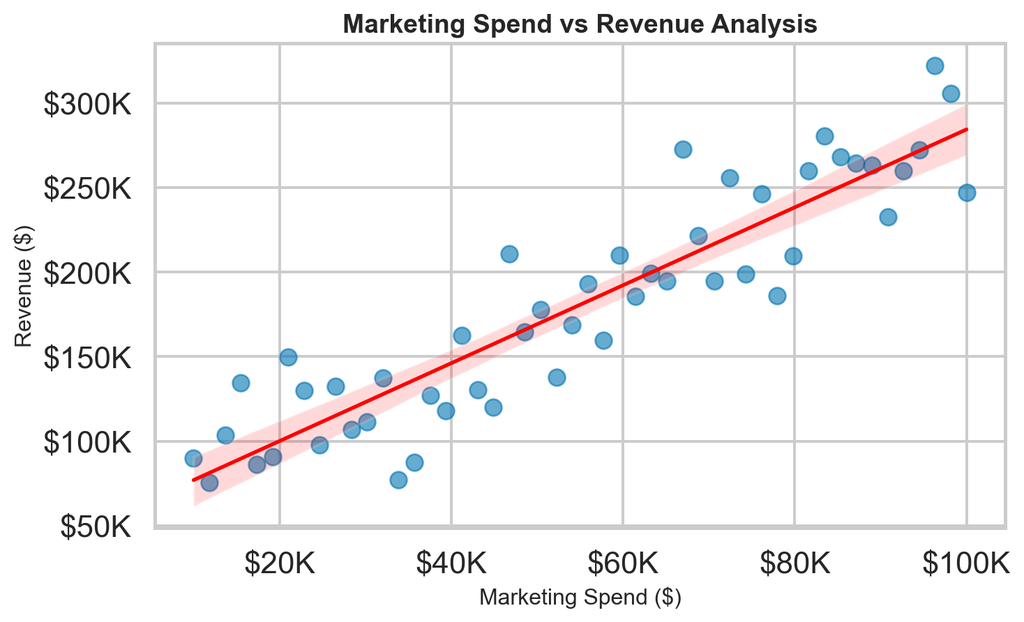

```python
import seaborn as sns
import matplotlib.pyplot as plt
import pandas as pd
import numpy as np

# Sample data: Marketing spend vs Revenue
np.random.seed(42)
marketing_spend = np.linspace(10000, 100000, 50)
revenue = 50000 + 2.5 * marketing_spend + np.random.normal(0, 30000, 50)

df = pd.DataFrame({
    'marketing_spend': marketing_spend,
    'revenue': revenue
})

fig, ax = plt.subplots(figsize=(8, 5))

# Create scatter plot with regression line
sns.regplot(data=df, x='marketing_spend', y='revenue',
            scatter_kws={'alpha': 0.6, 's': 80},
            line_kws={'color': 'red', 'linewidth': 2},
            ax=ax)

ax.set_title('Marketing Spend vs Revenue Analysis',
             fontsize=14, fontweight='bold')
ax.set_xlabel('Marketing Spend ($)', fontsize=12)
ax.set_ylabel('Revenue ($)', fontsize=12)

# Format axes
ax.xaxis.set_major_formatter(plt.FuncFormatter(lambda x, p: f'${x/1000:.0f}K'))
ax.yaxis.set_major_formatter(plt.FuncFormatter(lambda x, p: f'${x/1000:.0f}K'))

plt.tight_layout()
plt.show()
```

**Output:**

*[Regression scatter plot: “Marketing Spend vs Revenue Analysis”, x: Marketing Spend ($), y: Revenue ($)]*

**What regplot() Provides Automatically:**

1. **Scatter points**: Shows actual data points
2. **Regression line**: Best-fit straight line through the data
3. **Confidence interval**: Shaded area around the line (95% confidence by default)

**Understanding the Confidence Interval:**

The shaded area represents uncertainty in our estimate:

- **Narrow band**: High confidence, strong relationship, lots of data
- **Wide band**: Less confidence, weaker relationship, or less data
- **Interpretation**: “We’re 95% confident the true relationship falls within this band”

**Business Application:**

Looking at the marketing spend plot:

- **Positive slope**: More marketing spend → More revenue (good!)
- **Confidence interval**: Gets wider at extremes (less data at very high/low spend)
- **Scatter around line**: Some variation, but overall strong pattern
- **Decision support**: Provides evidence that marketing investment correlates with revenue growth

**Joint Plots - Combining Multiple Perspectives**

**The Multi-View Approach:**

Joint plots are one of Seaborn’s most powerful features, combining three visualizations in one figure:

- **Center**: Scatter plot showing relationship
- **Top**: Histogram of X variable
- **Right**: Histogram of Y variable

This provides comprehensive understanding:

- See the relationship (center)
- See X distribution (top)
- See Y distribution (right)

**Creating a Joint Plot:**

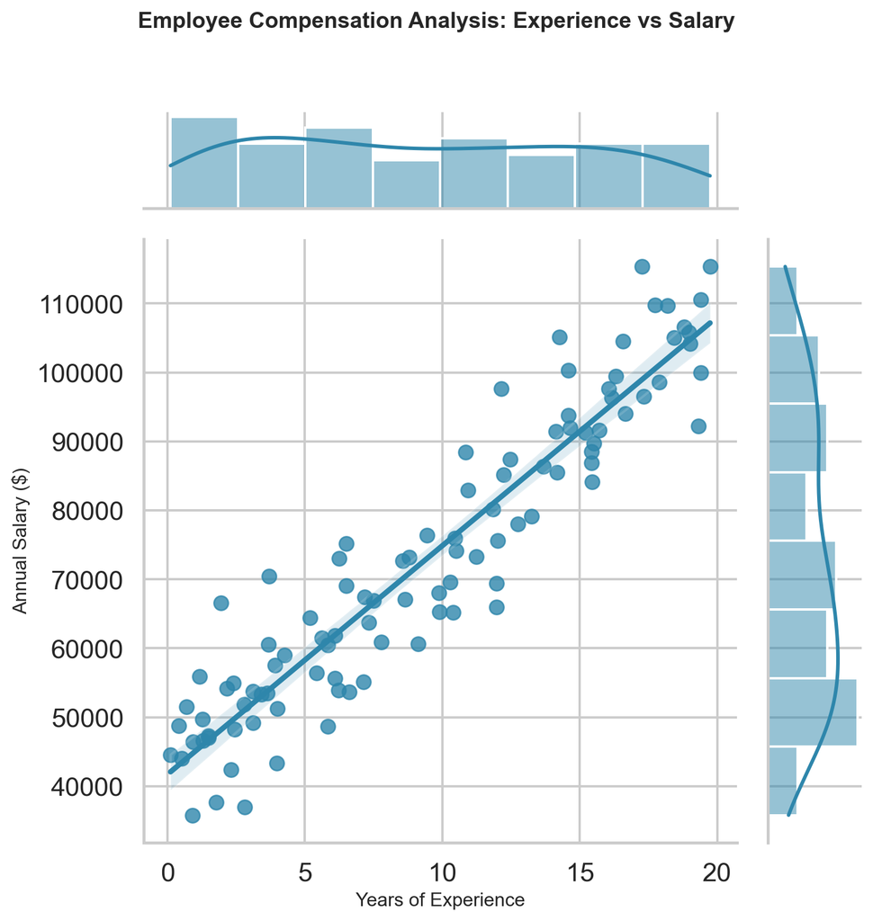

```python
import seaborn as sns
import matplotlib.pyplot as plt
import pandas as pd
import numpy as np

# Employee data: Years of experience vs Salary
np.random.seed(42)
experience = np.random.uniform(0, 20, 100)
salary = 40000 + 3500 * experience + np.random.normal(0, 8000, 100)

df = pd.DataFrame({
    'years_experience': experience,
    'salary': salary
})

# Create joint plot
g = sns.jointplot(data=df, x='years_experience', y='salary',
                  kind='reg',  # Includes regression line
                  height=8,
                  color='#2E86AB')

# Customize
g.fig.suptitle('Employee Compensation Analysis: Experience vs Salary',
               fontsize=14, fontweight='bold', y=1.02)
g.set_axis_labels('Years of Experience', 'Annual Salary ($)', fontsize=12)

plt.tight_layout()
plt.show()
```

**Output:**

*[Joint plot: “Employee Compensation Analysis: Experience vs Salary”, x: years_experience, y: salary]*

**Joint Plot “kind” Options:**

Seaborn offers several relationship types:

**1. kind=‘scatter’** (default)

- Basic scatter plot
- Best for initial exploration

**2. kind=‘reg’**

- Adds regression line
- Best when you suspect linear relationship

**3. kind=‘kde’**

- Contour plot showing density
- Best for large datasets where points overlap
- Shows concentration of data

**4. kind=‘hex’**

- Hexagonal binning
- Best for very large datasets (1000+ points)
- Shows density through color

**Reading a Joint Plot:**

**Top histogram:**

- Shows distribution of experience
- Check: Are employees evenly distributed across experience levels?

**Right histogram:**

- Shows distribution of salaries
- Check: Is salary distribution normal or skewed?

**Center scatter:**

- Shows relationship
- Check: Linear? Non-linear? Outliers?

**Business Insights Example:**

**Pair Plots - Multivariate Exploration**

**The “Look at Everything” Tool:**

In business, you often have many variables and don’t know which relationships matter. Pair plots solve this by creating a matrix of visualizations showing all possible pairs.

**Example Scenario:**

You have data on:

- Customer age
- Income
- Years as customer
- Average purchase amount
- Satisfaction score

Which variables correlate? Pair plots show all relationships at once.

**Creating a Pair Plot:**

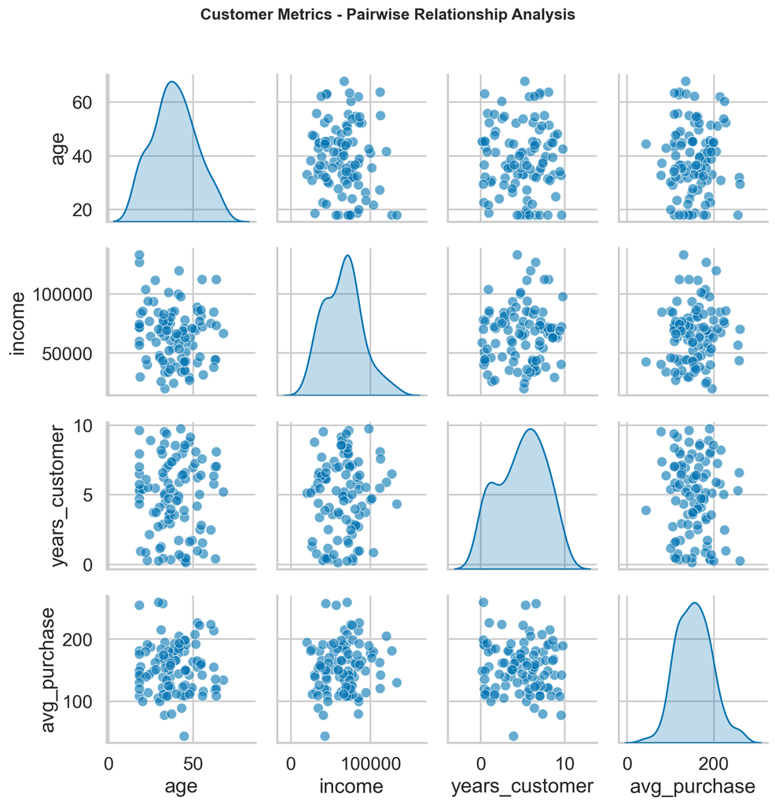

```python
import seaborn as sns
import matplotlib.pyplot as plt
import pandas as pd
import numpy as np

# Sample customer data
np.random.seed(42)
n = 100

df_customers = pd.DataFrame({
    'age': np.random.normal(40, 15, n),
    'income': np.random.normal(65000, 25000, n),
    'years_customer': np.random.uniform(0, 10, n),
    'avg_purchase': np.random.normal(150, 50, n)
})

# Ensure reasonable values
df_customers['age'] = df_customers['age'].clip(18, 80)
df_customers['income'] = df_customers['income'].clip(20000, 200000)
df_customers['avg_purchase'] = df_customers['avg_purchase'].clip(20, 500)

# Create pair plot
g = sns.pairplot(df_customers,
                 diag_kind='kde',  # Distribution on diagonal
                 plot_kws={'alpha': 0.6},
                 height=2.5)

g.fig.suptitle('Customer Metrics - Pairwise Relationship Analysis',
               fontsize=14, fontweight='bold', y=1.01)

plt.tight_layout()
plt.show()
```

**Output:**

*[Pair plot: “Customer Metrics - Pairwise Relationship Analysis”]*

**Understanding the Pair Plot Grid:**

**Diagonal (top-left to bottom-right):**

- Shows distribution of each variable (KDE or histogram)
- Check: Is each variable normally distributed? Skewed?

**Off-diagonal:**

- Each cell is a scatter plot
- Row variable on Y-axis, column variable on X-axis
- Example: Row 2, Column 1 = Income (Y) vs Age (X)

**Reading Strategy:**

1. **Scan diagonals**: Understand each variable’s distribution
2. **Look for patterns**: Strong linear relationships show clear diagonal patterns
3. **Identify weak relationships**: Random clouds indicate no correlation
4. **Spot outliers**: Points far from main clusters

**Business Application - Customer Segmentation:**

**Adding Categories with Hue:**

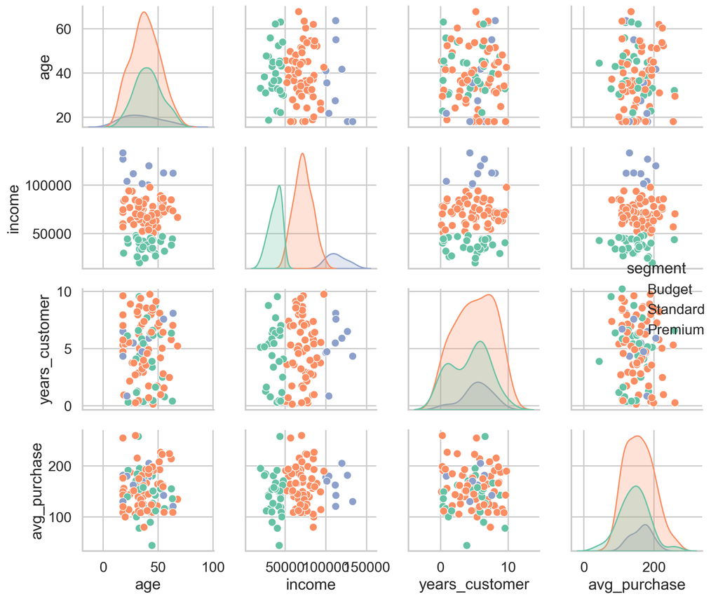

```python
# Add customer segment
df_customers['segment'] = pd.cut(df_customers['income'],
                                  bins=[0, 50000, 100000, 300000],
                                  labels=['Budget', 'Standard', 'Premium'])

# Pair plot with segments colored
g = sns.pairplot(df_customers,
                 hue='segment',  # Color by segment
                 palette='Set2',
                 diag_kind='kde',
                 height=2.5)

plt.tight_layout()
plt.show()
```

**Output:**

*[Pair plot]*

Now each scatter plot shows three colors (Budget, Standard, Premium), revealing:

- Do segments have different age distributions?
- Do purchase behaviors differ by segment?
- Are segments well-separated or overlapping?

**Residual Plots - Assessing Model Quality**

**Beyond the Line - How Good is the Fit?**

A regression line looks nice, but how well does it actually fit the data? Residual plots answer this question.

**What are Residuals?**

Residuals are the differences between actual values and predicted values:

- **Residual = Actual Y - Predicted Y**
- Positive residual: Point is above the line
- Negative residual: Point is below the line

**Why Residuals Matter:**

A good linear regression should have residuals that: 1. **Randomly scattered**: No pattern around zero 2. **Constant spread**: Same variance throughout 3. **Normally distributed**: Roughly bell-shaped

If residuals show patterns, the linear model may be inappropriate.

**Creating a Residual Plot:**

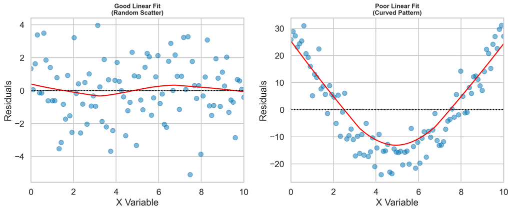

```python
import seaborn as sns
import matplotlib.pyplot as plt
import numpy as np
import pandas as pd

# Create data with different patterns
np.random.seed(42)

# Good linear fit
x_good = np.linspace(0, 10, 100)
y_good = 2 * x_good + 5 + np.random.normal(0, 2, 100)

# Non-linear pattern (quadratic)
x_bad = np.linspace(0, 10, 100)
y_bad = 2 * x_bad**2 + np.random.normal(0, 5, 100)

fig, axes = plt.subplots(1, 2, figsize=(14, 6))

# Good fit residual plot
sns.residplot(x=x_good, y=y_good,
              lowess=True,
              scatter_kws={'alpha': 0.5},
              line_kws={'color': 'red', 'linewidth': 2},
              ax=axes[0])
axes[0].set_title('Good Linear Fit\n(Random Scatter)',
                  fontsize=12, fontweight='bold')
axes[0].set_xlabel('X Variable')
axes[0].set_ylabel('Residuals')
axes[0].axhline(0, color='black', linestyle='--', linewidth=1)

# Poor fit residual plot
sns.residplot(x=x_bad, y=y_bad,
              lowess=True,
              scatter_kws={'alpha': 0.5},
              line_kws={'color': 'red', 'linewidth': 2},
              ax=axes[1])
axes[1].set_title('Poor Linear Fit\n(Curved Pattern)',
                  fontsize=12, fontweight='bold')
axes[1].set_xlabel('X Variable')
axes[1].set_ylabel('Residuals')
axes[1].axhline(0, color='black', linestyle='--', linewidth=1)

plt.tight_layout()
plt.show()
```

**Output:**

**Interpreting Residual Plots:**

**Good Pattern (Left):**

- Points scattered randomly around zero
- No curved pattern
- Constant spread (homoscedasticity)
- **Conclusion**: Linear model is appropriate

**Bad Pattern (Right):**

- Clear curved pattern (U-shape or inverted U)
- **Conclusion**: Relationship is non-linear, need different model

**Other Warning Signs:**

**Fan shape (heteroscedasticity):**

- Spread increases as X increases
- **Issue**: Predictions less reliable at high X values
- **Solution**: Transform data (log, square root)

**Outliers:**

- Points very far from zero
- **Action**: Investigate these cases (errors? special circumstances?)

**Business Example:**

**Scenario**: Modeling sales based on advertising spend

**Residual plot shows curve:**

- Spending $10K → Over-prediction (residuals negative)
- Spending $50K → Good prediction (residuals near zero)
- Spending $100K → Under-prediction (residuals positive)

**Action**: Use polynomial or log model instead of linear

**Practical Workflow for Relationship Analysis**

**Step-by-Step Business Analysis Process:**

When exploring relationships in business data:

**Step 1: Pair Plot Overview**

- Load your data
- Create pair plot of all numeric variables
- Identify interesting relationships

**Step 2: Deep Dive with Joint Plots**

- For each interesting relationship, create joint plot
- Add regression line (`kind='reg'`)
- Examine strength and direction

**Step 3: Verify with Residual Plot**

- For relationships you want to model
- Create residual plot
- Check if linear model is appropriate

**Step 4: Business Interpretation**

- Translate statistical findings to business language
- Quantify relationships (correlation coefficients)
- Make recommendations

**Complete Example Workflow:**

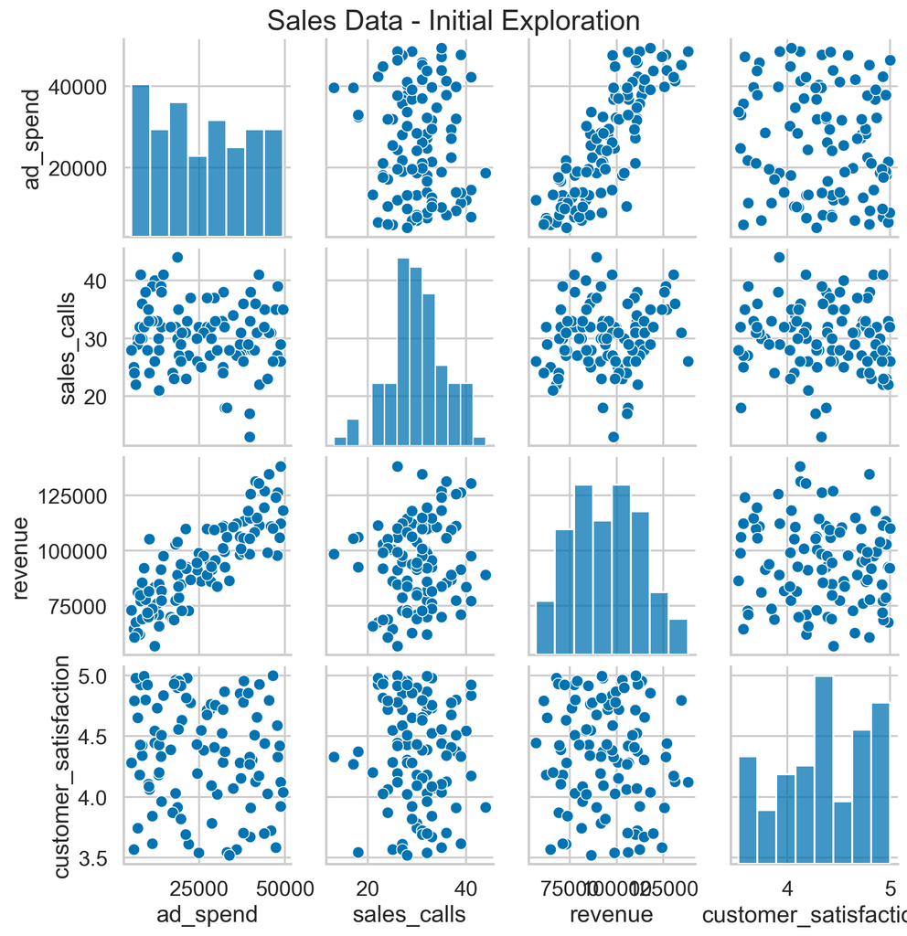

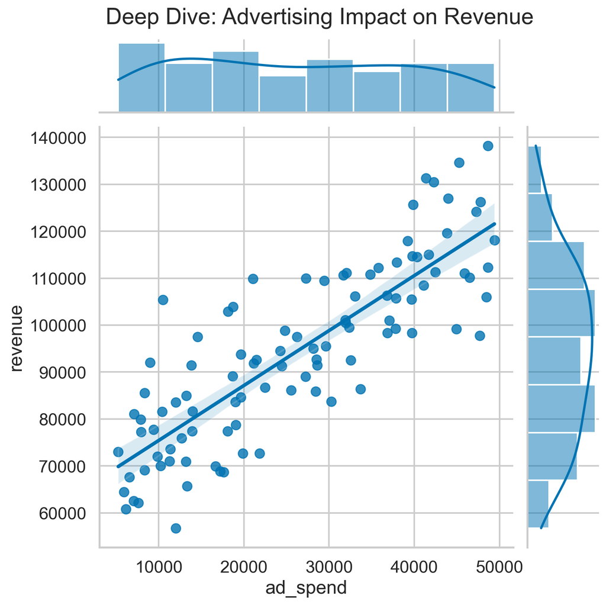

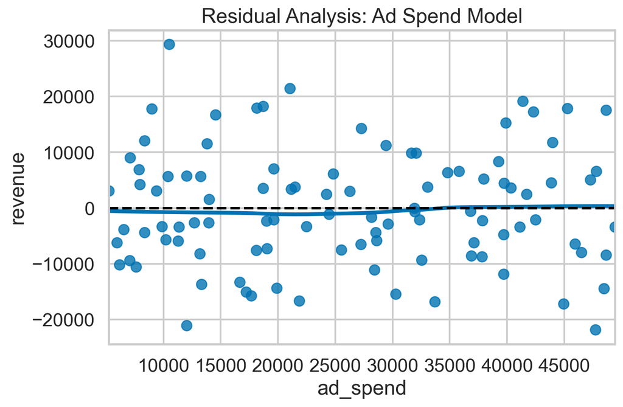

```
Correlation between Ad Spend and Revenue: 0.834
```

```python
import seaborn as sns
import matplotlib.pyplot as plt
import pandas as pd
import numpy as np

# Sample sales data
np.random.seed(42)
df_sales = pd.DataFrame({
    'ad_spend': np.random.uniform(5000, 50000, 100),
    'sales_calls': np.random.poisson(30, 100),
    'revenue': np.random.normal(100000, 30000, 100),
    'customer_satisfaction': np.random.uniform(3.5, 5.0, 100)
})

# Add realistic relationships
df_sales['revenue'] = (50000 +
                       1.2 * df_sales['ad_spend'] +
                       500 * df_sales['sales_calls'] +
                       np.random.normal(0, 10000, 100))

# Step 1: Pair plot overview
sns.pairplot(df_sales)
plt.suptitle('Sales Data - Initial Exploration', y=1.01)
plt.show()

# Step 2: Deep dive - Ad Spend vs Revenue
g = sns.jointplot(data=df_sales, x='ad_spend', y='revenue',
                  kind='reg', height=8)
g.fig.suptitle('Deep Dive: Advertising Impact on Revenue', y=1.02)
plt.show()

# Step 3: Check residuals
fig, ax = plt.subplots(figsize=(8, 5))
sns.residplot(data=df_sales, x='ad_spend', y='revenue',
              lowess=True, ax=ax)
ax.set_title('Residual Analysis: Ad Spend Model')
ax.axhline(0, color='black', linestyle='--')
plt.show()

# Step 4: Quantify (calculate correlation)
correlation = df_sales[['ad_spend', 'revenue']].corr().iloc[0, 1]
print(f"Correlation between Ad Spend and Revenue: {correlation:.3f}")
```

**Output:**

*[Pair plot: “Residual Analysis: Ad Spend Model”, x: ad_spend, y: revenue]*

**Statistical Significance and Business Decisions**

**Understanding Correlation Strength:**

Correlation coefficients range from -1 to +1:

- **0.9 to 1.0**: Very strong positive (rare in business)
- **0.7 to 0.9**: Strong positive
- **0.4 to 0.7**: Moderate positive
- **0.1 to 0.4**: Weak positive
- **0.0**: No linear relationship
- **Negative values**: Same scale, but inverse relationship

**Business Decision Framework:**

**Correlation = 0.85 (Strong):**

- High confidence in relationship
- Can use for predictive models
- Justified to invest resources based on this

**Correlation = 0.35 (Weak):**

- Relationship exists but variable
- Multiple factors influence outcome
- Need additional variables for good predictions
- Be cautious with major decisions

**Remember: Correlation ≠ Causation**

Just because two variables correlate doesn’t mean one causes the other:

- Ice cream sales and drowning deaths correlate (both peak in summer)
- Company revenue and CEO’s golf score might correlate (both improve with company growth)

**Always ask:** Could a third variable explain both?

### 3.2.3 Lab Session

**Lab 2: Relationship and Correlation Analysis**

**Objective:** Master bivariate analysis techniques to uncover, visualize, and interpret relationships between business variables for predictive insights.

**Scenario:** You’re the Business Intelligence Analyst at “TechStart Solutions,” a B2B software company with 200+ customers. The executive team is planning 2025 strategy and needs data-driven insights about what drives customer success, revenue growth, and satisfaction. Your mission is to analyze relationships between key business metrics to guide strategic decisions.

**Pre-Lab Setup:**

1. Create file: `M3L02_YourName_Relationships.py`
2. Import libraries and set theme:

```python
import seaborn as sns
import matplotlib.pyplot as plt
import pandas as pd
import numpy as np

sns.set_theme(style="whitegrid", context="talk", palette="colorblind")
```

3. Create output folder: “Lab2_Outputs”

**Part A: Customer Success Metrics Exploration (30 points)**

**Context:** Your Customer Success VP wants to understand which factors correlate with customer satisfaction to prioritize improvement efforts.

**Data:**

```python
np.random.seed(42)
n_customers = 200

# Generate realistic customer data
df_customers = pd.DataFrame({
    'customer_id': range(1, n_customers + 1),
    'contract_value': np.random.uniform(5000, 100000, n_customers),
    'support_tickets': np.random.poisson(8, n_customers),
    'response_time_hours': np.random.exponential(12, n_customers),
    'features_used': np.random.randint(3, 25, n_customers),
    'satisfaction_score': np.random.uniform(2.5, 5.0, n_customers)
})

# Create realistic relationships
df_customers['satisfaction_score'] = (
    3.0 +
    0.00001 * df_customers['contract_value'] +  # Higher value → slightly higher satisfaction
    -0.08 * df_customers['support_tickets'] +    # More tickets → lower satisfaction
    -0.03 * df_customers['response_time_hours'] + # Slower response → lower satisfaction
    0.04 * df_customers['features_used'] +        # More features → higher satisfaction
    np.random.normal(0, 0.3, n_customers)
)

# Clip to valid range
df_customers['satisfaction_score'] = df_customers['satisfaction_score'].clip(1.0, 5.0)
```

**Tasks:**

1. **Create comprehensive pair plot (15 points):**
   - Include all numeric variables except customer_id
   - Use KDE on diagonal
   - Set appropriate figure height (around 3)
   - Set plot transparency (alpha=0.6)
   - Add overall title: “Customer Success Metrics - Pairwise Correlation Analysis”
   - Ensure the title doesn’t overlap with plots
2. **Identify key relationships (10 points):**
   - Calculate correlation matrix for all numeric variables
   - Print the correlation matrix
   - In code comments, identify:
     - Which variable has the STRONGEST correlation with satisfaction?
     - Which variable has the WEAKEST correlation with satisfaction?
     - Are there any unexpected correlations between other variables?
     - Which metrics should the Customer Success team focus on?
3. **Save and document (5 points):**
   - Save the pair plot as: `M3L02_YourName_CustomerPairplot.png`
   - Create a text file or detailed comments with your findings
   - Include specific correlation values in your analysis

**Part B: Deep Dive - Support Response Time Impact (30 points)**

**Context:** The support team is debating whether faster response times truly impact satisfaction. They need statistical evidence to justify hiring more support staff.

**Tasks:**

1. **Create joint plot analysis (15 points):**
   - Create a joint plot of response_time_hours (x) vs satisfaction_score (y)
   - Use `kind='reg'` to include regression line
   - Set height=9 for better visibility
   - Choose professional color (not default)
   - Title: “Support Response Time Impact on Customer Satisfaction”
   - Properly label axes with units
2. **Analyze the relationship (10 points):**
   - Look at the regression line slope
   - Examine the confidence interval (shaded area)
   - Check the histograms on top and right
   - In comments, answer:
     - Is there a positive or negative correlation?
     - How strong is the relationship?
     - What does the scatter around the line tell us?
     - If we reduce response time by 10 hours, what’s the expected satisfaction impact?
   - Add these insights as comments in your code
3. **Create residual plot (5 points):**
   - Create a residual plot for response_time vs satisfaction
   - Add lowess line (smooth curve)
   - Add horizontal line at y=0
   - Title: “Residual Analysis: Response Time Model”
   - Check if the linear model is appropriate
   - Save both plots:
     - `M3L02_YourName_ResponseTimeJoint.png`
     - `M3L02_YourName_ResponseResiduals.png`

**Part C: Revenue Drivers Analysis (25 points)**

**Context:** The Sales and Marketing teams are arguing about what drives revenue. Marketing says features used (product engagement) matters most. Sales says it’s all about contract value and relationship (support interactions). Settle the debate with data.

**Data preparation:**

```python
# Add revenue data with realistic relationships
df_customers['annual_revenue'] = (
    df_customers['contract_value'] * 1.2 +  # Base revenue from contract
    500 * df_customers['features_used'] +    # Upsell from feature usage
    -1000 * df_customers['support_tickets'] + # Cost of support
    np.random.normal(0, 5000, n_customers)
)

df_customers['annual_revenue'] = df_customers['annual_revenue'].clip(0, None)
```

**Tasks:**

1. **Create three regression plots (18 points):**
   - Create a figure with 1 row, 3 columns (figsize=(18, 6))
   - Plot 1: contract_value vs annual_revenue
   - Plot 2: features_used vs annual_revenue
   - Plot 3: support_tickets vs annual_revenue
   - Each with regression line and confidence interval
   - Consistent styling across all three
   - Professional color choices
   - All with proper titles and labels
2. **Comparative analysis (7 points):**
   - Calculate correlation coefficient for each relationship
   - Print all three correlations
   - In comments, answer:
     - Which variable has the strongest correlation with revenue?
     - Is the support_tickets correlation positive or negative? Why?
     - Who wins the debate - Marketing or Sales? Why?
     - What’s your strategic recommendation?
   - Save as: `M3L02_YourName_RevenueDrivers.png`

**Part D: Customer Segmentation Insights (15 points)**

**Context:** The Product team wants to understand if customer behavior differs by company size (small, medium, large based on contract value).

**Tasks:**

1. **Create customer segments (5 points):**

```python
# Create size segments
df_customers['company_size'] = pd.cut(df_customers['contract_value'],
                                       bins=[0, 25000, 60000, 150000],
                                       labels=['Small', 'Medium', 'Large'])
```

2. **Create segmented pair plot (10 points):**
   - Create pair plot of: features_used, support_tickets, satisfaction_score
   - Use `hue='company_size'` to color by segment
   - Include appropriate palette
   - Height: 3
   - Title: “Customer Behavior by Company Size”
   - In comments, analyze:
     - Do larger companies use more features?
     - Do larger companies have more support tickets?
     - Does satisfaction vary by company size?
     - What insights can inform product/sales strategy?
   - Save as: `M3L02_YourName_Segmentation.png`

**Bonus Challenge (+25 points):**

**Predictive Model Validation:**

Build a comprehensive analysis demonstrating whether you can predict satisfaction from other metrics:

**Requirements:**

1. **Create a regression plot showing predicted vs actual satisfaction:**
   - Use all available metrics to predict satisfaction
   - Create scatter plot with actual satisfaction on one axis
   - Show perfect prediction line (45-degree line)
   - Calculate R-squared value
   - Annotate R-squared on the plot
2. **Create comprehensive residual analysis:**
   - Residuals vs predicted values
   - Histogram of residuals (should be normal)
   - Q-Q plot if you’re adventurous
   - Document whether predictions are reliable
3. **Business recommendations document:**
   - Create detailed comments or separate text file
   - List top 3 factors driving satisfaction
   - Quantify expected impact of improvements
   - Provide specific, actionable recommendations
   - Estimate ROI of each recommendation
4. **Save all bonus deliverables with clear names**

**Deliverables:**

1. Python file: `M3L02_YourName_Relationships.py`
2. PNG files:
   - `M3L02_YourName_CustomerPairplot.png`
   - `M3L02_YourName_ResponseTimeJoint.png`
   - `M3L02_YourName_ResponseResiduals.png`
   - `M3L02_YourName_RevenueDrivers.png`
   - `M3L02_YourName_Segmentation.png`
   - Bonus files if attempted

**Grading Rubric:**

- Part A (Pair Plot Exploration): 30 points
- Part B (Response Time Analysis): 30 points
- Part C (Revenue Drivers): 25 points
- Part D (Segmentation): 15 points
- Bonus (Predictive Validation): +25 points

**Success Criteria:**

- All correlation analyses include numeric values
- Business interpretations are specific and actionable
- Visualizations are professional and properly labeled
- Statistical concepts (correlation, residuals) applied correctly
- Clear distinction between correlation and causation in comments
- All plots follow consistent styling
- High-resolution outputs
- Code well-organized with clear sections

**Statistical Analysis Checklist:**

For each relationship analyzed, document:

- Direction (positive/negative)
- Strength (correlation coefficient)
- Statistical significance
- Practical significance (business impact)
- Potential confounding factors
- Actionable recommendations

**Common Pitfalls to Avoid:**

- Claiming causation from correlation
- Ignoring weak correlations that might matter
- Not checking residual plots before trusting models
- Forgetting to consider business context
- Using inappropriate color schemes
- Not quantifying findings (use actual numbers!)

**Professional Tips:**

- Always start with pair plots for overview
- Use joint plots for detailed investigation
- Check residuals before trusting regression
- Calculate and report correlation coefficients
- Translate statistical findings to business language
- Consider confounding variables
- Make specific, quantified recommendations

## 3.3 Section 3: Categorical Data Visualization

### 3.3.1 Objective

- Master specialized plots for categorical data analysis
- Create effective count plots, bar plots, and point plots
- Use violin plots and swarm plots for distribution comparisons
- Apply strip plots and box plots for categorical comparisons
- Understand when to use each categorical plot type
- Leverage FacetGrid for multi-dimensional categorical analysis

### 3.3.2 Main Contents with Examples

**The Nature of Categorical Data in Business**

**Understanding Categorical Variables:**

In business, many critical variables are categorical (also called qualitative or nominal):

- **Regions**: North, South, East, West
- **Product Categories**: Electronics, Clothing, Home Goods
- **Customer Segments**: Budget, Standard, Premium
- **Employee Departments**: Sales, Marketing, IT, Finance
- **Time Periods**: Q1, Q2, Q3, Q4
- **Status**: Active, Churned, On Hold

**Why Categorical Data Requires Different Visualizations:**

Unlike continuous variables (revenue, age, temperature), categorical variables:

- Have **discrete groups** with no inherent order (usually)
- Can’t be averaged meaningfully (what’s the average of “Sales” and “Marketing”?)
- Need **comparison-focused** visualizations
- Often involve **counts or aggregations** within categories

**Business Questions Answered by Categorical Visualizations:**

1. **How many?** - “How many customers in each segment?”
2. **Which is highest?** - “Which region has highest sales?”
3. **How do distributions differ?** - “Do salaries vary by department?”
4. **Are there patterns?** - “Do customer satisfaction scores differ by product line?”

**Count Plots - Visualizing Frequencies**

**The Most Basic Categorical Question: “How Many?”**

Count plots are the categorical equivalent of histograms - they show how many observations fall into each category.

**Business Use Cases:**

- Customer distribution across segments
- Employee count by department
- Product sales by category
- Support tickets by priority level

**Creating a Count Plot:**

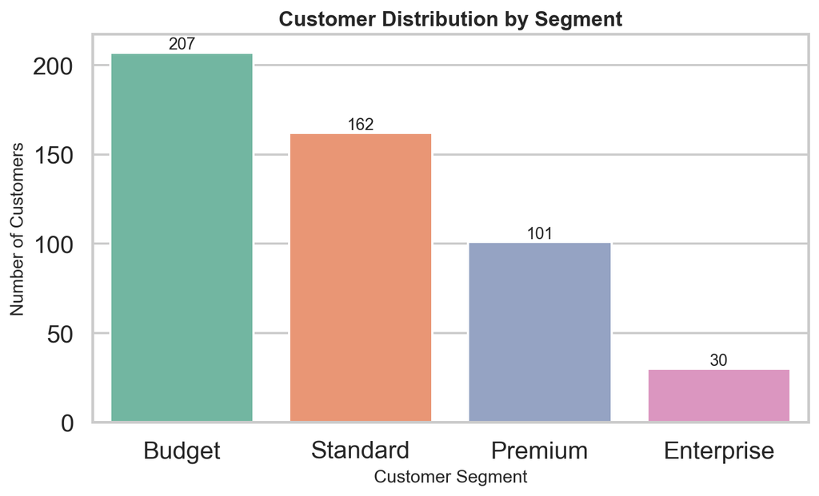

```python
import seaborn as sns
import matplotlib.pyplot as plt
import pandas as pd
import numpy as np

# Sample data: Customer segments
np.random.seed(42)
segments = np.random.choice(['Budget', 'Standard', 'Premium', 'Enterprise'],
                            size=500,
                            p=[0.4, 0.35, 0.20, 0.05])  # Weighted probabilities

df = pd.DataFrame({'segment': segments})

fig, ax = plt.subplots(figsize=(8, 5))

sns.countplot(data=df, x='segment',
              order=['Budget', 'Standard', 'Premium', 'Enterprise'],
              palette='Set2', ax=ax)

ax.set_title('Customer Distribution by Segment',
             fontsize=14, fontweight='bold')
ax.set_xlabel('Customer Segment', fontsize=12)
ax.set_ylabel('Number of Customers', fontsize=12)

# Add count labels on bars
for container in ax.containers:
    ax.bar_label(container, fontsize=11)

plt.tight_layout()
plt.show()
```

**Output:**

*[Count plot: “Customer Distribution by Segment”, x: Customer Segment, y: Number of Customers]*

**Key Parameters Explained:**

- **order**: Specify category order (important for logical flow)
  - Without order: Alphabetical (often meaningless)
  - With order: Logical sequence (Budget → Enterprise)
- **palette**: Color scheme
  - ‘Set1’, ‘Set2’, ‘Set3’: Distinct colors
  - ‘Blues’, ‘Greens’: Single-hue gradients
  - Custom list: [‘#FF6B6B’, ‘#4ECDC4’, ‘#45B7D1’]

**Adding Percentages:**

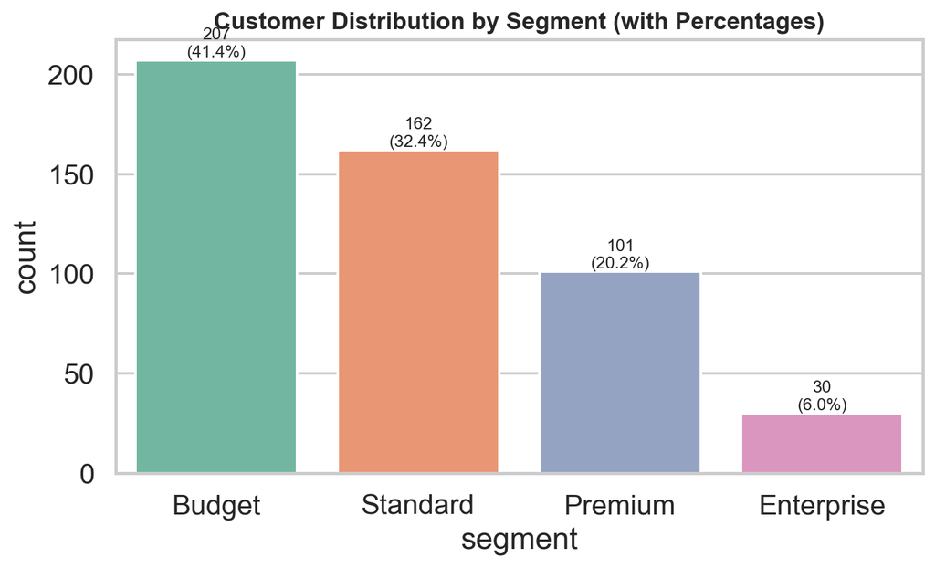

```python
# Calculate and display percentages
total = len(df)
fig, ax = plt.subplots(figsize=(8, 5))

sns.countplot(data=df, x='segment',
              order=['Budget', 'Standard', 'Premium', 'Enterprise'],
              palette='Set2', ax=ax)

# Add percentage labels
for container in ax.containers:
    labels = [f'{int(v.get_height())}\n({v.get_height()/total*100:.1f}%)'
              for v in container]
    ax.bar_label(container, labels=labels, fontsize=10)

ax.set_title('Customer Distribution by Segment (with Percentages)',
             fontsize=14, fontweight='bold')
plt.tight_layout()
plt.show()
```

**Output:**

*[Count plot: “Customer Distribution by Segment (with Percentages)”, x: segment]*

**Business Interpretation:**

**Bar Plots - Showing Aggregated Values**

**Beyond Counts - Showing Calculated Values:**

While count plots show frequencies, bar plots show **aggregated metrics** for each category:

- Average revenue by region
- Total sales by product category
- Median salary by department

**The Critical Difference:**

- **Count plot**: “How many customers in each region?”
- **Bar plot**: “What’s the average revenue per customer in each region?”

**Creating a Bar Plot:**

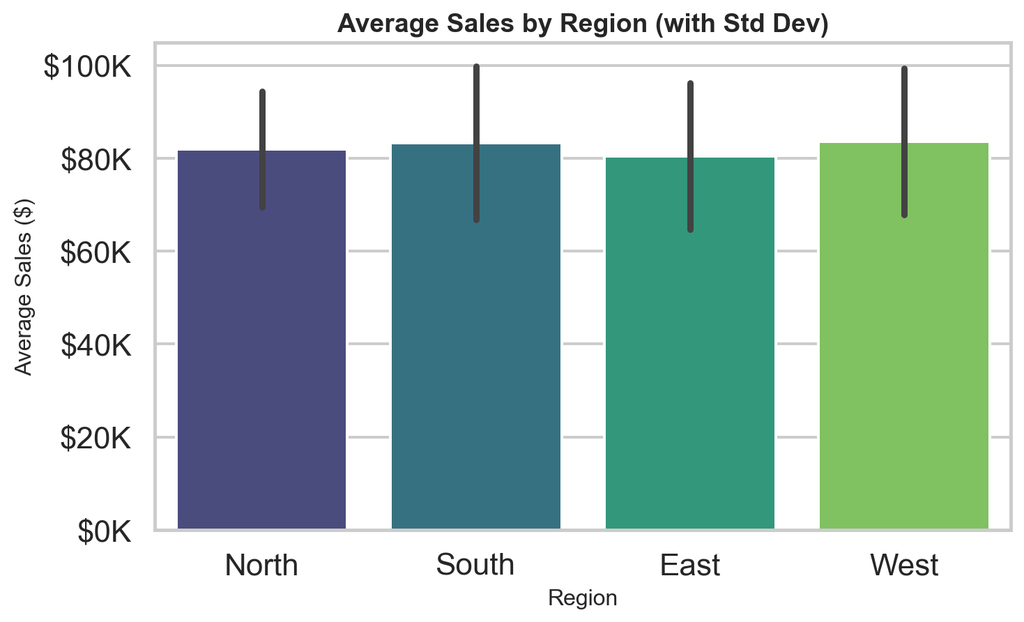

```python
import seaborn as sns
import matplotlib.pyplot as plt
import pandas as pd
import numpy as np

# Sales data by region
np.random.seed(42)
regions = ['North', 'South', 'East', 'West'] * 50
sales = np.concatenate([
    np.random.normal(85000, 15000, 50),   # North
    np.random.normal(75000, 12000, 50),   # South
    np.random.normal(92000, 18000, 50),   # East
    np.random.normal(80000, 14000, 50)    # West
])

df_sales = pd.DataFrame({
    'region': regions,
    'sales': sales
})

fig, ax = plt.subplots(figsize=(8, 5))

# Bar plot shows MEAN by default
sns.barplot(data=df_sales, x='region', y='sales',
            order=['North', 'South', 'East', 'West'],
            palette='viridis',
            errorbar='sd',  # Standard deviation error bars
            ax=ax)

ax.set_title('Average Sales by Region (with Std Dev)',
             fontsize=14, fontweight='bold')
ax.set_xlabel('Region', fontsize=12)
ax.set_ylabel('Average Sales ($)', fontsize=12)

# Format Y-axis
ax.yaxis.set_major_formatter(plt.FuncFormatter(lambda x, p: f'${x/1000:.0f}K'))

plt.tight_layout()
plt.show()
```

**Output:**

*[Bar plot: “Average Sales by Region (with Std Dev)”, x: Region, y: Average Sales ($)]*

**Understanding Error Bars:**

The black lines on top of bars represent uncertainty or variability:

- **errorbar=‘sd’**: Standard deviation (shows data spread)
- **errorbar=‘se’**: Standard error (shows estimate uncertainty)
- **errorbar=(‘ci’, 95)**: 95% confidence interval (default)
- **errorbar=None**: No error bars

**Changing the Aggregation Function:**

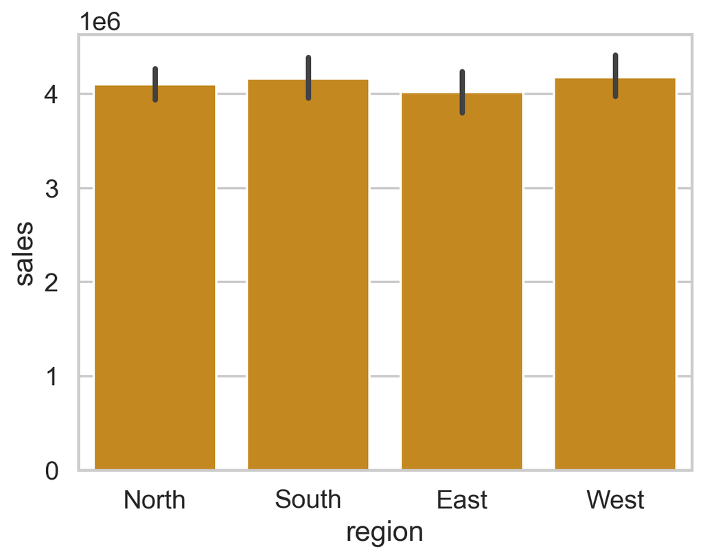

```python
# Instead of mean, show median or sum
sns.barplot(data=df_sales, x='region', y='sales',
            estimator='median',  # Use median instead of mean
            errorbar=None)  # Median doesn't have standard CI

# Or total sales per region
sns.barplot(data=df_sales, x='region', y='sales',
            estimator='sum')
```

**Output:**

*[Bar plot: x: region, y: sales]*

**Violin Plots - Distribution Shapes Within Categories**

**The Problem with Bar Plots:**

Bar plots only show one summary statistic (mean, median). They hide:

- Distribution shape (normal? skewed? bimodal?)
- Outliers
- Full range of data

Violin plots solve this by showing the **entire distribution** for each category.

**What Violin Plots Show:**

A violin plot is essentially a **rotated, mirrored KDE plot** for each category:

- **Width**: Indicates density (more data at that value)
- **Shape**: Shows distribution characteristics
- Often includes a box plot inside for key statistics

**Creating Violin Plots:**

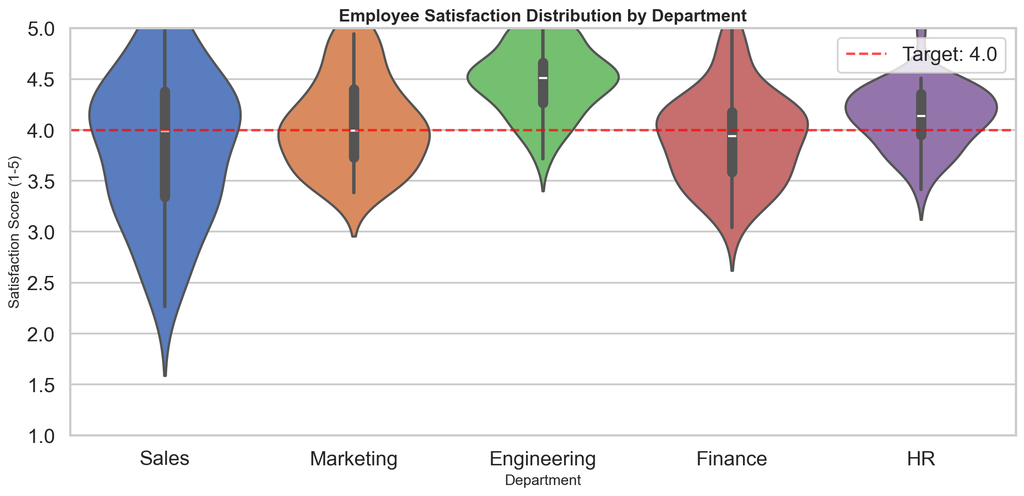

```python
import seaborn as sns
import matplotlib.pyplot as plt
import pandas as pd
import numpy as np

# Employee satisfaction by department
np.random.seed(42)
departments = ['Sales', 'Marketing', 'Engineering', 'Finance', 'HR'] * 40

satisfaction = []
for dept in departments:
    if dept == 'Engineering':
        satisfaction.extend(np.random.normal(4.5, 0.4, 1))  # High, consistent
    elif dept == 'Sales':
        satisfaction.extend(np.random.normal(3.8, 0.8, 1))  # Lower, variable
    elif dept == 'HR':
        satisfaction.extend(np.random.normal(4.2, 0.3, 1))  # Good, consistent
    else:
        satisfaction.extend(np.random.normal(4.0, 0.5, 1))

df_satisfaction = pd.DataFrame({
    'department': departments,
    'satisfaction': np.clip(satisfaction, 1, 5)  # Keep in 1-5 range
})

fig, ax = plt.subplots(figsize=(12, 6))

sns.violinplot(data=df_satisfaction, x='department', y='satisfaction',
               palette='muted',
               inner='box',  # Show box plot inside
               ax=ax)

ax.set_title('Employee Satisfaction Distribution by Department',
             fontsize=14, fontweight='bold')
ax.set_xlabel('Department', fontsize=12)
ax.set_ylabel('Satisfaction Score (1-5)', fontsize=12)
ax.set_ylim(1, 5)

# Add reference line at target satisfaction
ax.axhline(4.0, color='red', linestyle='--', linewidth=2, alpha=0.7, label='Target: 4.0')
ax.legend()

plt.tight_layout()
plt.show()
```

**Output:**

*[Violin plot: “Employee Satisfaction Distribution by Department”, x: Department, y: Satisfaction Score (1-5)]*

**Violin Plot Parameters:**

- **inner=‘box’**: Shows box plot inside (median, quartiles)
- **inner=‘quartile’**: Shows quartile lines only
- **inner=‘point’**: Shows individual points
- **inner=None**: Just the violin shape
- **split=True**: When you have a hue variable, creates split violins for comparison

**Reading Violin Plots:**

**Engineering Department (example):**

- **Narrow, tall violin**: Most employees clustered around 4.5
- **Little bulge at bottom**: Very few low scores
- **Interpretation**: Consistently high satisfaction

**Business Application:**

HR uses violin plots to:

- Identify departments with satisfaction problems
- Spot bimodal distributions (two distinct employee groups)
- Compare not just averages but entire experience ranges
- Target interventions to specific issues

**Box Plots for Categorical Comparisons**

**The Statistical Workhorse:**

We introduced box plots in Section 1, but they shine brightest when comparing distributions across categories.

**Enhanced Categorical Box Plots:**

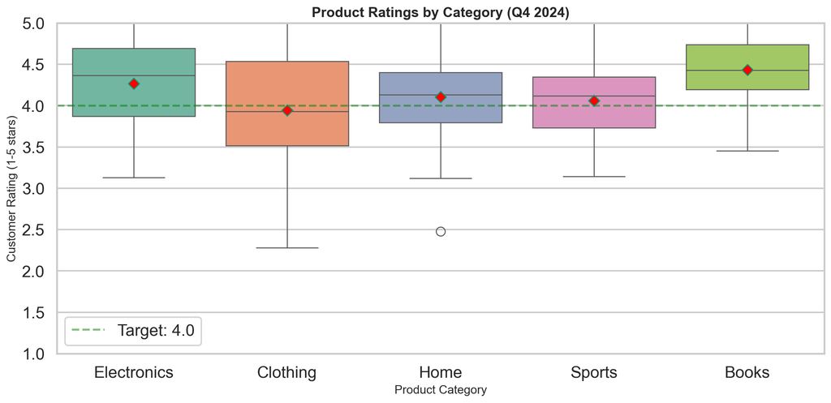

```python
import seaborn as sns
import matplotlib.pyplot as plt
import pandas as pd
import numpy as np

# Product ratings by category
np.random.seed(42)
categories = ['Electronics', 'Clothing', 'Home', 'Sports', 'Books'] * 60

ratings = []
for cat in categories:
    if cat == 'Electronics':
        ratings.extend(np.random.normal(4.3, 0.6, 1))
    elif cat == 'Books':
        ratings.extend(np.random.normal(4.5, 0.4, 1))
    elif cat == 'Clothing':
        ratings.extend(np.random.normal(3.9, 0.8, 1))
    else:
        ratings.extend(np.random.normal(4.1, 0.5, 1))

df_ratings = pd.DataFrame({
    'category': categories,
    'rating': np.clip(ratings, 1, 5)
})

fig, ax = plt.subplots(figsize=(12, 6))

sns.boxplot(data=df_ratings, x='category', y='rating',
            palette='Set2',
            showmeans=True,  # Show mean as well as median
            meanprops={'marker': 'D', 'markerfacecolor': 'red', 'markersize': 8},
            ax=ax)

ax.set_title('Product Ratings by Category (Q4 2024)',
             fontsize=14, fontweight='bold')
ax.set_xlabel('Product Category', fontsize=12)
ax.set_ylabel('Customer Rating (1-5 stars)', fontsize=12)
ax.set_ylim(1, 5)

# Add target line
ax.axhline(4.0, color='green', linestyle='--', linewidth=2, alpha=0.5, label='Target: 4.0')
ax.legend()

plt.tight_layout()
plt.show()
```

**Output:**

*[Box plot: “Product Ratings by Category (Q4 2024)”, x: Product Category, y: Customer Rating (1-5 stars)]*

**Box Plot vs Violin Plot - When to Use Each:**

**Use Box Plots when:**

- Precise statistics matter (median, quartiles, outliers)
- Comparing many categories (violin plots get cluttered)
- Audience prefers familiar formats
- Space is limited (box plots are compact)

**Use Violin Plots when:**

- Distribution shape matters
- Looking for bimodal patterns
- Audience can interpret density plots
- Have fewer categories to compare

**Point Plots - Showing Trends Across Categories**

**Emphasizing Changes and Comparisons:**

Point plots are like line charts for categorical data, excellent for showing:

- Changes across ordered categories (quarters, years)
- Comparing multiple groups across categories
- Emphasizing trends in categorical data

**Creating Point Plots:**

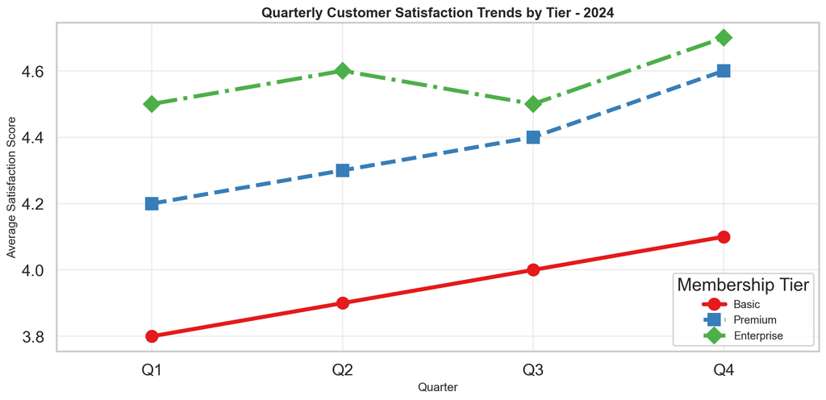

```python
import seaborn as sns
import matplotlib.pyplot as plt
import pandas as pd
import numpy as np

# Customer satisfaction over quarters for different tiers
np.random.seed(42)
quarters = ['Q1', 'Q2', 'Q3', 'Q4'] * 3
tiers = ['Basic'] * 4 + ['Premium'] * 4 + ['Enterprise'] * 4

satisfaction = [
    3.8, 3.9, 4.0, 4.1,      # Basic: steady improvement
    4.2, 4.3, 4.4, 4.6,      # Premium: strong improvement
    4.5, 4.6, 4.5, 4.7       # Enterprise: already high, slight fluctuation
]

df_quarterly = pd.DataFrame({
    'quarter': quarters,
    'tier': tiers,
    'satisfaction': satisfaction
})

fig, ax = plt.subplots(figsize=(12, 6))

sns.pointplot(data=df_quarterly, x='quarter', y='satisfaction',
              hue='tier',
              markers=['o', 's', 'D'],
              linestyles=['-', '--', '-.'],
              palette='Set1',
              ax=ax)

ax.set_title('Quarterly Customer Satisfaction Trends by Tier - 2024',
             fontsize=14, fontweight='bold')
ax.set_xlabel('Quarter', fontsize=12)
ax.set_ylabel('Average Satisfaction Score', fontsize=12)
ax.legend(title='Membership Tier', fontsize=11)
ax.grid(True, alpha=0.3)

plt.tight_layout()
plt.show()
```

**Output:**

*[Chart: “Quarterly Customer Satisfaction Trends by Tier - 2024”, x: Quarter, y: Average Satisfaction Score]*

**Point Plot Features:**

- **Points**: Show the mean (or other statistic) for each category
- **Lines**: Connect points to emphasize trends
- **Error bars**: Show confidence intervals (95% by default)
- **Multiple series**: Use hue parameter for comparisons

**Business Insights from Point Plots:**

**Strip and Swarm Plots - Showing Individual Data Points**

**When You Need to See Every Observation:**

Sometimes aggregations hide important details. Strip and swarm plots show **every individual data point** while organizing by category.

**Strip Plots (with jitter):**

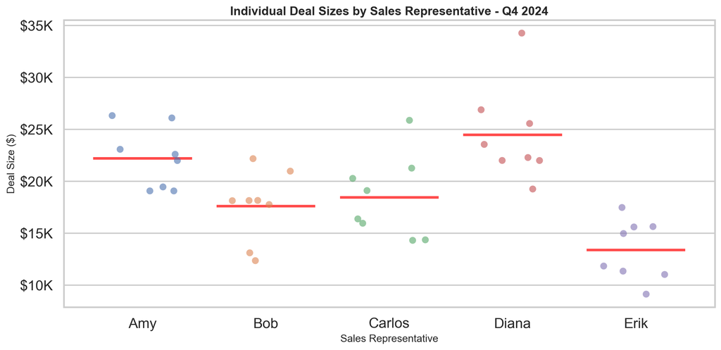

```python
import seaborn as sns
import matplotlib.pyplot as plt
import pandas as pd
import numpy as np

# Sales rep performance (fewer data points, want to see individuals)
np.random.seed(42)
reps = ['Amy', 'Bob', 'Carlos', 'Diana', 'Erik']
performance = []
rep_names = []

for rep in reps:
    n_deals = 8  # Each rep closed 8 deals this quarter
    if rep == 'Diana':
        deals = np.random.normal(25000, 5000, n_deals)  # Top performer
    elif rep == 'Erik':
        deals = np.random.normal(15000, 3000, n_deals)  # Struggling
    else:
        deals = np.random.normal(20000, 4000, n_deals)

    performance.extend(deals)
    rep_names.extend([rep] * n_deals)

df_reps = pd.DataFrame({
    'sales_rep': rep_names,
    'deal_size': performance
})

fig, ax = plt.subplots(figsize=(12, 6))

sns.stripplot(data=df_reps, x='sales_rep', y='deal_size',
              jitter=0.3,  # Add horizontal jitter to prevent overlap
              alpha=0.6,   # Transparency
              size=8,      # Point size
              palette='deep',
              ax=ax)

ax.set_title('Individual Deal Sizes by Sales Representative - Q4 2024',
             fontsize=14, fontweight='bold')
ax.set_xlabel('Sales Representative', fontsize=12)
ax.set_ylabel('Deal Size ($)', fontsize=12)

# Format Y-axis
ax.yaxis.set_major_formatter(plt.FuncFormatter(lambda x, p: f'${x/1000:.0f}K'))

# Add mean line for each rep
for i, rep in enumerate(reps):
    mean_val = df_reps[df_reps['sales_rep'] == rep]['deal_size'].mean()
    ax.hlines(mean_val, i-0.4, i+0.4, colors='red', linewidth=3, alpha=0.7)

plt.tight_layout()
plt.show()
```

**Output:**

*[Strip plot: “Individual Deal Sizes by Sales Representative - Q4 2024”, x: Sales Representative, y: Deal Size ($)]*

**Strip Plot Parameters:**

- **jitter**: Amount of horizontal random spread (0-0.5 typical)
  - Without jitter: Points stack vertically (hard to see count)
  - With jitter: Points spread horizontally (see all observations)
- **size**: Point size (adjust based on number of points)
- **alpha**: Transparency (important when points overlap)

**Swarm Plots (organized arrangement):**

Swarm plots are like strip plots but organize points to avoid overlap:

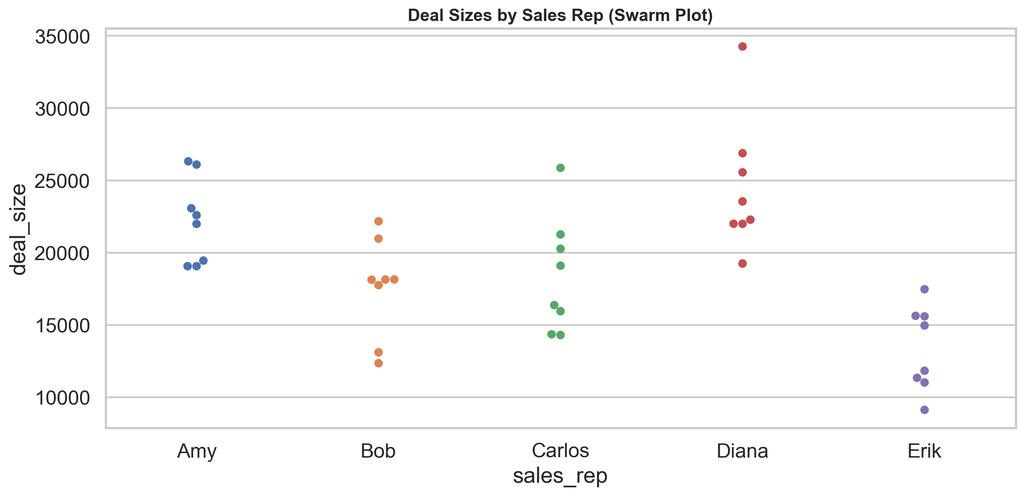

```python
fig, ax = plt.subplots(figsize=(12, 6))

sns.swarmplot(data=df_reps, x='sales_rep', y='deal_size',
              palette='deep',
              size=7,
              ax=ax)

ax.set_title('Deal Sizes by Sales Rep (Swarm Plot)',
             fontsize=14, fontweight='bold')
plt.tight_layout()
plt.show()
```

**Output:**

*[Strip plot: “Deal Sizes by Sales Rep (Swarm Plot)”, x: sales_rep, y: deal_size]*

**Swarm Plot Characteristics:**

- **No overlap**: Each point is visible
- **Density visible**: Width shows concentration
- **Beautiful**: Aesthetically pleasing arrangement

**Warning**: Swarm plots don’t scale well beyond ~500 points per category.

**Business Use Cases:**

**Use strip/swarm plots when:**

- Small dataset (< 500 points total)
- Individual observations matter (sales deals, major contracts)
- Looking for outliers or unusual patterns
- Need to identify specific data points
- Transparency about data size important

**Combining Multiple Categorical Plots**

**Layering Plots for Rich Insights:**

Seaborn allows combining plot types for comprehensive visualization:

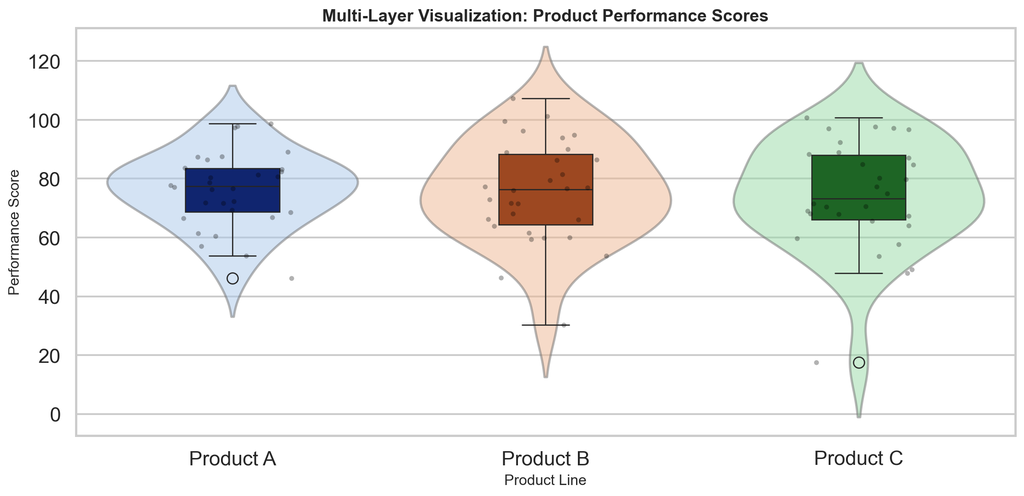

```python
import seaborn as sns
import matplotlib.pyplot as plt
import pandas as pd
import numpy as np

# Generate data
np.random.seed(42)
categories = ['Product A', 'Product B', 'Product C'] * 30
values = np.concatenate([
    np.random.normal(75, 15, 30),
    np.random.normal(85, 12, 30),
    np.random.normal(70, 20, 30)
])

df = pd.DataFrame({'product': categories, 'score': values})

fig, ax = plt.subplots(figsize=(12, 6))

# Layer 1: Violin plot for distributions
sns.violinplot(data=df, x='product', y='score',
               inner=None, palette='pastel', alpha=0.5, ax=ax)

# Layer 2: Box plot for statistics
sns.boxplot(data=df, x='product', y='score',
            width=0.3, palette='dark', ax=ax)

# Layer 3: Individual points
sns.stripplot(data=df, x='product', y='score',
              size=4, color='black', alpha=0.3, jitter=0.2, ax=ax)

ax.set_title('Multi-Layer Visualization: Product Performance Scores',
             fontsize=14, fontweight='bold')
ax.set_xlabel('Product Line', fontsize=12)
ax.set_ylabel('Performance Score', fontsize=12)

plt.tight_layout()
plt.show()
```

**Output:**

*[Violin plot: “Multi-Layer Visualization: Product Performance Scores”, x: Product Line, y: Performance Score]*

**What This Reveals:**

- **Violin**: Overall distribution shape
- **Box**: Key statistics (median, quartiles)
- **Points**: Individual observations and outliers

This comprehensive view helps:

- Identify distribution shapes
- See statistical summaries
- Verify claims with raw data
- Spot unusual patterns

### 3.3.3 Lab Session

**Lab 3: Categorical Data Analysis**

**Objective:** Master categorical visualization techniques to analyze business performance across departments, products, regions, and customer segments.

**Scenario:** You’re the Operations Analyst at “GlobalManufacture Inc.,” a mid-size manufacturing company with multiple product lines, 8 regional offices, and 300+ employees. The COO is preparing the annual operations review and needs comprehensive categorical analysis to identify performance patterns, problem areas, and opportunities. Your task is to create professional categorical visualizations that tell clear stories about operational performance.

**Pre-Lab Setup:**

1. Create file: `M3L03_YourName_Categorical.py`
2. Import and configure:

```python
import seaborn as sns
import matplotlib.pyplot as plt
import pandas as pd
import numpy as np

sns.set_theme(style="whitegrid", context="talk", palette="colorblind")
```

3. Create output folder: “Lab3_Outputs”

**Part A: Product Line Performance Analysis (25 points)**

**Context:** The Product VP needs to understand which product lines are performing well and which need attention.

**Data:**

```python
np.random.seed(42)

# 5 product lines, 60 sales transactions each
products = ['Industrial Tools', 'Safety Equipment', 'Machinery Parts',
            'Automation Systems', 'Maintenance Supplies'] * 60

revenue = []
for product in products:
    if product == 'Automation Systems':
        revenue.append(np.random.normal(85000, 20000, 1)[0])  # High value, variable
    elif product == 'Industrial Tools':
        revenue.append(np.random.normal(45000, 8000, 1)[0])   # Medium, consistent
    elif product == 'Safety Equipment':
        revenue.append(np.random.normal(25000, 5000, 1)[0])   # Low, consistent
    elif product == 'Machinery Parts':
        revenue.append(np.random.normal(55000, 15000, 1)[0])  # Medium-high, variable
    else:
        revenue.append(np.random.normal(15000, 3000, 1)[0])   # Low volume

df_products = pd.DataFrame({
    'product_line': products,
    'deal_revenue': np.maximum(revenue, 5000)  # Ensure positive values
})
```

**Tasks:**

1. **Create comprehensive box plot comparison (12 points):**
   - Figure size: (14, 7)
   - Horizontal box plot (swap x and y for better label reading)
   - Sort product lines by median revenue (highest to lowest)
   - Show means with red diamond markers
   - Use professional color palette
   - Title: “Deal Revenue Distribution by Product Line - 2024”
   - Format revenue axis as “$85K”, “$45K”, etc.
   - Add vertical reference line at company average revenue
2. **Create layered visualization (8 points):**
   - Same data, new figure
   - Combine violin plot (background, pastel, alpha=0.4)
   - With box plot overlay (narrower width=0.4)
   - And strip plot (small dots, alpha=0.3, jitter=0.2)
   - Same title and formatting
   - This shows distribution, statistics, and individual deals simultaneously
3. **Business analysis (5 points):**
   - In code comments, answer:
     - Which product line has highest median revenue?
     - Which has most variability (widest IQR)?
     - Identify any outliers and speculate why
     - Which product lines are above company average?
     - What strategic recommendations would you make?
   - Save both plots:
     - `M3L03_YourName_ProductBoxPlot.png`
     - `M3L03_YourName_ProductLayered.png`

**Part B: Regional Performance Trends (30 points)**

**Context:** The Regional Directors meeting is next week. Each director needs to see how their region performed quarterly throughout 2024 compared to other regions.

**Data:**

```python
np.random.seed(42)

regions = ['Northeast', 'Southeast', 'Midwest', 'Southwest',
           'West', 'Northwest', 'Central', 'Florida']
quarters = ['Q1', 'Q2', 'Q3', 'Q4']

data_list = []
for region in regions:
    base_performance = np.random.uniform(70, 90)  # Each region has base performance
    trend = np.random.uniform(-2, 5)  # Each region has a trend

    for q, quarter in enumerate(quarters):
        # Performance with trend and some randomness
        performance = base_performance + (trend * q) + np.random.normal(0, 3)
        performance = np.clip(performance, 50, 100)  # Keep in reasonable range

        data_list.append({
            'region': region,
            'quarter': quarter,
            'performance_score': performance
        })

df_regional = pd.DataFrame(data_list)
```

**Tasks:**

1. **Create point plot showing trends (15 points):**
   - Figure size: (14, 8)
   - X-axis: quarter
   - Y-axis: performance_score
   - Hue: region (different line for each region)
   - Use different markers for top 4 regions vs bottom 4
   - Include confidence intervals (error bars)
   - Title: “Regional Performance Trends - 2024 Quarterly”
   - Add horizontal line at 80 (target performance)
   - Legend outside plot area (right side)
2. **Create categorical comparison by quarter (10 points):**
   - Create 1×4 subplots (one for each quarter)
   - Each subplot: bar plot of average performance by region
   - Sort regions by performance (descending) in each quarter
   - Consistent color scheme across subplots
   - Overall title: “Regional Performance by Quarter - 2024”
   - Identify which regions improved most from Q1 to Q4
3. **Analysis and recommendations (5 points):**
   - Calculate quarterly growth rate for each region
   - Identify top 3 improving regions and bottom 3
   - In comments, provide:
     - Which region was most consistent (least variance)?
     - Which region improved most across the year?
     - Which region(s) declined and need intervention?
     - Specific recommendations for next year
   - Save as: `M3L03_YourName_RegionalTrends.png` and `M3L03_YourName_QuarterlyComparison.png`

**Part C: Employee Department Analysis (25 points)**

**Context:** HR is conducting an employee engagement survey analysis. They need to understand satisfaction and salary distributions across departments to identify equity issues and engagement problems.

**Data:**

```python
np.random.seed(42)

departments = ['Engineering', 'Sales', 'Marketing', 'Operations',
               'Finance', 'HR', 'Customer Success', 'R&D']
n_per_dept = 40

data_list = []
for dept in departments:
    for _ in range(n_per_dept):
        # Different departments have different characteristics
        if dept == 'Engineering':
            salary = np.random.normal(95000, 15000, 1)[0]
            satisfaction = np.random.normal(4.2, 0.5, 1)[0]
        elif dept == 'Sales':
            salary = np.random.normal(75000, 25000, 1)[0]  # High variance (commission)
            satisfaction = np.random.normal(3.8, 0.9, 1)[0]  # Variable satisfaction
        elif dept == 'R&D':
            salary = np.random.normal(105000, 12000, 1)[0]  # Highest salaries
            satisfaction = np.random.normal(4.5, 0.3, 1)[0]  # Highest satisfaction
        elif dept == 'Customer Success':
            salary = np.random.normal(65000, 10000, 1)[0]
            satisfaction = np.random.normal(3.5, 0.7, 1)[0]  # Lowest satisfaction
        else:
            salary = np.random.normal(80000, 15000, 1)[0]
            satisfaction = np.random.normal(4.0, 0.5, 1)[0]

        data_list.append({
            'department': dept,
            'salary': max(salary, 40000),
            'satisfaction': np.clip(satisfaction, 1, 5)
        })

df_employees = pd.DataFrame(data_list)
```

**Tasks:**

1. **Create violin plot for salary distribution (12 points):**
   - Figure size: (14, 8)
   - Show salary distribution by department
   - Use split violin if you add a second category (e.g., gender - you’d need to generate this)
   - Include inner box plot (inner=‘box’)
   - Sort departments by median salary
   - Title: “Salary Distribution by Department”
   - Format Y-axis as “$95K”, “$75K”, etc.
   - Add horizontal lines at 25th, 50th, 75th percentile of overall salary
   - Color code: Use palette that emphasizes high vs low paid departments
2. **Create satisfaction vs salary scatter with categories (8 points):**
   - New figure (12, 7)
   - Scatter plot: salary (x) vs satisfaction (y)
   - Color by department
   - Add size variation based on count
   - Include trend line for each department using sns.lmplot or manual regression
   - Title: “Salary vs Satisfaction by Department”
   - Does higher pay correlate with satisfaction? Does it vary by department?
3. **HR recommendations (5 points):**
   - Calculate key statistics:
     - Department with highest/lowest median salary
     - Department with highest/lowest satisfaction
     - Correlation between salary and satisfaction overall
     - Identify departments with satisfaction issues despite good pay
   - In comments, provide:
     - Departments requiring immediate HR attention
     - Evidence of pay equity across departments
     - Recommendations for improving engagement
   - Save as: `M3L03_YourName_SalaryViolin.png` and `M3L03_YourName_SalarySatisfaction.png`

**Part D: Customer Segment Count and Revenue Analysis (20 points)**

**Context:** Marketing wants to understand customer distribution and value across segments for 2025 budget allocation.

**Data:**

```python
np.random.seed(42)

# Generate customer base with realistic distribution
segments_list = (['Small Business'] * 450 +
                ['Mid-Market'] * 250 +
                ['Enterprise'] * 80 +
                ['Startup'] * 220)

industries = ['Manufacturing', 'Technology', 'Healthcare',
              'Retail', 'Finance', 'Education']

data_list = []
for segment in segments_list:
    industry = np.random.choice(industries)

    if segment == 'Enterprise':
        revenue = np.random.lognormal(12, 0.5)  # Very high, right-skewed
    elif segment == 'Mid-Market':
        revenue = np.random.lognormal(10, 0.6)
    elif segment == 'Small Business':
        revenue = np.random.lognormal(8, 0.7)
    else:  # Startup
        revenue = np.random.lognormal(7, 0.9)

    data_list.append({
        'segment': segment,
        'industry': industry,
        'annual_revenue': revenue
    })

df_customers = pd.DataFrame(data_list)
```

**Tasks:**

1. **Create count plot with percentages (10 points):**
   - Figure size: (12, 6)
   - Count plot of customer segments
   - Order: Enterprise, Mid-Market, Small Business, Startup (value-based)
   - Add count labels on bars with percentages
   - Color gradient: Enterprise (gold) to Startup (blue)
   - Title: “Customer Base Distribution by Segment”
   - Second plot: Stacked bar showing industry mix within each segment
2. **Create bar plot comparing average revenue (10 points):**
   - Figure size: (12, 6)
   - Show average revenue by segment
   - Include error bars (95% CI)
   - Add text annotations showing total revenue contribution: count × average
   - Use log scale if needed to show all segments clearly
   - Title: “Average Annual Revenue by Customer Segment”
   - Calculate: Which segment generates most total revenue despite count?
   - Save as: `M3L03_YourName_CustomerCount.png` and `M3L03_YourName_SegmentRevenue.png`

**Bonus Challenge (+25 points):**

**Create a Comprehensive Categorical Dashboard:**

Build a 2×3 grid (6 subplots) showing: 1. Product line revenue distributions (violin plot) 2. Regional performance trends (point plot) 3. Department satisfaction scores (box plot) 4. Customer segment counts (count plot with percentages) 5. Salary distribution by department (horizontal box plot) 6. Industry vs Segment heatmap (count of customers in each combination)

**Requirements:**

- Figure size: (20, 12)
- Consistent styling across all subplots
- Professional color schemes (use different palettes for different contexts)
- All plots properly labeled
- Overall title: “GlobalManufacture Inc. - 2024 Operations Dashboard”
- Proper spacing (use subplots_adjust or tight_layout)
- Each subplot should be readable and informative
- Save as: `M3L03_YourName_CategoricalDashboard.png`

**Deliverables:**

1. Python file: `M3L03_YourName_Categorical.py`
2. PNG files (9 files minimum):
   - `M3L03_YourName_ProductBoxPlot.png`
   - `M3L03_YourName_ProductLayered.png`
   - `M3L03_YourName_RegionalTrends.png`
   - `M3L03_YourName_QuarterlyComparison.png`
   - `M3L03_YourName_SalaryViolin.png`
   - `M3L03_YourName_SalarySatisfaction.png`
   - `M3L03_YourName_CustomerCount.png`
   - `M3L03_YourName_SegmentRevenue.png`
   - `M3L03_YourName_CategoricalDashboard.png` (bonus)

**Grading Rubric:**

- Part A (Product Analysis): 25 points
- Part B (Regional Trends): 30 points
- Part C (Employee Analysis): 25 points
- Part D (Customer Segments): 20 points
- Bonus (Dashboard): +25 points

**Success Criteria:**

- Appropriate plot types selected for each question
- Categories ordered logically (not alphabetically)
- All visualizations include proper labels and units
- Color choices are professional and meaningful
- Statistical features (means, medians, reference lines) included
- Business insights documented in comments
- Layered plots show complementary information
- High-resolution outputs

**Categorical Visualization Decision Framework:**

| Question | Best Plot Type |
| --- | --- |
| How many in each category? | Count plot |
| What’s the average per category? | Bar plot |
| How do distributions differ? | Violin or Box plot |
| What are trends across categories? | Point plot |
| Need to see all data points? | Strip or Swarm plot |
| Complex distribution comparison? | Layered: Violin + Box + Strip |

**Common Mistakes to Avoid:**

- Alphabetical ordering when logical ordering exists
- Too many categories in one plot (>8 becomes cluttered)
- Not showing variability (error bars, distributions)
- Ignoring outliers without investigation
- Poor color choices (rainbow palette, not colorblind-safe)
- Missing reference lines or benchmarks
- Not connecting categorical findings to business actions

## 3.4 Section 4: Heatmaps and Correlation Analysis

### 3.4.1 Objective

- Create and interpret correlation heatmaps for multivariate analysis
- Understand correlation coefficients and their business implications
- Use annotated heatmaps to communicate numerical relationships
- Create pivot table heatmaps for two-way categorical analysis
- Apply appropriate color schemes for different data types
- Identify multicollinearity and redundant variables
- Use clustermap for hierarchical relationship visualization

### 3.4.2 Main Contents with Examples

**The Challenge of Multivariate Data**

**Beyond Two Variables:**

So far, we’ve explored:

- Single variables (histograms, KDE)
- Two variables (scatter plots, joint plots)
- Categories with one metric (box plots, bar plots)

But business data is **multivariate** - many variables interacting:

- Customer data: Age, income, tenure, purchase frequency, satisfaction, lifetime value
- Product metrics: Price, cost, sales volume, returns, ratings, reviews
- Financial data: Revenue, expenses, profit, assets, liabilities, ratios

**The Visualization Problem:**

How do you visualize 10+ variables simultaneously?

- Pair plot works but becomes overwhelming (10 variables = 45 plots!)
- Need a compact way to see all relationships at once

**Solution: Heatmaps**

Heatmaps show many values at once using color intensity:

- **Rows**: Variables
- **Columns**: Variables (or categories)
- **Color**: Strength of relationship or value

One glance reveals patterns across dozens of relationships.

**Understanding Correlation**

**What is Correlation?**

Correlation measures the **strength and direction** of a linear relationship between two variables.

**Correlation Coefficient (r):**

- Ranges from **-1 to +1**
- **+1**: Perfect positive linear relationship (as X↑, Y↑)
- **0**: No linear relationship
- **-1**: Perfect negative linear relationship (as X↑, Y↓)

**Interpretation Scale:**

| Coefficient Range | Interpretation | Business Meaning |
| --- | --- | --- |
| 0.9 to 1.0 | Very strong positive | Highly predictive |
| 0.7 to 0.9 | Strong positive | Reliable relationship |
| 0.5 to 0.7 | Moderate positive | Noticeable pattern |
| 0.3 to 0.5 | Weak positive | Slight tendency |
| 0.0 to 0.3 | Very weak | Minimal relationship |
| -0.3 to 0.0 | Very weak negative | Minimal inverse |
| -0.5 to -0.3 | Weak negative | Slight inverse |
| -0.7 to -0.5 | Moderate negative | Noticeable inverse |
| -0.9 to -0.7 | Strong negative | Reliable inverse |
| -1.0 to -0.9 | Very strong negative | Highly inverse |

**Business Examples:**

**Strong Positive (r = 0.85):**

- Advertising spend → Sales
- **Interpretation**: Reliable predictor, invest with confidence

**Moderate Positive (r = 0.55):**

- Customer age → Average purchase amount
- **Interpretation**: Pattern exists but other factors matter

**Weak Negative (r = -0.35):**

- Product price → Sales volume
- **Interpretation**: Price affects sales slightly, but demand is relatively inelastic

**Very Weak (r = 0.12):**

- Employee height → Salary
- **Interpretation**: No meaningful relationship (as expected!)

**Creating Correlation Matrices**

**Calculating Correlations in Pandas:**

```python
import pandas as pd
import numpy as np

# Sample business data
np.random.seed(42)

df = pd.DataFrame({
    'revenue': np.random.normal(100000, 20000, 100),
    'marketing_spend': np.random.normal(15000, 3000, 100),
    'sales_calls': np.random.poisson(25, 100),
    'customer_satisfaction': np.random.uniform(3.5, 5.0, 100),
    'product_price': np.random.uniform(50, 200, 100)
})

# Add realistic relationships
df['revenue'] = (50000 +
                 2.5 * df['marketing_spend'] +
                 500 * df['sales_calls'] +
                 np.random.normal(0, 5000, 100))

# Calculate correlation matrix
correlation_matrix = df.corr()
print(correlation_matrix)
```

```
                        revenue  marketing_spend  sales_calls  \
revenue                1.000000         0.796992     0.282892
marketing_spend        0.796992         1.000000    -0.012601
sales_calls            0.282892        -0.012601     1.000000
customer_satisfaction  0.065851         0.064170     0.062285
product_price          0.026338        -0.035095     0.027910

                       customer_satisfaction  product_price
revenue                             0.065851       0.026338
marketing_spend                     0.064170      -0.035095
sales_calls                         0.062285       0.027910
customer_satisfaction               1.000000       0.052959
product_price                       0.052959       1.000000
```

**Output:**

```
                        revenue  ...  product_price
revenue                1.000000  ...       0.026338
marketing_spend        0.796992  ...      -0.035095
sales_calls            0.282892  ...       0.027910
customer_satisfaction  0.065851  ...       0.052959
product_price          0.026338  ...       1.000000

[5 rows x 5 columns]
```

**Understanding the Correlation Matrix:**

The output is a square table:

[output not shown]

**Reading the Matrix:**

- **Diagonal**: Always 1.0 (perfect correlation with itself)
- **Symmetric**: Upper and lower triangles are mirrors
- **Focus on**: Off-diagonal values (actual relationships)

**Key Insights:**

**Creating Basic Correlation Heatmaps**

**Visualizing the Correlation Matrix:**

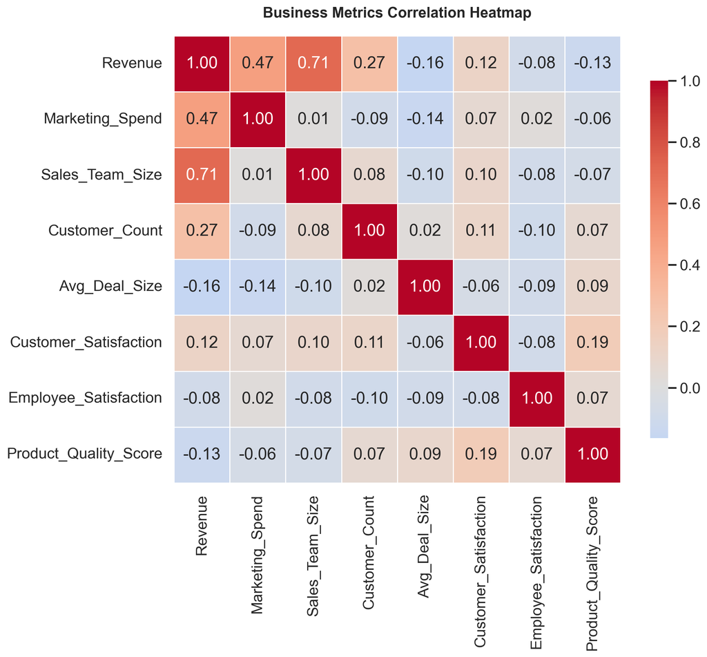

```python
import seaborn as sns
import matplotlib.pyplot as plt
import pandas as pd
import numpy as np

# Generate comprehensive business metrics data
np.random.seed(42)
n = 200

df = pd.DataFrame({
    'Revenue': np.random.normal(100000, 20000, n),
    'Marketing_Spend': np.random.normal(15000, 3000, n),
    'Sales_Team_Size': np.random.randint(5, 25, n),
    'Customer_Count': np.random.poisson(150, n),
    'Avg_Deal_Size': np.random.normal(5000, 1500, n),
    'Customer_Satisfaction': np.random.uniform(3.5, 5.0, n),
    'Employee_Satisfaction': np.random.uniform(3.0, 5.0, n),
    'Product_Quality_Score': np.random.normal(85, 10, n)
})

# Create realistic relationships
df['Revenue'] = (30000 +
                 2.5 * df['Marketing_Spend'] +
                 2000 * df['Sales_Team_Size'] +
                 300 * df['Customer_Count'] +
                 np.random.normal(0, 8000, n))

df['Customer_Satisfaction'] = (2.5 +
                               0.02 * df['Product_Quality_Score'] +
                               0.00001 * df['Revenue'] +
                               np.random.normal(0, 0.3, n))
df['Customer_Satisfaction'] = df['Customer_Satisfaction'].clip(1, 5)

# Calculate correlation matrix
corr_matrix = df.corr()

# Create heatmap
fig, ax = plt.subplots(figsize=(12, 10))

sns.heatmap(corr_matrix,
            annot=True,           # Show correlation values
            fmt='.2f',            # 2 decimal places
            cmap='coolwarm',      # Color scheme
            center=0,             # Center colormap at 0
            square=True,          # Square cells
            linewidths=1,         # Lines between cells
            cbar_kws={'shrink': 0.8},  # Colorbar size
            ax=ax)

ax.set_title('Business Metrics Correlation Heatmap',
             fontsize=16, fontweight='bold', pad=20)

plt.tight_layout()
plt.show()
```

**Output:**

*[Heatmap: “Business Metrics Correlation Heatmap”]*

**Heatmap Parameters Explained:**

**annot=True**: Shows actual correlation values

- Critical for business presentations
- Enables precise interpretation
- Numbers complement colors

**fmt=‘.2f’**: Format for annotations

- ‘.2f’: Two decimals (0.85)
- ‘.3f’: Three decimals (0.853)
- ‘.1f’: One decimal (0.9)

**cmap=‘coolwarm’**: Color scheme

- **coolwarm**: Blue (negative) to Red (positive), white (zero)
- **RdYlGn**: Red (low) to Green (high) - good for all positive
- **viridis**: Perceptually uniform, colorblind-safe
- **vlag**: Similar to coolwarm, more saturated

**center=0**: Where to center the colormap

- **0**: Natural for correlations (-1 to +1)
- Makes positive/negative clear

**square=True**: Makes cells square

- Easier to read
- More professional appearance

**Reading a Correlation Heatmap:**

**Strong Positive (Dark Red):**

**Strong Negative (Dark Blue):**

- (If present) indicates inverse relationships
- Example: Price & Volume might be -0.65

**Weak Correlations (White/Light):**

**Surprising Patterns:**

**Advanced Heatmap Techniques**

**Masking the Upper Triangle (Avoid Redundancy):**

Since correlation matrices are symmetric, showing both triangles is redundant:

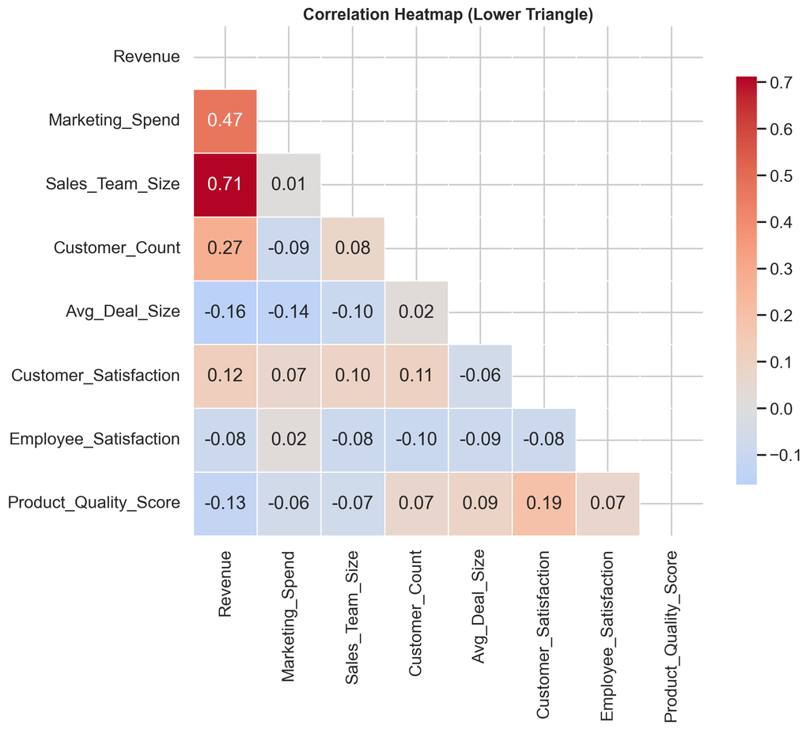

```python
import numpy as np

# Generate mask for upper triangle
mask = np.triu(np.ones_like(corr_matrix, dtype=bool))

fig, ax = plt.subplots(figsize=(12, 10))

sns.heatmap(corr_matrix,
            mask=mask,            # Hide upper triangle
            annot=True,
            fmt='.2f',
            cmap='coolwarm',
            center=0,
            square=True,
            linewidths=1,
            cbar_kws={'shrink': 0.8},
            ax=ax)

ax.set_title('Correlation Heatmap (Lower Triangle)',
             fontsize=16, fontweight='bold')

plt.tight_layout()
plt.show()
```

**Output:**

*[Heatmap: “Correlation Heatmap (Lower Triangle)”]*

**Benefits:**

- Cleaner, more professional
- Eliminates distraction
- Saves space for larger variable sets

**Highlighting Strong Correlations:**

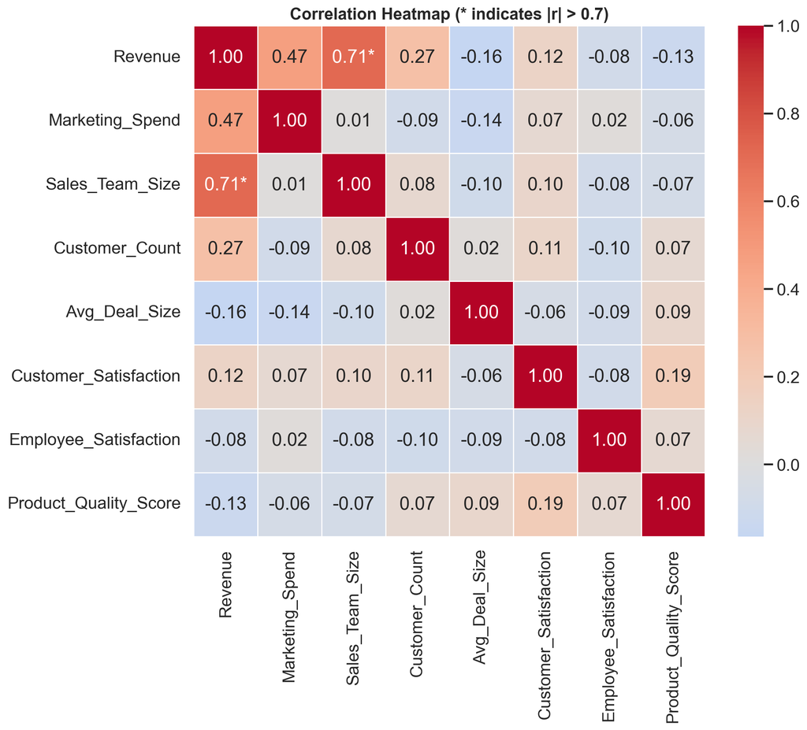

```python
# Create custom annotations to highlight strong correlations
annot_array = corr_matrix.values.copy()
annotations = []

for i in range(len(annot_array)):
    row_annot = []
    for j in range(len(annot_array[i])):
        val = annot_array[i, j]
        if abs(val) > 0.7 and i != j:  # Strong correlation, not diagonal
            row_annot.append(f'{val:.2f}*')  # Add asterisk
        else:
            row_annot.append(f'{val:.2f}')
    annotations.append(row_annot)

fig, ax = plt.subplots(figsize=(12, 10))

sns.heatmap(corr_matrix,
            annot=np.array(annotations),
            fmt='',  # Don't format, we already did
            cmap='coolwarm',
            center=0,
            square=True,
            linewidths=1,
            ax=ax)

ax.set_title('Correlation Heatmap (* indicates |r| > 0.7)',
             fontsize=16, fontweight='bold')

plt.tight_layout()
plt.show()
```

**Output:**

*[Heatmap: “Correlation Heatmap (* indicates |r| > 0.7)”]*

**Pivot Table Heatmaps - Two-Way Categorical Analysis**

**Beyond Correlation - Categorical Relationships:**

Heatmaps aren’t just for correlations. They excel at showing **values across two categorical dimensions**:

- Average sales by Region × Quarter
- Customer count by Segment × Industry
- Satisfaction scores by Department × Tenure

**Creating Pivot Table Heatmaps:**

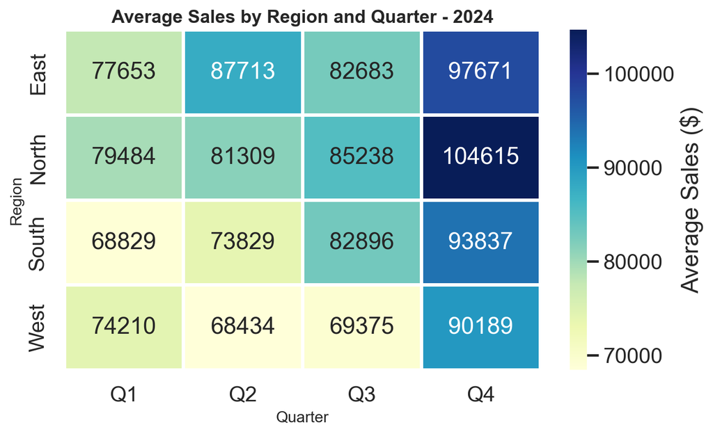

```python
import seaborn as sns
import matplotlib.pyplot as plt
import pandas as pd
import numpy as np

# Generate sales data by region and quarter
np.random.seed(42)

regions = ['North', 'South', 'East', 'West']
quarters = ['Q1', 'Q2', 'Q3', 'Q4']

data_list = []
for region in regions:
    for quarter in quarters:
        # Different regions have different patterns
        if region == 'East':
            base = 85000
        elif region == 'West':
            base = 78000
        elif region == 'North':
            base = 82000
        else:
            base = 75000

        # Seasonal variation by quarter
        if quarter == 'Q4':
            seasonal = 15000  # Holiday boost
        elif quarter == 'Q1':
            seasonal = -5000  # Post-holiday slump
        else:
            seasonal = 0

        sales = base + seasonal + np.random.normal(0, 5000)
        data_list.append({
            'Region': region,
            'Quarter': quarter,
            'Sales': sales
        })

df_sales = pd.DataFrame(data_list)

# Create pivot table
pivot_table = df_sales.pivot_table(values='Sales',
                                    index='Region',
                                    columns='Quarter',
                                    aggfunc='mean')

# Create heatmap
fig, ax = plt.subplots(figsize=(8, 5))

sns.heatmap(pivot_table,
            annot=True,
            fmt='.0f',  # No decimals for currency
            cmap='YlGnBu',  # Yellow to Green to Blue
            linewidths=2,
            linecolor='white',
            cbar_kws={'label': 'Average Sales ($)'},
            ax=ax)

ax.set_title('Average Sales by Region and Quarter - 2024',
             fontsize=14, fontweight='bold')
ax.set_xlabel('Quarter', fontsize=12)
ax.set_ylabel('Region', fontsize=12)

plt.tight_layout()
plt.show()
```

**Output:**

*[Heatmap: “Average Sales by Region and Quarter - 2024”, x: Quarter, y: Region]*

**Reading Two-Way Heatmaps:**

**Hotspots (Darker colors):**

**Cold spots (Lighter colors):**

**Patterns:**

**Business Actions:**

**Clustermaps - Discovering Hidden Groupings**

**The Pattern Recognition Problem:**

Sometimes relationships aren’t obvious from raw order. Clustermaps **automatically reorder** rows and columns to group similar variables together.

**What Clustermaps Reveal:**

- Which variables behave similarly
- Natural groupings in your metrics
- Redundant variables (measure same thing)
- Hierarchical relationships

**Creating a Clustermap:**

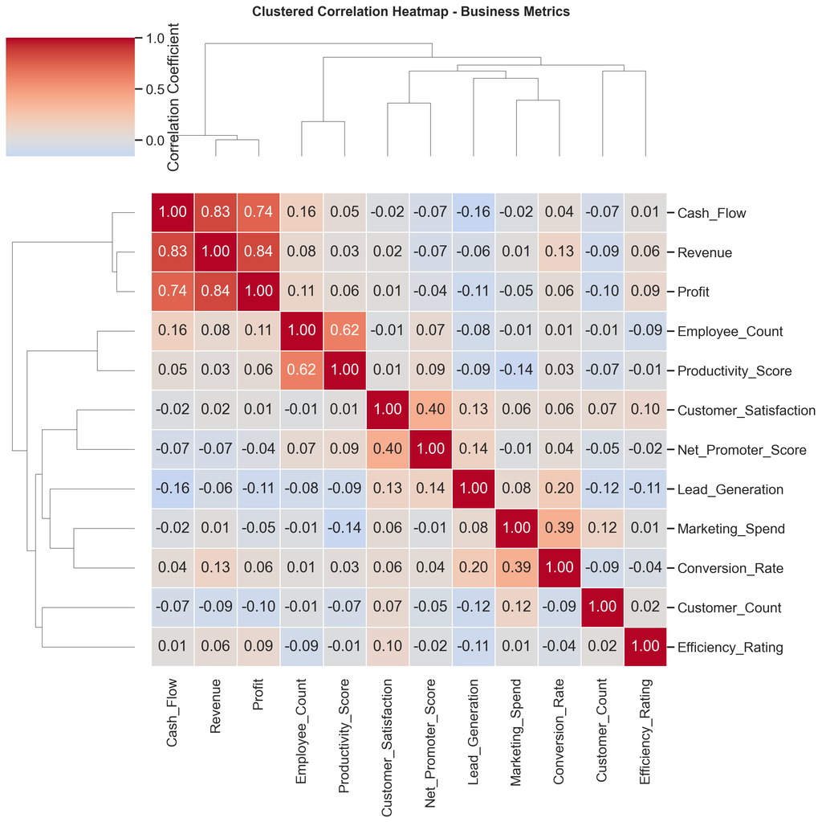

```python
import seaborn as sns
import matplotlib.pyplot as plt
import pandas as pd
import numpy as np

# Generate diverse business metrics
np.random.seed(42)
n = 150

df = pd.DataFrame({
    # Financial metrics (should cluster)
    'Revenue': np.random.normal(100000, 20000, n),
    'Profit': np.random.normal(25000, 8000, n),
    'Cash_Flow': np.random.normal(30000, 10000, n),

    # Customer metrics (should cluster)
    'Customer_Count': np.random.poisson(200, n),
    'Customer_Satisfaction': np.random.uniform(3.5, 5.0, n),
    'Net_Promoter_Score': np.random.normal(45, 15, n),

    # Operational metrics (should cluster)
    'Employee_Count': np.random.randint(20, 100, n),
    'Productivity_Score': np.random.normal(75, 12, n),
    'Efficiency_Rating': np.random.uniform(65, 95, n),

    # Marketing metrics (should cluster)
    'Marketing_Spend': np.random.normal(15000, 5000, n),
    'Lead_Generation': np.random.poisson(50, n),
    'Conversion_Rate': np.random.uniform(0.15, 0.35, n)
})

# Create realistic relationships within clusters
df['Profit'] = 0.25 * df['Revenue'] + np.random.normal(0, 3000, n)
df['Cash_Flow'] = 0.30 * df['Revenue'] + np.random.normal(0, 4000, n)
df['Net_Promoter_Score'] = 20 + 6 * df['Customer_Satisfaction'] + np.random.normal(0, 5, n)
df['Productivity_Score'] = 50 + 0.25 * df['Employee_Count'] + np.random.normal(0, 8, n)
df['Conversion_Rate'] = 0.15 + 0.000003 * df['Marketing_Spend'] + np.random.normal(0, 0.03, n)

# Calculate correlation
corr_matrix = df.corr()

# Create clustermap
g = sns.clustermap(corr_matrix,
                   annot=True,
                   fmt='.2f',
                   cmap='coolwarm',
                   center=0,
                   figsize=(14, 14),
                   linewidths=0.5,
                   cbar_kws={'label': 'Correlation Coefficient'})

g.fig.suptitle('Clustered Correlation Heatmap - Business Metrics',
               fontsize=16, fontweight='bold', y=0.98)

plt.tight_layout()
plt.show()
```

**Output:**

*[Cluster heatmap: “Clustered Correlation Heatmap - Business Metrics”]*

**Reading a Clustermap:**

**Dendrograms (Tree structures on sides):**

- Show how variables are grouped
- Shorter branches = more similar
- Longer branches = less similar

**Reordered Matrix:**

- Variables automatically rearranged
- Similar variables placed adjacent
- Reveals natural groupings

**Business Insights from Clusters:**

**Cluster 1: Financial Metrics**

- Revenue, Profit, Cash_Flow group together
- **Insight**: These move together (as expected)
- **Action**: Can use Revenue as proxy for financial health

**Cluster 2: Customer Metrics**

**Cluster 3: Operational Metrics**

- Employee_Count, Productivity separate from others
- **Insight**: Operations independent of customer metrics
- **Question**: Should they be? Investigate connection

**Multicollinearity and Variable Selection**

**The Redundancy Problem:**

In predictive modeling or analysis, highly correlated independent variables cause problems:

- **Multicollinearity**: When predictors correlate with each other
- **Result**: Unstable models, unclear which variable matters
- **Solution**: Remove redundant variables

**Using Heatmaps to Identify Redundancy:**

```python
# Identify highly correlated variable pairs (excluding diagonal)
high_corr_pairs = []
threshold = 0.85

for i in range(len(corr_matrix.columns)):
    for j in range(i+1, len(corr_matrix.columns)):
        if abs(corr_matrix.iloc[i, j]) >= threshold:
            high_corr_pairs.append({
                'Variable 1': corr_matrix.columns[i],
                'Variable 2': corr_matrix.columns[j],
                'Correlation': corr_matrix.iloc[i, j]
            })

df_high_corr = pd.DataFrame(high_corr_pairs)
print("\nHighly Correlated Variable Pairs (|r| >= 0.85):")
print(df_high_corr)
```

```
Highly Correlated Variable Pairs (|r| >= 0.85):
Empty DataFrame
Columns: []
Index: []
```

**Output:**

```
Highly Correlated Variable Pairs (|r| >= 0.85):
Empty DataFrame
Columns: []
Index: []
```

**Business Decision Framework:**

If Revenue and Cash_Flow correlate at r=0.92: 1. **Keep one, drop the other** for modeling 2. **Which to keep?** - The one easier to measure - The one more relevant to the business question - The one with less measurement error

**Example:**

**Color Scheme Selection for Different Contexts**

**Choosing the Right Colors Matters:**

Different data types and questions require different color schemes:

**Diverging (Best for Correlations):**

```python
# Data centered at 0, both positive and negative values
cmap='coolwarm'  # Blue (negative) → White (zero) → Red (positive)
cmap='RdBu_r'    # Red → Blue reversed
cmap='PiYG'      # Pink → Yellow → Green
```

**Sequential (Best for One-directional Values):**

```python
# All positive values, low to high
cmap='YlGnBu'    # Yellow → Green → Blue
cmap='Blues'     # Light blue → Dark blue
cmap='Reds'      # Light red → Dark red
```

**Qualitative (Best for Categories):**

```python
# Distinct categories, no order
cmap='Set1'
cmap='Set2'
cmap='tab10'
```

**Business Context Examples:**

**Financial Performance (diverging):**

- Negative (loss) = Red
- Zero (break-even) = White
- Positive (profit) = Green

```python
cmap='RdYlGn'  # Red-Yellow-Green
```

**Sales Performance (sequential):**

- All positive values
- Low = Light, High = Dark

```python
cmap='YlOrRd'  # Yellow-Orange-Red (heat map feel)
```

**Customer Satisfaction (sequential):**

- All positive (1-5 scale)
- Low satisfaction = Red, High = Green

```python
cmap='RdYlGn'  # But not centered at 0, normalized to data range
```

### 3.4.3 Lab Session

**Lab 4: Correlation and Heatmap Analysis**

**Objective:** Master correlation analysis and heatmap visualization to uncover complex relationships in multivariate business data and communicate insights through color-coded matrices.

**Scenario:** You’re the Senior Data Analyst at “MarketPro Analytics,” a marketing analytics firm. Your client, a major e-commerce company, has provided comprehensive data on their operations. The CMO is struggling to understand which metrics drive success and where to focus improvement efforts. Your task is to create correlation analyses and heatmaps that reveal the hidden relationships in their complex business data and provide clear, actionable insights for strategic planning.

**Pre-Lab Setup:**

1. Create file: `M3L04_YourName_Heatmaps.py`
2. Import and configure:

```python
import seaborn as sns
import matplotlib.pyplot as plt
import pandas as pd
import numpy as np

sns.set_theme(style="white", context="talk")
```

3. Create output folder: “Lab4_Outputs”

**Part A: Comprehensive Business Metrics Correlation Analysis (30 points)**

**Context:** The client wants to understand how their various business metrics relate to each other to identify key drivers of success.

**Data:**

```python
np.random.seed(42)
n = 250  # 250 days of data

# Generate comprehensive e-commerce metrics
df_metrics = pd.DataFrame({
    'Daily_Revenue': np.random.normal(50000, 12000, n),
    'Website_Traffic': np.random.poisson(15000, n),
    'Conversion_Rate': np.random.uniform(0.02, 0.08, n),
    'Avg_Order_Value': np.random.normal(85, 20, n),
    'Marketing_Spend': np.random.normal(3000, 800, n),
    'Email_Open_Rate': np.random.uniform(0.15, 0.35, n),
    'Social_Media_Engagement': np.random.poisson(500, n),
    'Customer_Service_Tickets': np.random.poisson(45, n),
    'Product_Returns': np.random.poisson(25, n),
    'Page_Load_Time': np.random.uniform(1.5, 4.5, n),
    'Mobile_Traffic_Pct': np.random.uniform(0.45, 0.75, n),
    'Customer_Satisfaction': np.random.uniform(3.8, 4.8, n)
})

# Create realistic relationships
df_metrics['Daily_Revenue'] = (
    10000 +
    1.8 * df_metrics['Website_Traffic'] +
    200000 * df_metrics['Conversion_Rate'] +
    300 * df_metrics['Avg_Order_Value'] +
    2.5 * df_metrics['Marketing_Spend'] +
    -2000 * df_metrics['Page_Load_Time'] +
    np.random.normal(0, 5000, n)
)

df_metrics['Conversion_Rate'] = (
    0.03 +
    0.00000015 * df_metrics['Website_Traffic'] +
    0.01 * df_metrics['Email_Open_Rate'] +
    -0.003 * df_metrics['Page_Load_Time'] +
    0.002 * df_metrics['Customer_Satisfaction'] +
    np.random.normal(0, 0.005, n)
)
df_metrics['Conversion_Rate'] = df_metrics['Conversion_Rate'].clip(0.01, 0.10)

df_metrics['Customer_Satisfaction'] = (
    3.0 +
    0.3 * (5 - df_metrics['Page_Load_Time']) +
    -0.015 * df_metrics['Customer_Service_Tickets'] +
    -0.020 * df_metrics['Product_Returns'] +
    np.random.normal(0, 0.2, n)
)
df_metrics['Customer_Satisfaction'] = df_metrics['Customer_Satisfaction'].clip(1, 5)
```

**Tasks:**

1. **Create comprehensive correlation heatmap (12 points):**
   - Calculate full correlation matrix
   - Figure size: (16, 14)
   - Use ‘coolwarm’ colormap centered at 0
   - Annotate with correlation values (2 decimals)
   - Square cells with white lines (linewidth=1)
   - Add colorbar with label “Correlation Coefficient”
   - Title: “E-Commerce Business Metrics - Correlation Analysis”
   - Make text readable (appropriate font sizes)
2. **Create lower triangle version (8 points):**
   - Same heatmap but mask upper triangle
   - Eliminates redundancy
   - Cleaner professional appearance
   - Save as: `M3L04_YourName_FullCorrelation.png` (full) and `M3L04_YourName_LowerTriangle.png` (masked)
3. **Identify and document key insights (10 points):**
   - Find the THREE strongest positive correlations (excluding diagonal)
   - Find the THREE strongest negative correlations
   - Create a summary report in comments:
     - List these correlations with values
     - Explain what each relationship means for business
     - Identify surprising or counter-intuitive findings
     - Recommend which metrics to focus on for improving revenue
     - Identify any potential multicollinearity issues (r > 0.85)

**Part B: Revenue Driver Deep Dive (25 points)**

**Context:** The CMO specifically wants to know which factors most strongly influence revenue. Create a focused analysis on revenue correlations.

**Tasks:**

1. **Create revenue-focused correlation visualization (15 points):**
   - Extract correlations of all variables with ‘Daily_Revenue’
   - Create a horizontal bar plot showing these correlations
   - Sort by correlation strength (highest to lowest by absolute value)
   - Color bars: Green for positive, Red for negative
   - Figure size: (12, 8)
   - Title: “Revenue Correlation Analysis - Key Drivers Identified”
   - Add vertical reference lines at -0.3, 0, +0.3, +0.6 (weak, none, moderate, strong thresholds)
   - Annotate bars with correlation values
2. **Statistical significance and interpretation (10 points):**
   - Calculate correlation with p-values using scipy.stats.pearsonr
   - In comments, document:
     - Top 3 revenue drivers (highest positive correlations)
     - Whether these correlations are statistically significant (p < 0.05)
     - Which metrics have surprisingly weak correlation with revenue
     - Actionable recommendations for increasing revenue based on findings
   - Create a text annotation on the plot highlighting the #1 revenue driver
   - Save as: `M3L04_YourName_RevenueDrivers.png`

**Part C: Marketing Performance Pivot Heatmap (25 points)**

**Context:** The marketing team runs campaigns across different channels (Email, Social, PPC, Display) in different customer segments (New, Returning, VIP). They need to see performance by Channel × Segment.

**Data:**

```python
np.random.seed(42)

channels = ['Email', 'Social Media', 'PPC', 'Display Ads']
segments = ['New Customers', 'Returning', 'VIP']

marketing_data = []
for channel in channels:
    for segment in segments:
        # Different channels perform differently with different segments
        if channel == 'Email' and segment == 'VIP':
            roi = np.random.normal(4.5, 0.5, 30)  # Email works great for VIP
        elif channel == 'Social Media' and segment == 'New Customers':
            roi = np.random.normal(3.8, 0.6, 30)  # Social good for acquisition
        elif channel == 'PPC' and segment == 'Returning':
            roi = np.random.normal(3.5, 0.4, 30)
        elif channel == 'Display Ads':
            roi = np.random.normal(2.2, 0.5, 30)  # Display generally weaker
        else:
            roi = np.random.normal(3.0, 0.5, 30)

        for r in roi:
            marketing_data.append({
                'Channel': channel,
                'Segment': segment,
                'ROI': max(r, 0.5)  # Ensure positive ROI
            })

df_marketing = pd.DataFrame(marketing_data)
```

**Tasks:**

1. **Create pivot table heatmap (15 points):**
   - Pivot: Channels as rows, Segments as columns, Average ROI as values
   - Figure size: (10, 6)
   - Use ‘RdYlGn’ colormap (Red=low, Yellow=medium, Green=high)
   - Annotate with ROI values (1 decimal place)
   - Add colorbar labeled “Average ROI ($return per $1 spent)”
   - Title: “Marketing ROI by Channel and Customer Segment”
   - Thick white lines between cells (linewidth=2)
2. **Add conditional formatting context (5 points):**
   - Calculate overall average ROI
   - Add subtitle text below title: “Overall Average ROI: $X.XX”
   - In annotations, mark cells with * if ROI > overall average + 0.5
   - This highlights exceptional performance
3. **Business recommendations (5 points):**
   - In code comments, identify:
     - Best performing Channel-Segment combination
     - Worst performing combination
     - Where to increase marketing budget
     - Where to decrease or eliminate spending
     - Unexpected patterns or opportunities
   - Save as: `M3L04_YourName_MarketingROI.png`

**Part D: Customer Behavior Clustermap (20 points)**

**Context:** The product team has metrics on customer behavior but doesn’t know which behaviors cluster together or which customer segments behave similarly.

**Data:**

```python
np.random.seed(42)

# Customer behavior metrics
behaviors = pd.DataFrame({
    'Purchase_Frequency': np.random.gamma(2, 2, 200),
    'Avg_Session_Duration': np.random.normal(8, 3, 200),
    'Pages_Per_Session': np.random.poisson(5, 200),
    'Cart_Abandonment_Rate': np.random.uniform(0.3, 0.8, 200),
    'Wishlist_Usage': np.random.poisson(3, 200),
    'Review_Activity': np.random.poisson(2, 200),
    'Social_Shares': np.random.poisson(1, 200),
    'Coupon_Usage_Rate': np.random.uniform(0.1, 0.6, 200),
    'Customer_Service_Contact': np.random.poisson(1, 200),
    'Mobile_App_Usage': np.random.uniform(0.2, 0.9, 200)
})

# Create some natural relationships
behaviors['Purchase_Frequency'] = (
    behaviors['Purchase_Frequency'] *
    (1 + 0.3 * behaviors['Wishlist_Usage'] / behaviors['Wishlist_Usage'].max())
)

behaviors['Review_Activity'] = (
    behaviors['Review_Activity'] +
    0.3 * behaviors['Purchase_Frequency']
)

behaviors['Social_Shares'] = (
    behaviors['Social_Shares'] +
    0.5 * behaviors['Review_Activity']
)

df_behaviors = behaviors
```

**Tasks:**

1. **Create clustermap (15 points):**
   - Calculate correlation matrix
   - Create clustermap with:
     - Figure size: (14, 14)
     - ‘coolwarm’ colormap centered at 0
     - Annotations (2 decimals)
     - Appropriate dendrogram ratio
   - Title: “Customer Behavior Clustering Analysis”
   - Both row and column clustering enabled
2. **Interpret clusters (5 points):**
   - In detailed comments, identify:
     - How many natural behavior clusters exist?
     - Which behaviors group together? (Name the clusters meaningfully)
     - Example: “Engagement Cluster: Review_Activity, Social_Shares, Wishlist_Usage”
     - Which behaviors are independent/isolated?
     - What do these clusters tell us about customer types?
     - How can marketing use this segmentation?
   - Save as: `M3L04_YourName_BehaviorClustermap.png`

**Bonus Challenge (+30 points):**

**Create a Comprehensive Executive Dashboard with Multiple Heatmaps:**

Build a figure with 4 subplots (2×2) showing:

1. **Top-left: Correlation heatmap of top 6 business metrics**
   - Select the 6 most important metrics
   - Lower triangle only
   - Highlight strong correlations
2. **Top-right: Time series heatmap**
   - Create data: Metrics (rows) × Weeks (columns)
   - Show how metrics evolved over 12 weeks
   - Use sequential colormap
3. **Bottom-left: Comparison heatmap**
   - This Year vs Last Year performance
   - Metrics as rows, Year as columns
   - Show % change with diverging colors
4. **Bottom-right: Priority matrix**
   - Impact (Low/Medium/High) × Effort (Low/Medium/High)
   - Place top 9 initiatives in appropriate cells
   - Color by priority level

**Requirements:**

- Figure size: (20, 18)
- Consistent, professional styling
- Overall title: “MarketPro Analytics - Executive Dashboard”
- Each subplot clearly labeled
- Annotations where appropriate
- Color schemes selected for context
- Save as: `M3L04_YourName_ExecutiveDashboard.png`

**Deliverables:**

1. Python file: `M3L04_YourName_Heatmaps.py`
2. PNG files (minimum 5):
   - `M3L04_YourName_FullCorrelation.png`
   - `M3L04_YourName_LowerTriangle.png`
   - `M3L04_YourName_RevenueDrivers.png`
   - `M3L04_YourName_MarketingROI.png`
   - `M3L04_YourName_BehaviorClustermap.png`
   - `M3L04_YourName_ExecutiveDashboard.png` (bonus)

**Grading Rubric:**

- Part A (Correlation Analysis): 30 points
- Part B (Revenue Drivers): 25 points
- Part C (Marketing Pivot): 25 points
- Part D (Clustermap): 20 points
- Bonus (Dashboard): +30 points

**Success Criteria:**

- Correlation values calculated correctly
- Appropriate color schemes selected for data context
- Annotations clear and readable
- Business insights documented in detail
- Multicollinearity issues identified
- Clustermaps reveal meaningful groupings
- Pivot heatmaps show actionable patterns
- All visualizations properly labeled with titles and colorbars
- High-resolution professional outputs

**Heatmap Best Practices Checklist:**

- Choose colormap appropriate for data type (diverging vs sequential)
- Center diverging colormaps at meaningful value (usually 0)
- Always annotate correlation heatmaps with values
- Use appropriate number formats (correlations: .2f, money: .0f)
- Include colorbar with descriptive label
- Make cells square for easier reading
- Use lines between cells for clarity
- Consider masking upper triangle for correlations
- Ensure text is readable (font size, contrast)
- Add meaningful titles that explain what’s shown

**Common Mistakes to Avoid:**

- Using rainbow/jet colormap (not perceptually uniform)
- Forgetting to center diverging colormaps
- Too many variables (>15 becomes unreadable)
- Poor color contrast with annotations
- Missing colorbar or unlabeled colorbar
- Not interpreting business meaning of correlations
- Confusing correlation with causation
- Ignoring statistical significance

**Professional Tips:**

- Strong correlation doesn’t mean causation
- Always consider lag effects (marketing → sales may take time)
- Look for unexpected weak correlations (why isn’t X related to Y?)
- Use clustermaps to discover natural groupings
- Pivot heatmaps excellent for two-way categorical analysis
- Document threshold for “strong” correlation in your context
- Consider removing redundant highly-correlated variables for modeling

**End of Module 3: Statistical Visualization with Seaborn**

**Key Takeaways:**

- Seaborn provides high-level statistical visualizations with beautiful defaults
- Distribution plots (histogram, KDE, box, violin) reveal data characteristics
- Relationship plots (scatter with regression, joint, pair) uncover correlations
- Categorical plots (count, bar, box, violin, point) compare groups effectively
- Heatmaps and clustermaps visualize multivariate relationships compactly
- Always interpret statistical findings in business context
- Correlation does not imply causation

# 4 Module 4: Interactive Visualization with Plotly

## 4.1 Section 1: Introduction to Plotly and Interactive Charts

### 4.1.1 Objective

- Understand the advantages of interactive visualizations for business
- Master Plotly’s architecture and syntax differences from Matplotlib
- Create basic interactive plots: scatter, line, and bar charts
- Implement hover information and zoom capabilities
- Customize interactive elements for professional presentations
- Export interactive visualizations for web and reports

### 4.1.2 Main Contents with Examples

**Why Interactive Visualizations Transform Business Communication**

**The Limitation of Static Charts:**

In Modules 2 and 3, we created beautiful static visualizations with Matplotlib and Seaborn. But static charts have inherent limitations:

- **Fixed perspective**: Shows only one view of the data
- **Information overload**: Must include all details upfront (cluttered)
- **No exploration**: Viewers can’t dig deeper into interesting patterns
- **Print-focused**: Designed for paper, not screens

**The Interactive Advantage:**

Interactive visualizations solve these problems:

**1. Progressive Disclosure:**

- Start with overview
- Users drill down into areas of interest
- Hover reveals details on demand
- Zoom focuses on specific regions

**2. Enhanced Engagement:**

- Users actively explore data
- Discover insights themselves
- Memorable and impactful
- Encourages questions and discussion

**3. Richer Information:**

- Pack more data without clutter
- Multiple metrics in one chart
- Time series with range selection
- Multi-dimensional views

**Business Impact Examples:**

**Sales Dashboard (Static):**

- Shows 12 months of sales
- Can’t see daily fluctuations
- Questions require new charts

**Sales Dashboard (Interactive):**

- Click-drag to zoom into specific weeks
- Hover to see exact daily values
- Click legend to hide/show regions
- Export filtered view for reports

**Result**: Executives answer their own questions in real-time during presentations.

**Understanding Plotly - The Interactive Visualization Library**

**What is Plotly?**

Plotly is a graphing library that creates interactive, web-based visualizations:

- Built on **D3.js** and **JavaScript** (web standard)
- Python API (plotly.py) for easy creation
- Outputs **HTML** files viewable in any browser
- Hosted online or embedded in applications

**Plotly Versions:**

**1. Plotly Express (px) - High-Level API:**

```python
import plotly.express as px
df = pd.DataFrame({
    'sales': np.random.uniform(10000, 100000, 50),
    'profit': np.random.uniform(1000, 20000, 50)
})
# Simple, concise, opinionated
fig = px.scatter(df, x='sales', y='profit')
fig.show()
```

[interactive chart not shown]

**Output:**

*[Interactive scatter plot: x: sales, y: profit]* - **Best for**: Quick exploration, standard charts - **Advantages**: One-line plots, automatic styling - **Used when**: Learning, rapid prototyping

**2. Plotly Graph Objects (go) - Low-Level API:**

```python
import plotly.graph_objects as go
# Detailed control, more verbose
fig = go.Figure(data=[go.Scatter(x=df['sales'], y=df['profit'])])
fig.show()
```

[interactive chart not shown]

**Output:**

*[Interactive Plotly chart]* - **Best for**: Custom visualizations, fine control - **Advantages**: Complete flexibility - **Used when**: Specific requirements, complex layouts

**We’ll focus primarily on Plotly Express** (easier to learn, covers 90% of business needs).

**Installation Check:**

```python
import plotly
print(plotly.__version__)  # Should be 5.x or higher
```

```
5.22.0
```

If not installed:

```
pip install plotly
```

**Your First Interactive Chart - The Plotly Workflow**

**Understanding the Fundamental Difference:**

**Matplotlib/Seaborn workflow:**

1. Create figure and axes
2. Add data
3. Customize
4. Show or save as PNG/PDF

**Plotly workflow:**

1. Create figure with data
2. Customize (optional)
3. Show in browser OR save as HTML

**Creating a Simple Interactive Scatter Plot:**

```python
import plotly.express as px
import pandas as pd
import numpy as np

# Sample business data: Marketing spend vs Revenue
np.random.seed(42)
df = pd.DataFrame({
    'marketing_spend': np.random.uniform(5000, 50000, 100),
    'revenue': np.random.uniform(50000, 500000, 100),
    'region': np.random.choice(['North', 'South', 'East', 'West'], 100),
    'quarter': np.random.choice(['Q1', 'Q2', 'Q3', 'Q4'], 100)
})

# Add realistic relationship
df['revenue'] = 30000 + 6 * df['marketing_spend'] + np.random.normal(0, 30000, 100)

# Create interactive scatter plot
fig = px.scatter(df,
                 x='marketing_spend',
                 y='revenue',
                 title='Marketing Spend vs Revenue Analysis')

# Display in browser
fig.show()
```

[interactive chart not shown]

**Output:**

*[Interactive scatter plot: “Marketing Spend vs Revenue Analysis”, x: marketing_spend, y: revenue]*

**What Just Happened:**

When you run `fig.show()`:

1. Plotly generates an HTML file
2. Opens it in your default browser
3. You see an interactive chart with:
   - **Hover**: Move mouse over points to see values
   - **Zoom**: Click-drag to zoom into areas
   - **Pan**: Shift-click-drag to move around
   - **Reset**: Double-click to reset view
   - **Toolbar**: Top-right corner with tools

**The Magic of Interactivity:**

Try these interactions:

- **Hover over any point**: See exact marketing_spend and revenue values
- **Click-drag across interesting region**: Zoom in
- **Double-click**: Zoom back out
- **Click camera icon**: Download as PNG

No additional code needed - interactivity is automatic!

**Customizing Hover Information**

**The Default Hover is Good, But We Can Do Better:**

Default hover shows:

- Variable names (marketing_spend, revenue)
- Values

Professional hover should show:

- Formatted numbers ($50,000 not 50000)
- Additional context (Region, Quarter)
- Readable labels (“Marketing Spend” not “marketing_spend”)

**Enhanced Hover with Custom Text:**

```python
import plotly.express as px
import pandas as pd
import numpy as np

# Same data as before
np.random.seed(42)
df = pd.DataFrame({
    'marketing_spend': np.random.uniform(5000, 50000, 100),
    'revenue': np.random.uniform(50000, 500000, 100),
    'region': np.random.choice(['North', 'South', 'East', 'West'], 100),
    'quarter': np.random.choice(['Q1', 'Q2', 'Q3', 'Q4'], 100),
    'campaign': [f'Campaign {i}' for i in range(100)]
})

df['revenue'] = 30000 + 6 * df['marketing_spend'] + np.random.normal(0, 30000, 100)

# Create hover template
fig = px.scatter(df,
                 x='marketing_spend',
                 y='revenue',
                 color='region',  # Color by region
                 hover_data=['quarter', 'campaign'],  # Additional info
                 title='Marketing ROI Analysis by Region')

# Update labels for readability
fig.update_layout(
    xaxis_title='Marketing Spend ($)',
    yaxis_title='Revenue Generated ($)',
    font=dict(size=12)
)

# Format hover to show currency
fig.update_traces(
    hovertemplate='<b>%{fullData.name}</b><br>' +
                  'Marketing: $%{x:,.0f}<br>' +
                  'Revenue: $%{y:,.0f}<br>' +
                  '<extra></extra>'
)

fig.show()
```

[interactive chart not shown]

**Output:**

*[Interactive scatter plot: “Marketing ROI Analysis by Region”, x: marketing_spend, y: revenue]*

**Understanding Hover Customization:**

**hover_data parameter:**

- List of additional columns to show on hover
- Example: `['quarter', 'campaign']`
- Shows these fields without needing to map to x or y

**hovertemplate:**

```
- Custom HTML-like template
- **%{x}**: X-axis value
- **%{y}**: Y-axis value
- **:,.0f**: Format as number with commas, 0 decimals
- **<b>...</b>**: Bold text
- **<br>**: Line break
- **<extra></extra>**: Remove default trace info
```

**Creating Interactive Line Charts**

**Time Series with Interactive Features:**

Line charts are perfect for exploring temporal patterns interactively.

```python
import plotly.express as px
import pandas as pd
import numpy as np

# Generate monthly revenue data for 3 years
np.random.seed(42)
dates = pd.date_range('2022-01-01', '2024-12-31', freq='D')

df_revenue = pd.DataFrame({
    'date': dates,
    'revenue': np.random.normal(100000, 15000, len(dates)),
    'region': np.random.choice(['North', 'South', 'East'], len(dates))
})

# Add trend and seasonality
df_revenue['revenue'] = (
    80000 +
    (df_revenue.index * 30) +  # Growth trend
    20000 * np.sin(df_revenue.index / 365 * 2 * np.pi) +  # Yearly seasonality
    df_revenue['revenue'] * 0.2
)

# Aggregate by month and region
df_monthly = df_revenue.groupby([pd.Grouper(key='date', freq='M'), 'region'])['revenue'].sum().reset_index()

# Create interactive line chart
fig = px.line(df_monthly,
              x='date',
              y='revenue',
              color='region',
              title='Monthly Revenue Trends by Region (2022-2024)',
              labels={'revenue': 'Monthly Revenue ($)', 'date': 'Month'})

# Enhance layout
fig.update_layout(
    hovermode='x unified',  # Show all series at once when hovering
    xaxis=dict(
        rangeslider=dict(visible=True),  # Add range slider
        type='date'
    ),
    yaxis=dict(
        tickformat='$,.0f'  # Format Y-axis as currency
    ),
    legend=dict(
        title='Region',
        yanchor='top',
        y=0.99,
        xanchor='right',
        x=0.99
    )
)

fig.show()
```

[interactive chart not shown]

**Output:**

**Interactive Features Explained:**

**1. Range Slider (rangeslider):**

- Appears below the chart
- Drag handles to select time range
- Chart auto-updates to show selected period
- Perfect for long time series (years of data)

**2. Hover Mode ‘x unified’:**

- Hover over any point on X-axis
- Shows values for ALL series at that X
- Compare multiple lines simultaneously
- Essential for multi-line charts

**3. Legend Interaction:**

- Click region name to hide/show
- Double-click to isolate one region
- Perfect for comparing specific series

**Business Use Case:**

Executive asks: “Did the South region dip in Q3 2023?”

- Click-drag range slider to Q3 2023
- Hover over September 2023
- See all three regions’ values
- Answer immediately: “Yes, South dropped 15% while others remained stable”

**Interactive Bar Charts with Drill-Down**

**Bar Charts with Rich Context:**

```python
import plotly.express as px
import pandas as pd
import numpy as np

# Product category sales data
np.random.seed(42)
categories = ['Electronics', 'Clothing', 'Home Goods', 'Sports', 'Books', 'Toys']

df_sales = pd.DataFrame({
    'category': categories,
    'q1_sales': np.random.uniform(200000, 500000, len(categories)),
    'q2_sales': np.random.uniform(250000, 550000, len(categories)),
    'q3_sales': np.random.uniform(230000, 520000, len(categories)),
    'q4_sales': np.random.uniform(300000, 600000, len(categories)),
    'units_sold': np.random.randint(5000, 25000, len(categories)),
    'avg_rating': np.random.uniform(3.8, 4.8, len(categories))
})

df_sales['total_sales'] = (df_sales['q1_sales'] + df_sales['q2_sales'] +
                            df_sales['q3_sales'] + df_sales['q4_sales'])

# Sort by total sales
df_sales = df_sales.sort_values('total_sales', ascending=True)

# Create horizontal bar chart
fig = px.bar(df_sales,
             y='category',
             x='total_sales',
             orientation='h',
             title='Annual Sales by Product Category - 2024',
             labels={'total_sales': 'Total Annual Sales ($)', 'category': ''},
             hover_data={
                 'total_sales': ':$,.0f',
                 'units_sold': ':,.0f',
                 'avg_rating': ':.1f'
             },
             color='total_sales',
             color_continuous_scale='Blues')

# Customize layout
fig.update_layout(
    showlegend=False,
    xaxis=dict(
        title='Annual Sales',
        tickformat='$,.0f',
        showgrid=True,
        gridcolor='lightgray'
    ),
    yaxis=dict(
        title=''
    ),
    height=500,
    coloraxis_colorbar=dict(
        title='Sales ($)',
        tickformat='$,.0f'
    )
)

fig.show()
```

[interactive chart not shown]

**Output:**

*[Interactive bar chart: “Annual Sales by Product Category - 2024”, x: total_sales, y: category]*

**Advanced Hover Formatting:**

In `hover_data`:

- **Dictionary format**: `{column: format_string}`
- **‘:$,.0f’**: Dollar sign, comma separator, no decimals
- **‘:,.0f’**: Comma separator, no decimals
- **‘:.1f’**: One decimal place
- **‘:.2%’**: Percentage with 2 decimals

**Color Scales:**

- Single color intensifies with value
- Shows magnitude visually
- Popular scales: ‘Blues’, ‘Reds’, ‘Greens’, ‘Viridis’, ‘Plasma’

**Saving and Sharing Interactive Visualizations**

**Export Options:**

**1. HTML (Interactive):**

```python
fig.write_html('M4L01_Interactive_Sales.html')
```

**Output:**

*[Chart]* - Fully interactive - Opens in any browser - Can be shared via email - Embeds in websites - File size: Usually 500KB - 2MB

**2. Static Image (Non-Interactive):**

```python
fig.write_image('M4L01_Sales_Chart.png', width=1200, height=800)
```

- Requires: `pip install kaleido`
- Standard PNG/PDF/SVG
- For print reports
- Loses interactivity

**3. For Presentations:**

```python
# Higher quality for projection
fig.write_image('M4L01_Presentation.png', width=1920, height=1080, scale=2)
```

**Embedding in Reports:**

Interactive HTML charts can be embedded in:

- **Jupyter notebooks**: Displays inline automatically
- **Web applications**: Iframe or direct embed
- **Confluence/SharePoint**: Upload HTML, link in document
- **Email**: Attach HTML file (recipients open in browser)

**Plotly Express vs Graph Objects - When to Use Each**

**Quick Reference:**

**Use Plotly Express when:**

- Creating standard chart types (scatter, line, bar, histogram)
- Quick exploration and analysis
- Learning Plotly
- Want concise, readable code
- Default styling is acceptable

**Use Graph Objects when:**

- Need complete customization control
- Creating complex, multi-trace figures
- Combining different chart types
- Building dynamic visualizations
- Need precise control over every element

**Example Comparison:**

**Plotly Express (Simple):**

```python
import plotly.express as px
df = pd.DataFrame({
    'sales': np.random.uniform(10000, 100000, 60),
    'profit': np.random.uniform(1000, 20000, 60),
    'region': np.random.choice(['North', 'South', 'East', 'West'], 60)
})

fig = px.scatter(df, x='sales', y='profit', color='region')
fig.show()
```

[interactive chart not shown]

**Output:**

*[Interactive scatter plot: x: sales, y: profit]*

**Graph Objects (More Control):**

```python
import plotly.graph_objects as go

fig = go.Figure()

for region in df['region'].unique():
    df_region = df[df['region'] == region]
    fig.add_trace(go.Scatter(
        x=df_region['sales'],
        y=df_region['profit'],
        mode='markers',
        name=region,
        marker=dict(size=10, opacity=0.7)
    ))

fig.update_layout(title='Sales vs Profit by Region')
fig.show()
```

[interactive chart not shown]

**Output:**

*[Interactive Plotly chart: “Sales vs Profit by Region”]*

**Both produce similar results, but Express is much more concise for standard cases.**

### 4.1.3 Lab Session

**Lab 1: Creating Interactive Business Visualizations**

**Objective:** Master Plotly’s interactive capabilities by creating professional, explorable visualizations that enable stakeholders to discover insights through interaction.

**Scenario:** You’re the Business Intelligence Developer at “DataDrive Consulting,” hired by “MegaRetail Corp” to modernize their data presentation. The executive team is tired of static PowerPoint charts that can’t answer follow-up questions. Your mission is to create interactive visualizations that executives can explore during meetings, allowing them to answer their own questions in real-time.

**Pre-Lab Setup:**

1. Create file: `M4L01_YourName_Interactive.py`
2. Import libraries:

```python
import plotly.express as px
import plotly.graph_objects as go
import pandas as pd
import numpy as np
```

3. Create output folder: “Lab1_Outputs”
4. **Important**: Install kaleido if not already: `pip install kaleido`

**Part A: Interactive Sales Performance Explorer (25 points)**

**Context:** The VP of Sales wants to explore 3 years of daily sales data across 5 regions. They need to zoom into specific periods, compare regions, and identify trends without requesting new charts.

**Data:**

```python
np.random.seed(42)

# Generate 3 years of daily sales data
dates = pd.date_range('2022-01-01', '2024-12-31', freq='D')
regions = ['Northeast', 'Southeast', 'Midwest', 'Southwest', 'West']

data_list = []
for date in dates:
    for region in regions:
        # Base sales with regional differences
        base = {'Northeast': 25000, 'Southeast': 22000, 'Midwest': 28000,
                'Southwest': 20000, 'West': 30000}[region]

        # Add trend, seasonality, and randomness
        day_of_year = date.timetuple().tm_yday
        trend = (date.year - 2022) * 1000  # Growth over years
        seasonality = 5000 * np.sin(day_of_year / 365 * 2 * np.pi)  # Yearly cycle
        random_var = np.random.normal(0, 3000)

        sales = base + trend + seasonality + random_var

        data_list.append({
            'date': date,
            'region': region,
            'daily_sales': max(sales, 5000)  # Ensure positive
        })

df_sales = pd.DataFrame(data_list)

# Aggregate to monthly for cleaner visualization
df_monthly = df_sales.groupby([pd.Grouper(key='date', freq='M'), 'region'])['daily_sales'].sum().reset_index()
df_monthly['date'] = df_monthly['date'].dt.to_period('M').dt.to_timestamp()
```

**Tasks:**

1. **Create interactive line chart with range slider (12 points):**
   - Use `px.line()` with date on x-axis, daily_sales on y-axis
   - Color by region (5 different lines)
   - Title: “MegaRetail Corp - Monthly Sales Performance (2022-2024)”
   - Enable range slider on x-axis (`rangeslider=dict(visible=True)`)
   - Format y-axis as currency with commas
   - Set hovermode to ‘x unified’ (shows all regions when hovering)
   - Label axes properly: “Month” and “Monthly Sales ($)”
2. **Enhance interactivity and formatting (8 points):**
   - Format hover template to show:
     - Region name (bold)
     - Month in readable format (e.g., “Jan 2023”)
     - Sales amount as “$1,234,567”
   - Position legend inside plot (top-right corner)
   - Add grid lines for easier reading
   - Set figure height to 600 pixels
   - Make legend clickable to hide/show regions
3. **Save and document (5 points):**
   - Save as interactive HTML: `M4L01_YourName_SalesExplorer.html`
   - Also save as PNG: `M4L01_YourName_SalesExplorer.png`
   - In code comments, document:
     - How to use the range slider to focus on Q4 2023
     - How to compare only Northeast and West (hiding others)
     - What seasonal pattern is visible

**Part B: Marketing Campaign ROI Interactive Scatter (30 points)**

**Context:** The CMO needs to evaluate 50 marketing campaigns across different channels and customer segments. They want to explore which campaigns had best ROI, identify outliers, and understand patterns through interaction.

**Data:**

```python
np.random.seed(42)

channels = ['Email', 'Social Media', 'PPC', 'Display', 'Influencer']
segments = ['New Customers', 'Existing Customers', 'VIP', 'Lapsed']

campaigns_list = []
for i in range(50):
    channel = np.random.choice(channels)
    segment = np.random.choice(segments)

    # Different channels have different cost structures
    if channel == 'Influencer':
        cost = np.random.uniform(15000, 50000)
        revenue = cost * np.random.uniform(2.0, 5.0)
    elif channel == 'PPC':
        cost = np.random.uniform(5000, 25000)
        revenue = cost * np.random.uniform(2.5, 4.5)
    elif channel == 'Email':
        cost = np.random.uniform(2000, 8000)
        revenue = cost * np.random.uniform(3.0, 6.0)
    elif channel == 'Social Media':
        cost = np.random.uniform(3000, 15000)
        revenue = cost * np.random.uniform(2.0, 5.0)
    else:  # Display
        cost = np.random.uniform(8000, 30000)
        revenue = cost * np.random.uniform(1.5, 3.5)

    campaigns_list.append({
        'campaign_id': f'CAMP-{i+1:03d}',
        'channel': channel,
        'segment': segment,
        'cost': cost,
        'revenue': revenue,
        'roi': (revenue - cost) / cost,
        'duration_days': np.random.randint(14, 90),
        'impressions': int(cost * np.random.uniform(5, 20))
    })

df_campaigns = pd.DataFrame(campaigns_list)
```

**Part C: Product Category Sales Comparison (25 points)**

**Context:** The Product team wants an interactive bar chart showing quarterly sales by category, allowing them to toggle between quarters and compare performance.

**Data:**

```python
np.random.seed(42)

categories = ['Electronics', 'Clothing', 'Home & Garden', 'Sports & Outdoors',
              'Books & Media', 'Toys & Games', 'Health & Beauty', 'Automotive']

quarters_list = []
for quarter in ['Q1', 'Q2', 'Q3', 'Q4']:
    for category in categories:
        # Different categories perform differently by quarter
        base_sales = np.random.uniform(500000, 2000000)

        # Q4 boost for certain categories
        if quarter == 'Q4' and category in ['Electronics', 'Toys & Games']:
            boost = 1.5
        elif quarter == 'Q1' and category in ['Health & Beauty', 'Sports & Outdoors']:
            boost = 1.3
        else:
            boost = 1.0

        quarters_list.append({
            'quarter': quarter,
            'category': category,
            'sales': base_sales * boost,
            'units_sold': int(base_sales / np.random.uniform(50, 200)),
            'profit_margin': np.random.uniform(0.15, 0.35)
        })

df_products = pd.DataFrame(quarters_list)
```

**Tasks:**

1. **Create grouped bar chart with animation (15 points):**
   - Use `px.bar()` with animation_frame=‘quarter’
   - X-axis: category, Y-axis: sales
   - Color by profit_margin (use ‘RdYlGn’ colorscale - red low, green high)
   - Sort categories by Q4 sales (descending)
   - Title: “Quarterly Product Category Performance”
   - Include units_sold and profit_margin in hover data
   - Format sales as currency, profit_margin as percentage
2. **Enhance animation controls (5 points):**
   - Make animation smooth (transition duration)
   - Add play/pause button
   - Show clear quarter label during animation
   - Format hover to show:
     - Category name (bold)
     - Quarter
     - Sales: “$1.2M”
     - Units sold: “12,345 units”
     - Profit margin: “25.3%”
3. **Analysis and insights (5 points):**
   - In code comments, document:
     - Which categories benefit most from Q4 holiday season?
     - Which category has most consistent performance across quarters?
     - Which category has highest profit margin?
     - Recommendations for inventory planning
   - Save as: `M4L01_YourName_ProductQuarterly.html` and `.png`

**Part D: Employee Satisfaction Multi-Dimensional Analysis (20 points)**

**Context:** HR wants to explore employee satisfaction across departments, tenure, and locations using an interactive bubble chart.

**Data:**

```python
np.random.seed(42)

departments = ['Engineering', 'Sales', 'Marketing', 'Operations', 'Finance', 'HR', 'Customer Support']
locations = ['New York', 'San Francisco', 'Chicago', 'Austin', 'Remote']

employees_list = []
for dept in departments:
    n_employees = np.random.randint(25, 60)
    for _ in range(n_employees):
        location = np.random.choice(locations)
        tenure = np.random.uniform(0.5, 15)

        # Different departments have different satisfaction patterns
        if dept == 'Engineering':
            base_satisfaction = 4.2
        elif dept == 'Sales':
            base_satisfaction = 3.7
        elif dept == 'Customer Support':
            base_satisfaction = 3.5
        else:
            base_satisfaction = 4.0

        # Longer tenure slightly higher satisfaction
        tenure_effect = min(tenure * 0.05, 0.5)

        satisfaction = base_satisfaction + tenure_effect + np.random.normal(0, 0.4)
        satisfaction = np.clip(satisfaction, 1, 5)

        salary = np.random.normal(
            {'Engineering': 110000, 'Sales': 85000, 'Marketing': 80000,
             'Operations': 75000, 'Finance': 95000, 'HR': 78000,
             'Customer Support': 65000}[dept],
            15000
        )

        employees_list.append({
            'department': dept,
            'location': location,
            'tenure_years': tenure,
            'satisfaction_score': satisfaction,
            'salary': max(salary, 45000)
        })

df_employees = pd.DataFrame(employees_list)
```

**Tasks:**

1. **Create multi-dimensional bubble chart (12 points):**
   - Use `px.scatter()` with:
     - X-axis: tenure_years
     - Y-axis: satisfaction_score
     - Color: department
     - Size: salary (larger bubble = higher salary)
   - Title: “Employee Satisfaction Analysis: Tenure, Salary, and Department”
   - Add location to hover_data
   - Set size_max=20 for readable bubbles
   - Use ‘Set2’ color palette
2. **Interactive filtering capabilities (5 points):**
   - Enable legend click to filter departments
   - Format hover to show:
     - Department (bold)
     - Location
     - Tenure: “5.3 years”
     - Satisfaction: “4.2/5.0”
     - Salary: “$95,000”
   - Add reference lines:
     - Horizontal line at satisfaction = 4.0 (target)
     - Vertical line at tenure = 5.0 (mid-career)
3. **Insights documentation (3 points):**
   - In comments, answer:
     - Which department has lowest satisfaction?
     - Does longer tenure correlate with satisfaction?
     - Any patterns by location?
     - Recommendations for HR interventions
   - Save as: `M4L01_YourName_EmployeeSatisfaction.html` and `.png`

**Bonus Challenge (+20 points):**

**Create an Interactive Dashboard with Dropdown Selectors:**

Build a single interactive figure that allows users to: 1. Select which metric to display via dropdown (Sales, Profit, ROI) 2. Select time period via dropdown (Monthly, Quarterly, Yearly) 3. Toggle between chart types via buttons (Line, Bar, Area)

**Requirements:**

- Use `updatemenus` for dropdown controls
- Multiple traces that toggle visibility
- Professional styling
- Clear instructions text on the chart
- Save as: `M4L01_YourName_InteractiveDashboard.html`

**Hint**: Research `fig.update_layout(updatemenus=[...])` in Plotly documentation.

**Deliverables:**

1. Python file: `M4L01_YourName_Interactive.py`
2. HTML files (4-5):
   - `M4L01_YourName_SalesExplorer.html`
   - `M4L01_YourName_CampaignROI.html`
   - `M4L01_YourName_ProductQuarterly.html`
   - `M4L01_YourName_EmployeeSatisfaction.html`
   - `M4L01_YourName_InteractiveDashboard.html` (bonus)
3. PNG files (same names as HTML but .png extension)

**Grading Rubric:**

- Part A (Sales Explorer): 25 points
- Part B (Campaign ROI): 30 points
- Part C (Product Quarterly): 25 points
- Part D (Employee Satisfaction): 20 points
- Bonus (Interactive Dashboard): +20 points

**Success Criteria:**

- All charts are fully interactive in browser
- Hover information is clear and well-formatted
- Range sliders work on time series
- Legends are clickable for filtering
- Animations play smoothly (where applicable)
- Both HTML and PNG versions saved
- Business insights documented in comments
- Charts are professional and presentation-ready

**Interactivity Checklist:**

For each visualization, verify:

- Hover reveals all relevant information
- Zoom (click-drag) works properly
- Pan (shift-click-drag) functions
- Double-click resets view
- Legend items are clickable
- Numbers are properly formatted (currency, percentages)
- Color schemes are professional and accessible
- Tooltips don’t obscure important data

**Common Mistakes to Avoid:**

- Not formatting currency with $ and commas
- Leaving default variable names in hover (use custom labels)
- Forgetting to set hovermode=‘x unified’ for time series
- Not testing interactivity (zoom, pan, legend clicks)
- Poor color choices (too bright, not accessible)
- Missing axis labels or unclear titles
- Saving only PNG (loses interactivity) without HTML

**Professional Tips:**

- Test HTML files in browser before submitting
- Use `fig.show()` during development to preview
- Interactive charts should answer follow-up questions
- Include enough context in hover (but not too much)
- Consider your audience’s technical level
- Embed explanatory text when needed
- Always provide both interactive (HTML) and static (PNG) versions

## 4.2 Section 2: Advanced Interactive Visualizations

### 4.2.1 Objective

- Create complex multi-trace visualizations combining different chart types
- Master faceted plots for multi-dimensional comparisons
- Implement custom buttons and dropdown menus for user control
- Create synchronized multi-plot dashboards
- Use animations to show changes over time effectively
- Build 3D visualizations for complex spatial data
- Apply advanced styling and theming for brand consistency

### 4.2.2 Main Contents with Examples

**Multi-Trace Figures - Combining Different Visualizations**

**The Power of Layered Information:**

Real business analysis often requires showing different data types on the same chart:

- Actual values + targets + forecasts
- Multiple metrics on same timeline
- Data + statistical summaries
- Comparisons with different chart types

**Example: Sales with Target Lines and Average:**

```python
import plotly.graph_objects as go
import pandas as pd
import numpy as np

# Generate monthly sales data
np.random.seed(42)
months = pd.date_range('2024-01-01', '2024-12-31', freq='M')
actual_sales = np.random.normal(100000, 15000, 12)
target_sales = np.full(12, 110000)
forecast = actual_sales * 1.1  # Next year forecast

# Create figure with multiple traces
fig = go.Figure()

# Trace 1: Actual sales (bar chart)
fig.add_trace(go.Bar(
    x=months,
    y=actual_sales,
    name='Actual Sales',
    marker_color='lightblue',
    hovertemplate='<b>Actual</b><br>%{x|%b %Y}<br>$%{y:,.0f}<extra></extra>'
))

# Trace 2: Target line
fig.add_trace(go.Scatter(
    x=months,
    y=target_sales,
    name='Target',
    line=dict(color='red', width=3, dash='dash'),
    hovertemplate='<b>Target</b><br>$%{y:,.0f}<extra></extra>'
))

# Trace 3: Forecast line
fig.add_trace(go.Scatter(
    x=months,
    y=forecast,
    name='2025 Forecast',
    line=dict(color='green', width=2, dash='dot'),
    hovertemplate='<b>Forecast</b><br>%{x|%b %Y}<br>$%{y:,.0f}<extra></extra>'
))

# Trace 4: Average line
avg_sales = np.mean(actual_sales)
fig.add_hline(y=avg_sales,
              line_dash='dash',
              line_color='gray',
              annotation_text=f'Average: ${avg_sales:,.0f}',
              annotation_position='right')

# Update layout
fig.update_layout(
    title='2024 Sales Performance: Actual vs Target with 2025 Forecast',
    xaxis_title='Month',
    yaxis_title='Sales ($)',
    yaxis_tickformat='$,.0f',
    hovermode='x unified',
    legend=dict(
        orientation='h',
        yanchor='bottom',
        y=1.02,
        xanchor='right',
        x=1
    ),
    height=600
)

fig.show()
```

[interactive chart not shown]

**Output:**

*[Interactive Plotly chart: “2024 Sales Performance: Actual vs Target with 2025 Forecast”]*

**Understanding Multi-Trace Construction:**

**Why Use Graph Objects Here:**

- Mixing different chart types (bar + line)
- Need precise control over each trace
- Adding reference lines (hline)
- Complex hover templates

**Key Techniques:**

- `add_trace()`: Adds new data series
- `add_hline()` / `add_vline()`: Reference lines
- Each trace has independent styling
- `hovermode='x unified'`: Compare all traces at once

**Business Value:**

- Shows performance (actual)
- Shows expectations (target)
- Shows future (forecast)
- Shows context (average)
- All in ONE interactive chart

**Faceted Plots - Small Multiples for Comparison**

**The Small Multiples Principle:**

When comparing many groups, sometimes separate plots work better than overlaying: - Each group gets full space - Patterns within groups clearer - Easy to spot outliers per group - Still comparable (same scales)

**Creating Faceted Plots with Plotly Express:**

```python
import plotly.express as px
import pandas as pd
import numpy as np

# Generate sales data for multiple products and regions
np.random.seed(42)
products = ['Product A', 'Product B', 'Product C', 'Product D']
regions = ['North', 'South', 'East', 'West']
months = pd.date_range('2024-01-01', '2024-12-31', freq='M')

data_list = []
for product in products:
    for region in regions:
        for month in months:
            # Different products have different patterns
            base = {'Product A': 50000, 'Product B': 35000,
                    'Product C': 45000, 'Product D': 30000}[product]

            # Regional variation
            regional_mult = {'North': 1.1, 'South': 0.9,
                           'East': 1.2, 'West': 1.0}[region]

            # Trend and noise
            month_num = month.month
            sales = base * regional_mult * (1 + 0.1 * np.sin(month_num/6 * np.pi)) + np.random.normal(0, 3000)

            data_list.append({
                'date': month,
                'product': product,
                'region': region,
                'sales': max(sales, 10000)
            })

df_sales = pd.DataFrame(data_list)

# Create faceted line chart
fig = px.line(df_sales,
              x='date',
              y='sales',
              color='region',
              facet_col='product',
              facet_col_wrap=2,  # 2 columns, multiple rows
              title='Sales Performance by Product and Region - 2024',
              labels={'sales': 'Monthly Sales ($)', 'date': 'Month'},
              height=800)

# Update all subplot titles
fig.for_each_annotation(lambda a: a.update(text=a.text.split('=')[1]))

# Format y-axes
fig.update_yaxes(tickformat='$,.0f')

# Improve facet spacing
fig.update_layout(
    showlegend=True,
    legend=dict(
        title='Region',
        orientation='v',
        yanchor='top',
        y=1,
        xanchor='left',
        x=1.02
    )
)

fig.show()
```

[interactive chart not shown]

**Output:**

*[Interactive line chart: “Sales Performance by Product and Region - 2024”, x: date, y: sales]*

**Faceting Parameters:**

**facet_col**: Creates columns of subplots

- `facet_col='product'`: One column per product

**facet_row**: Creates rows of subplots

- `facet_row='region'`: One row per region

**facet_col_wrap**: Wraps columns to multiple rows

- `facet_col_wrap=2`: Maximum 2 columns, then wrap to next row
- Useful when you have many categories

**When to Use Facets:**

- Comparing 4+ groups
- Each group has its own pattern
- Want to avoid cluttered single plot
- Groups should be compared on same scale

**Dropdown Menus and Buttons - User-Controlled Interactivity**

**Beyond Hover and Zoom:**

Sometimes users need to change WHAT data is displayed, not just HOW it’s viewed:

- Switch between metrics (Revenue vs Profit vs Units)
- Change time aggregation (Daily vs Monthly vs Quarterly)
- Filter by category
- Toggle between chart types

**Creating Dropdown Menus:**

```python
import plotly.graph_objects as go
import pandas as pd
import numpy as np

# Generate data
np.random.seed(42)
months = pd.date_range('2024-01-01', '2024-12-31', freq='M')
revenue = np.random.normal(100000, 15000, 12)
profit = revenue * np.random.uniform(0.15, 0.30, 12)
units = revenue / np.random.uniform(45, 55, 12)

# Create figure with multiple traces (initially all visible)
fig = go.Figure()

# Revenue trace
fig.add_trace(go.Scatter(
    x=months,
    y=revenue,
    name='Revenue',
    line=dict(color='blue', width=3),
    visible=True
))

# Profit trace
fig.add_trace(go.Scatter(
    x=months,
    y=profit,
    name='Profit',
    line=dict(color='green', width=3),
    visible=False  # Initially hidden
))

# Units trace
fig.add_trace(go.Scatter(
    x=months,
    y=units,
    name='Units Sold',
    line=dict(color='orange', width=3),
    visible=False  # Initially hidden
))

# Create dropdown menu
fig.update_layout(
    updatemenus=[
        dict(
            buttons=list([
                dict(
                    args=[{'visible': [True, False, False]},
                          {'yaxis': {'title': 'Revenue ($)', 'tickformat': '$,.0f'}}],
                    label='Revenue',
                    method='update'
                ),
                dict(
                    args=[{'visible': [False, True, False]},
                          {'yaxis': {'title': 'Profit ($)', 'tickformat': '$,.0f'}}],
                    label='Profit',
                    method='update'
                ),
                dict(
                    args=[{'visible': [False, False, True]},
                          {'yaxis': {'title': 'Units Sold', 'tickformat': ',.0f'}}],
                    label='Units',
                    method='update'
                ),
            ]),
            direction='down',
            pad={'r': 10, 't': 10},
            showactive=True,
            x=0.11,
            xanchor='left',
            y=1.15,
            yanchor='top'
        ),
    ],
    title='Business Performance Dashboard - Select Metric',
    xaxis_title='Month',
    yaxis_title='Revenue ($)',
    yaxis_tickformat='$,.0f',
    height=600
)

fig.show()
```

[interactive chart not shown]

**Output:**

*[Interactive Plotly chart: “Business Performance Dashboard - Select Metric”]*

**Understanding Update Menus:**

**Structure:**

```python
updatemenus=[
    dict(
        buttons=[...],      # List of button definitions
        direction='down',   # Dropdown direction
        showactive=True,    # Highlight selected button
        x=0.11,            # Position (0-1 scale)
        y=1.15             # Position (0-1 scale)
    )
]
```

**Button Definition:**

```python
dict(
    args=[{trace updates}, {layout updates}],
    label='Button Text',
    method='update'  # 'update' changes both traces and layout
)
```

**args Structure:**

- First dict: Trace properties (`{'visible': [True, False, False]}`)
- Second dict: Layout properties (`{'yaxis': {'title': 'New Title'}}`)

**Business Application:**

**Animation - Showing Change Over Time**

**When Animation Enhances Understanding:**

Animation is powerful when:

- Showing temporal evolution (year-over-year growth)
- Demonstrating process flows
- Revealing how relationships change
- Engaging presentation audiences

**Creating Animated Scatter Plot:**

```python
import plotly.express as px
import pandas as pd
import numpy as np

# Generate data: Company metrics over 5 years
np.random.seed(42)
years = range(2020, 2025)
companies = ['TechCorp', 'InnovateLtd', 'DataSystems', 'CloudNet',
             'AIVentures', 'DevOps Inc', 'CyberGuard']

data_list = []
for year in years:
    for company in companies:
        # Each company grows differently
        year_factor = (year - 2020) + 1

        revenue = np.random.uniform(10, 100) * year_factor
        profit_margin = np.random.uniform(0.05, 0.30)
        employees = int(revenue * np.random.uniform(5, 15))

        data_list.append({
            'year': year,
            'company': company,
            'revenue': revenue,
            'profit_margin': profit_margin,
            'employees': employees
        })

df_companies = pd.DataFrame(data_list)

# Create animated scatter plot
fig = px.scatter(df_companies,
                 x='revenue',
                 y='profit_margin',
                 animation_frame='year',
                 animation_group='company',
                 size='employees',
                 color='company',
                 hover_name='company',
                 size_max=60,
                 range_x=[0, 500],
                 range_y=[0, 0.35],
                 title='Company Growth Animation: Revenue vs Profitability (2020-2024)',
                 labels={
                     'revenue': 'Revenue ($M)',
                     'profit_margin': 'Profit Margin',
                     'year': 'Year'
                 })

# Format hover
fig.update_traces(
    hovertemplate='<b>%{hovertext}</b><br>' +
                  'Revenue: $%{x:.1f}M<br>' +
                  'Profit Margin: %{y:.1%}<br>' +
                  '<extra></extra>'
)

# Improve animation controls
fig.layout.updatemenus[0].buttons[0].args[1]['frame']['duration'] = 1000
fig.layout.updatemenus[0].buttons[0].args[1]['transition']['duration'] = 500

fig.show()
```

[interactive chart not shown]

**Output:**

*[Interactive scatter plot: “Company Growth Animation: Revenue vs Profitability (2020-2024)”, x: revenue, y: profit_margin]*

**Animation Parameters:**

**animation_frame**: Variable that defines time steps

- Each unique value becomes a frame
- Example: `'year'` creates 5 frames (2020-2024)

**animation_group**: Variable that tracks objects across frames

- Keeps same company as same point through animation
- Enables smooth transitions

**Fixed Ranges (Important!):**

```python
range_x=[0, 500],
range_y=[0, 0.35]
```

Without fixed ranges, axes rescale each frame (disorienting).

**Animation Speed:**

```python
fig.layout.updatemenus[0].buttons[0].args[1]['frame']['duration'] = 1000  # 1 second per frame
fig.layout.updatemenus[0].buttons[0].args[1]['transition']['duration'] = 500  # 0.5s transition
```

**When to Use Animation:**

- Presenting to audience (engaging)
- Showing temporal progression (growth, decline)
- Demonstrating cause-effect with timing
- Limited when: User needs to compare non-sequential frames

**3D Visualizations - Adding Another Dimension**

**Three-Dimensional Data:**

Some business problems naturally have three continuous dimensions:

- Geographic data (latitude, longitude, elevation/value)
- Product data (price, quality, market share)
- Customer segments (age, income, spending)

**Creating 3D Scatter Plot:**

```python
import plotly.express as px
import pandas as pd
import numpy as np

# Generate customer data with 3 dimensions
np.random.seed(42)
n_customers = 300

df_customers = pd.DataFrame({
    'customer_id': range(1, n_customers + 1),
    'age': np.random.normal(40, 15, n_customers),
    'annual_income': np.random.normal(65000, 25000, n_customers),
    'annual_spending': np.random.normal(25000, 10000, n_customers),
    'segment': np.random.choice(['Budget', 'Standard', 'Premium'], n_customers)
})

# Ensure reasonable values
df_customers['age'] = df_customers['age'].clip(18, 80)
df_customers['annual_income'] = df_customers['annual_income'].clip(20000, 200000)
df_customers['annual_spending'] = df_customers['annual_spending'].clip(5000, 80000)

# Create realistic relationships
df_customers['annual_spending'] = (
    5000 +
    0.2 * df_customers['annual_income'] +
    np.random.normal(0, 5000, n_customers)
)

# Segment based on behavior
df_customers['segment'] = pd.cut(
    df_customers['annual_spending'] / df_customers['annual_income'],
    bins=[0, 0.2, 0.4, 1.0],
    labels=['Budget', 'Standard', 'Premium']
)

# Create 3D scatter plot
fig = px.scatter_3d(df_customers,
                    x='age',
                    y='annual_income',
                    z='annual_spending',
                    color='segment',
                    size_max=10,
                    title='Customer Segmentation Analysis (3D)',
                    labels={
                        'age': 'Age (years)',
                        'annual_income': 'Annual Income ($)',
                        'annual_spending': 'Annual Spending ($)'
                    },
                    color_discrete_map={
                        'Budget': 'lightblue',
                        'Standard': 'lightgreen',
                        'Premium': 'gold'
                    })

# Format hover
fig.update_traces(
    hovertemplate='<b>Customer</b><br>' +
                  'Age: %{x:.0f}<br>' +
                  'Income: $%{y:,.0f}<br>' +
                  'Spending: $%{z:,.0f}<br>' +
                  '<extra></extra>'
)

# Update layout for better 3D viewing
fig.update_layout(
    scene=dict(
        xaxis_title='Age',
        yaxis_title='Income ($)',
        zaxis_title='Spending ($)',
        camera=dict(
            eye=dict(x=1.5, y=1.5, z=1.3)  # Viewing angle
        )
    ),
    height=700
)

fig.show()
```

[interactive chart not shown]

**Output:**

*[Interactive 3D scatter plot: “Customer Segmentation Analysis (3D)”, x: age, y: annual_income]*

**3D Interactivity:**

Users can:

- **Rotate**: Click and drag to rotate the 3D space
- **Zoom**: Scroll to zoom in/out
- **Pan**: Shift + drag to pan
- **Hover**: See values for all 3 dimensions

**When to Use 3D:**

**Good use cases:**

- Geographic data with a third metric (map with elevation)
- Truly three-dimensional relationships
- Impressive presentations (when appropriate)

**Avoid 3D when:**

- 2D would work (3D adds complexity)
- Precise reading of values needed (2D clearer)
- Audience isn’t comfortable with 3D visualization
- Printing (3D doesn’t work on paper)

**Alternative: Multiple 2D views often better than 3D**

**Synchronized Subplots - Coordinated Multiple Views**

**The Coordinated View Concept:**

Show multiple related views that interact together:

- Hover on one plot highlights related data in others
- Zoom on one plot adjusts others
- Selection in one filters others

**Creating Synchronized Subplots:**

```python
import plotly.graph_objects as go
from plotly.subplots import make_subplots
import pandas as pd
import numpy as np

# Generate product data
np.random.seed(42)
products = ['Product A', 'Product B', 'Product C', 'Product D', 'Product E']
metrics = []

for product in products:
    metrics.append({
        'product': product,
        'revenue': np.random.uniform(500000, 2000000),
        'profit': np.random.uniform(50000, 400000),
        'units_sold': np.random.randint(5000, 25000),
        'customer_satisfaction': np.random.uniform(3.5, 4.8),
        'return_rate': np.random.uniform(0.02, 0.12)
    })

df_products = pd.DataFrame(metrics)

# Create subplots with shared x-axis
fig = make_subplots(
    rows=3, cols=1,
    shared_xaxes=True,
    vertical_spacing=0.05,
    subplot_titles=('Revenue by Product', 'Customer Satisfaction', 'Return Rate')
)

# Add revenue bars
fig.add_trace(
    go.Bar(x=df_products['product'], y=df_products['revenue'],
           name='Revenue', marker_color='lightblue',
           hovertemplate='%{x}<br>Revenue: $%{y:,.0f}<extra></extra>'),
    row=1, col=1
)

# Add satisfaction line
fig.add_trace(
    go.Scatter(x=df_products['product'], y=df_products['customer_satisfaction'],
               mode='lines+markers', name='Satisfaction',
               line=dict(color='green', width=3),
               hovertemplate='%{x}<br>Satisfaction: %{y:.2f}/5<extra></extra>'),
    row=2, col=1
)

# Add return rate bars
fig.add_trace(
    go.Bar(x=df_products['product'], y=df_products['return_rate'],
           name='Return Rate', marker_color='salmon',
           hovertemplate='%{x}<br>Returns: %{y:.1%}<extra></extra>'),
    row=3, col=1
)

# Update layout
fig.update_layout(
    title_text='Product Performance Dashboard - Synchronized Views',
    showlegend=True,
    height=900,
    hovermode='x unified'  # Synchronize hover across all subplots
)

# Update axes
fig.update_yaxes(title_text='Revenue ($)', row=1, col=1, tickformat='$,.0f')
fig.update_yaxes(title_text='Satisfaction (1-5)', row=2, col=1)
fig.update_yaxes(title_text='Return Rate', row=3, col=1, tickformat='.1%')
fig.update_xaxes(title_text='Product', row=3, col=1)

fig.show()
```

[interactive chart not shown]

**Output:**

*[Interactive Plotly chart]*

**Key Synchronization Features:**

**shared_xaxes=True:**

- All subplots share same X-axis
- Zoom on one subplot zooms all
- Maintains alignment

**hovermode=‘x unified’:**

- Hover on one subplot shows data from all
- Single vertical line across all plots
- Compare metrics simultaneously

**Business Value:**

Hover over “Product C”:

- See its revenue (top plot)
- See its satisfaction (middle plot)
- See its return rate (bottom plot)
- All at once - immediate insight into product health

**Custom Styling and Themes**

**Beyond Default Aesthetics:**

Professional applications require brand consistency:

- Company colors
- Corporate fonts
- Style guidelines
- Print/web variations

**Creating a Custom Theme:**

```python
import plotly.graph_objects as go
import plotly.express as px

# Define company theme
COMPANY_COLORS = {
    'primary': '#1F4788',    # Corporate blue
    'secondary': '#F39C12',  # Accent orange
    'success': '#27AE60',    # Green
    'danger': '#E74C3C',     # Red
    'background': '#F8F9FA', # Light gray
    'text': '#2C3E50'        # Dark blue-gray
}

COMPANY_TEMPLATE = go.layout.Template(
    layout=go.Layout(
        font=dict(
            family='Arial, sans-serif',
            size=12,
            color=COMPANY_COLORS['text']
        ),
        title=dict(
            font=dict(size=18, color=COMPANY_COLORS['text']),
            x=0.5,
            xanchor='center'
        ),
        plot_bgcolor=COMPANY_COLORS['background'],
        paper_bgcolor='white',
        colorway=[COMPANY_COLORS['primary'], COMPANY_COLORS['secondary'],
                 COMPANY_COLORS['success'], COMPANY_COLORS['danger']],
        xaxis=dict(
            showgrid=True,
            gridcolor='white',
            showline=True,
            linecolor=COMPANY_COLORS['text'],
            linewidth=2
        ),
        yaxis=dict(
            showgrid=True,
            gridcolor='white',
            showline=True,
            linecolor=COMPANY_COLORS['text'],
            linewidth=2
        )
    )
)

# Use the custom template
df = pd.DataFrame({
    'category': ['Electronics', 'Accessories', 'Software', 'Services'],
    'sales': [45000, 28000, 35000, 22000]
})
fig = px.bar(df, x='category', y='sales')
fig.update_layout(template=COMPANY_TEMPLATE)
fig.show()
```

[interactive chart not shown]

**Output:**

**Applying Theme Globally:**

```python
import plotly.io as pio

# Set as default template
pio.templates['company_theme'] = COMPANY_TEMPLATE
pio.templates.default = 'company_theme'

# Now all plots use this theme automatically
df = pd.DataFrame({'x': range(5), 'y': [1, 4, 2, 5, 3]})
fig = px.scatter(df, x='x', y='y')
fig.show()  # Automatically uses company theme
```

[interactive chart not shown]

**Output:**

*[Interactive scatter plot: x: x, y: y]*

### 4.2.3 Lab Session

**Lab 2: Advanced Interactive Visualizations**

**Objective:** Master advanced Plotly techniques including multi-trace figures, animations, user controls, and 3D visualizations to create sophisticated, business-ready interactive dashboards.

**Scenario:** You’re the Lead Data Visualization Engineer at “GlobalInsights Analytics,” working for a Fortune 500 client launching a new product line. The executive committee needs advanced interactive visualizations for their quarterly board presentation. Standard charts won’t suffice - they need visualizations that tell stories, respond to questions, and impress stakeholders. Your mission is to create cutting-edge interactive visualizations that showcase data sophistication.

**Pre-Lab Setup:**

1. Create file: `M4L02_YourName_Advanced.py`
2. Import libraries:

```python
import plotly.graph_objects as go
import plotly.express as px
from plotly.subplots import make_subplots
import pandas as pd
import numpy as np
```

3. Create output folder: “Lab2_Outputs”

**Part A: Multi-Metric Performance Dashboard with Dropdown Controls (30 points)**

**Context:** The CFO needs one dashboard that can switch between viewing Revenue, Profit, Operating Costs, and ROI - all with proper formatting and context for each metric.

**Data:**

```python
np.random.seed(42)

months = pd.date_range('2024-01-01', '2024-12-31', freq='M')

df_financial = pd.DataFrame({
    'month': months,
    'revenue': np.random.uniform(800000, 1200000, 12) + np.arange(12) * 10000,
    'costs': np.random.uniform(500000, 700000, 12) + np.arange(12) * 5000,
    'marketing': np.random.uniform(50000, 100000, 12),
    'r_and_d': np.random.uniform(80000, 150000, 12)
})

df_financial['profit'] = df_financial['revenue'] - df_financial['costs']
df_financial['operating_costs'] = df_financial['marketing'] + df_financial['r_and_d']
df_financial['roi'] = (df_financial['profit'] / df_financial['operating_costs']) * 100
```

**Tasks:**

1. **Create multi-trace figure with dropdown selector (20 points):**
   - Build using Graph Objects (not Express - need fine control)
   - Create 4 separate traces (Revenue, Profit, Operating Costs, ROI)
   - Initially show only Revenue (others hidden)
   - Add dropdown menu with 4 options to switch between metrics
   - Each option should:
     - Update trace visibility
     - Update Y-axis title
     - Update Y-axis format (currency for $, percentage for ROI)
     - Update colors appropriately (green for profit, red for costs, etc.)
   - Title: “Financial Performance Dashboard - Select Metric”
2. **Add target lines and annotations (5 points):**
   - Revenue target: $1,000,000 (horizontal dashed line)
   - Profit target: $400,000
   - ROI target: 150%
   - Target lines should update visibility with dropdown
   - Add annotation showing YTD average for displayed metric
3. **Professional styling (5 points):**
   - Dropdown positioned top-left, clearly labeled
   - Hover mode: ‘x unified’
   - Grid lines for readability
   - Legend showing what’s displayed
   - Height: 700 pixels
   - Save as: `M4L02_YourName_FinancialDashboard.html`

**Part B: Animated Market Share Evolution (25 points)**

**Context:** Marketing needs to show how market share evolved quarter-over-quarter for top 8 competitors, with animation revealing the competitive dynamics.

**Data:**

```python
np.random.seed(42)

quarters = ['Q1 2023', 'Q2 2023', 'Q3 2023', 'Q4 2023',
            'Q1 2024', 'Q2 2024', 'Q3 2024', 'Q4 2024']
companies = ['Our Company', 'Competitor A', 'Competitor B', 'Competitor C',
             'Competitor D', 'Competitor E', 'Competitor F', 'Others']

market_data = []
for i, quarter in enumerate(quarters):
    # Each company's market share evolves
    shares = {
        'Our Company': 22 + i * 1.5 + np.random.uniform(-1, 1),
        'Competitor A': 18 - i * 0.3 + np.random.uniform(-1, 1),
        'Competitor B': 15 + i * 0.5 + np.random.uniform(-1, 1),
        'Competitor C': 12 - i * 0.2 + np.random.uniform(-1, 1),
        'Competitor D': 11 + i * 0.3 + np.random.uniform(-1, 1),
        'Competitor E': 9 - i * 0.4 + np.random.uniform(-1, 1),
        'Competitor F': 7 + i * 0.1 + np.random.uniform(-1, 1),
    }

    # Others is remainder
    shares['Others'] = 100 - sum(shares.values())

    for company, share in shares.items():
        market_data.append({
            'quarter': quarter,
            'company': company,
            'market_share': max(share, 1)  # Ensure positive
        })

df_market = pd.DataFrame(market_data)
```

**Tasks:**

1. **Create animated bar chart race (15 points):**
   - Use animated horizontal bar chart
   - Animation frame: quarter
   - X-axis: market_share
   - Y-axis: company (sorted by share each frame)
   - Color by company (consistent colors throughout)
   - Fixed X-axis range: [0, 35]
   - Title: “Market Share Evolution: Quarterly Competitive Analysis”
   - Make “Our Company” stand out (different color, bold in legend)
2. **Optimize animation quality (5 points):**
   - Smooth transitions (500ms transition time)
   - Appropriate frame duration (1500ms)
   - Show current quarter prominently
   - Add annotations showing:
     - “Our Company” growth rate
     - Total market leader
   - Format as percentages with 1 decimal
3. **Business insights overlay (5 points):**
   - Add text box showing key insights:
     - Our Company’s share in first vs last quarter
     - Biggest competitor threat
     - Market consolidation trend
   - Save as: `M4L02_YourName_MarketShareAnimation.html`
   - In comments, document the competitive story the animation tells

**Part C: 3D Product Portfolio Analysis (25 points)**

**Context:** The product team needs to visualize their portfolio across three dimensions: Price, Quality Score, and Market Demand, with segments identified.

**Data:**

```python
np.random.seed(42)

n_products = 50

df_portfolio = pd.DataFrame({
    'product_id': [f'SKU-{i:03d}' for i in range(1, n_products + 1)],
    'price': np.random.uniform(20, 500, n_products),
    'quality_score': np.random.uniform(60, 100, n_products),
    'market_demand': np.random.uniform(1000, 50000, n_products),
    'profit_margin': np.random.uniform(0.10, 0.40, n_products),
    'category': np.random.choice(['Electronics', 'Accessories', 'Software'], n_products)
})

# Create natural relationships
df_portfolio['market_demand'] = df_portfolio['market_demand'] * (
    1 + (100 - df_portfolio['price']) / 100
)  # Lower price = higher demand

df_portfolio['profit_margin'] = df_portfolio['profit_margin'] * (
    1 + (df_portfolio['quality_score'] - 60) / 100
)  # Higher quality = higher margin

# Strategic segments
df_portfolio['strategic_segment'] = 'Standard'
df_portfolio.loc[(df_portfolio['quality_score'] > 85) &
                 (df_portfolio['profit_margin'] > 0.25), 'strategic_segment'] = 'Premium Stars'
df_portfolio.loc[(df_portfolio['market_demand'] > 30000) &
                 (df_portfolio['profit_margin'] > 0.20), 'strategic_segment'] = 'Volume Winners'
df_portfolio.loc[(df_portfolio['quality_score'] < 70) |
                 (df_portfolio['profit_margin'] < 0.15), 'strategic_segment'] = 'Review Needed'
```

**Tasks:**

1. **Create interactive 3D scatter plot (15 points):**
   - X-axis: price
   - Y-axis: quality_score
   - Z-axis: market_demand
   - Color by strategic_segment
   - Size by profit_margin
   - Include product_id and category in hover
   - Title: “Product Portfolio Analysis: Price-Quality-Demand Matrix (3D)”
   - Custom colors:
     - Premium Stars: gold
     - Volume Winners: green
     - Standard: lightblue
     - Review Needed: red
2. **Enhance 3D visualization (5 points):**
   - Set optimal camera angle for presentation
   - Add axis labels with units
   - Format hover to show:
     - Product ID (bold)
     - Category
     - Price: “$XXX.XX”
     - Quality: “XX/100”
     - Demand: “XX,XXX units”
     - Profit Margin: “XX.X%”
   - Size range: 5-20 (readable but not overwhelming)
3. **Strategic insights (5 points):**
   - In code comments, identify:
     - How many “Premium Stars” products?
     - Characteristics of “Volume Winners”
     - Which products need review and why?
     - Recommendation: Where should R&D focus?
   - Create 2D projection (Price vs Quality colored by segment) for comparison
   - Save both: `M4L02_YourName_Portfolio3D.html` and `M4L02_YourName_Portfolio2D.html`

**Part D: Synchronized Multi-View Sales Dashboard (20 points)**

**Context:** Regional managers need a dashboard showing sales performance, with synchronized views of different metrics that highlight together.

**Data:**

```python
np.random.seed(42)

regions = ['North', 'South', 'East', 'West', 'Central']

df_regional = pd.DataFrame({
    'region': regions,
    'q1_sales': [450000, 380000, 520000, 410000, 390000],
    'q2_sales': [470000, 390000, 550000, 430000, 405000],
    'q3_sales': [490000, 405000, 570000, 445000, 420000],
    'q4_sales': [580000, 480000, 650000, 520000, 495000],
    'customer_count': [2500, 2100, 2900, 2300, 2200],
    'avg_deal_size': [800, 750, 900, 850, 775],
    'satisfaction': [4.3, 4.1, 4.5, 4.2, 4.0]
})

df_regional['total_sales'] = (df_regional['q1_sales'] + df_regional['q2_sales'] +
                               df_regional['q3_sales'] + df_regional['q4_sales'])
df_regional['growth_rate'] = (df_regional['q4_sales'] - df_regional['q1_sales']) / df_regional['q1_sales']
```

**Tasks:**

1. **Create synchronized 4-panel dashboard (15 points):**
   - Use `make_subplots()` with 2 rows, 2 columns
   - Panel 1 (top-left): Total sales by region (bar chart)
   - Panel 2 (top-right): Growth rate by region (horizontal bar)
   - Panel 3 (bottom-left): Customer count vs satisfaction (scatter)
   - Panel 4 (bottom-right): Quarterly trend (line chart, all regions)
   - Shared hover: hovering over a region in any panel highlights it everywhere
   - Title: “Regional Sales Performance - Synchronized Dashboard”
2. **Implement interactivity (3 points):**
   - Configure `hovermode='x unified'` where appropriate
   - Make panels share color coding (North always same color)
   - Enable legend click to filter
   - Format all currency as “$XXX,XXX”
   - Format percentages properly
3. **Layout optimization (2 points):**
   - Appropriate spacing between subplots
   - Clear subplot titles
   - Overall figure height: 900 pixels
   - All text readable
   - Save as: `M4L02_YourName_SynchronizedDashboard.html`

**Bonus Challenge (+25 points):**

**Create an Executive Decision Support Tool:**

Build an advanced interactive dashboard combining multiple techniques:

1. **Main view**: Animated scatter plot showing company performance over time
   - X: Revenue, Y: Profit Margin, Size: Employees, Color: Division
   - Animation: Quarterly progression
2. **Control panel**: Buttons and dropdowns for:
   - Metric selection (Revenue/Profit/ROI/Customer Sat)
   - Time period (Quarterly/Monthly/YTD)
   - Division filter (All/Sales/Engineering/Operations)
   - Chart type toggle (Scatter/Line/Bar)
3. **Side panel**: Synchronized KPI cards showing:
   - Selected metric’s current value
   - Change from previous period
   - Rank among divisions
   - Projected next quarter (simple trend)
4. **Interactive features**:
   - Click a division to isolate it
   - Hover shows detailed drill-down
   - Export selected view as PNG
   - Reset button to default view

**Requirements:**

- Use Graph Objects for complete control
- Professional corporate styling
- Smooth animations
- Responsive layout
- Comprehensive hover information
- Save as: `M4L02_YourName_ExecutiveTool.html`

**Deliverables:**

1. Python file: `M4L02_YourName_Advanced.py`
2. HTML files (5-6):
   - `M4L02_YourName_FinancialDashboard.html`
   - `M4L02_YourName_MarketShareAnimation.html`
   - `M4L02_YourName_Portfolio3D.html`
   - `M4L02_YourName_Portfolio2D.html`
   - `M4L02_YourName_SynchronizedDashboard.html`
   - `M4L02_YourName_ExecutiveTool.html` (bonus)

**Grading Rubric:**

- Part A (Dropdown Dashboard): 30 points
- Part B (Market Share Animation): 25 points
- Part C (3D Portfolio): 25 points
- Part D (Synchronized Dashboard): 20 points
- Bonus (Executive Tool): +25 points

**Success Criteria:**

- Dropdown menus work smoothly
- Animations play without glitches
- 3D plot is interactive (rotate, zoom)
- Synchronized hover works across subplots
- All formatting (currency, %) correct
- Professional appearance
- Business insights documented
- HTML files open and function in browser

**Advanced Techniques Checklist:**

- updatemenus configured correctly
- Animation frame and group parameters set
- 3D camera positioned for optimal viewing
- Subplots synchronized with shared axes/hover
- Custom color schemes applied
- Hover templates formatted professionally
- Appropriate chart types for each data story
- Interactivity tested (clicks, hovers, zooms)

**Common Mistakes to Avoid:**

- Dropdown buttons that don’t update properly
- Animation with unfixed axis ranges (disorienting)
- 3D plots with default camera angle (poor view)
- Unsynchronized subplots (defeating the purpose)
- Inconsistent color schemes across views
- Missing hover information
- Slow-loading animations (too many data points)

## 4.3 Section 3: Creating Dashboards and Business Reports

### 4.3.1 Objective

- Design comprehensive multi-chart dashboards using Plotly
- Master subplot layouts for professional dashboard creation
- Create KPI cards and metric displays
- Build narrative-driven business reports with visualizations
- Export dashboards for stakeholder distribution
- Implement responsive design principles for different screen sizes
- Integrate text, images, and branding into visual reports

### 4.3.2 Main Contents with Examples

**The Anatomy of an Effective Business Dashboard**

**What Makes a Dashboard Effective:**

A dashboard is not just multiple charts on one page. An effective business dashboard has:

**1. Clear Hierarchy:**

- Most important metrics prominently displayed (top-left, largest)
- Supporting details in secondary positions
- Visual flow guides the eye through insights

**2. Context and Comparison:**

- Current values with historical comparison
- Targets/benchmarks clearly shown
- Trend indicators (↑↓) immediately visible

**3. Actionability:**

- Red/green indicators for performance
- Drill-down capabilities where needed
- Clear calls-to-action implied

**4. Appropriate Density:**

- Not too sparse (wasted space)
- Not too cluttered (overwhelming)
- ~4-8 key visualizations optimal

**Dashboard Design Principles:**

**The 5-Second Rule:**

- Key message understandable in 5 seconds
- Detailed exploration available for those who need it
- Progressive disclosure of information

**The “So What?” Test:**

- Every chart answers a specific business question
- Stakeholder should immediately know: “So what should I do?”
- No chart exists just to fill space

**Building a Multi-Panel Dashboard Layout**

**Strategic Layout Patterns:**

```python
import plotly.graph_objects as go
from plotly.subplots import make_subplots
import pandas as pd
import numpy as np

# Generate comprehensive business data
np.random.seed(42)
months = pd.date_range('2024-01-01', '2024-12-31', freq='M')

df_business = pd.DataFrame({
    'month': months,
    'revenue': np.random.uniform(800000, 1200000, 12) + np.arange(12) * 20000,
    'costs': np.random.uniform(500000, 700000, 12) + np.arange(12) * 10000,
    'new_customers': np.random.randint(150, 300, 12),
    'churn_rate': np.random.uniform(0.02, 0.08, 12)
})

df_business['profit'] = df_business['revenue'] - df_business['costs']
df_business['profit_margin'] = df_business['profit'] / df_business['revenue']

# Regional breakdown
regions = ['North', 'South', 'East', 'West']
regional_sales = [3200000, 2800000, 3500000, 2900000]

# Product categories
categories = ['Product A', 'Product B', 'Product C', 'Product D']
category_revenue = [4200000, 3500000, 2800000, 2100000]

# Create dashboard layout: 2x2 grid
fig = make_subplots(
    rows=2, cols=2,
    subplot_titles=('Monthly Revenue Trend',
                    'Regional Sales Distribution',
                    'Profit Margin Evolution',
                    'Product Revenue Breakdown'),
    specs=[[{'type': 'scatter'}, {'type': 'bar'}],
           [{'type': 'scatter'}, {'type': 'pie'}]],
    vertical_spacing=0.12,
    horizontal_spacing=0.1
)

# Chart 1: Revenue trend line (top-left)
fig.add_trace(
    go.Scatter(
        x=df_business['month'],
        y=df_business['revenue'],
        mode='lines+markers',
        name='Revenue',
        line=dict(color='#2E86AB', width=3),
        marker=dict(size=8),
        hovertemplate='<b>Revenue</b><br>%{x|%b %Y}<br>$%{y:,.0f}<extra></extra>'
    ),
    row=1, col=1
)

# Add target line
fig.add_hline(y=1000000, line_dash='dash', line_color='red',
              annotation_text='Target: $1M',
              annotation_position='right',
              row=1, col=1)

# Chart 2: Regional sales bars (top-right)
fig.add_trace(
    go.Bar(
        x=regions,
        y=regional_sales,
        name='Regional Sales',
        marker_color=['#FF6B6B', '#4ECDC4', '#45B7D1', '#FFA07A'],
        text=[f'${v/1e6:.1f}M' for v in regional_sales],
        textposition='outside',
        hovertemplate='<b>%{x}</b><br>$%{y:,.0f}<extra></extra>'
    ),
    row=1, col=2
)

# Chart 3: Profit margin line (bottom-left)
fig.add_trace(
    go.Scatter(
        x=df_business['month'],
        y=df_business['profit_margin'],
        mode='lines+markers',
        name='Profit Margin',
        line=dict(color='#06A77D', width=3),
        fill='tozeroy',
        fillcolor='rgba(6, 167, 125, 0.2)',
        hovertemplate='<b>Profit Margin</b><br>%{x|%b %Y}<br>%{y:.1%}<extra></extra>'
    ),
    row=2, col=1
)

# Chart 4: Product revenue pie (bottom-right)
fig.add_trace(
    go.Pie(
        labels=categories,
        values=category_revenue,
        name='Products',
        hovertemplate='<b>%{label}</b><br>$%{value:,.0f}<br>%{percent}<extra></extra>',
        marker=dict(colors=['#FF6B6B', '#4ECDC4', '#45B7D1', '#FFA07A'])
    ),
    row=2, col=2
)

# Update layout
fig.update_layout(
    title_text='<b>Business Performance Dashboard - 2024 Overview</b>',
    title_font_size=20,
    title_x=0.5,
    showlegend=False,
    height=800,
    plot_bgcolor='#F8F9FA',
    paper_bgcolor='white'
)

# Format axes
fig.update_xaxes(showgrid=True, gridcolor='white', row=1, col=1)
fig.update_yaxes(title_text='Revenue ($)', tickformat='$,.0f', row=1, col=1)
fig.update_yaxes(title_text='Sales ($)', tickformat='$,.0f', row=1, col=2)
fig.update_yaxes(title_text='Margin', tickformat='.0%', row=2, col=1)

fig.show()
```

[interactive chart not shown]

**Output:**

*[Interactive Plotly chart]*

**Layout Strategy Explained:**

**Top Row (Strategic Overview):**

- **Top-left**: Primary metric (Revenue) - largest, most important
- **Top-right**: Comparison metric (Regional breakdown)

**Bottom Row (Supporting Details):**

- **Bottom-left**: Efficiency metric (Profit margin)
- **Bottom-right**: Composition (Product mix)

**Visual Flow:** Top → Bottom, Left → Right (Western reading pattern)

**Creating KPI Cards and Metric Displays**

**KPI Cards: The Dashboard Headlines**

Key Performance Indicators should be immediately visible, large, and comparative.

```python
import plotly.graph_objects as go
from plotly.subplots import make_subplots

# Calculate KPIs
current_month_revenue = 1180000
previous_month_revenue = 1100000
revenue_change = ((current_month_revenue - previous_month_revenue) /
                  previous_month_revenue)

current_customers = 4850
previous_customers = 4720
customer_change = ((current_customers - previous_customers) /
                   previous_customers)

current_margin = 0.28
previous_margin = 0.26
margin_change = current_margin - previous_margin

# Create figure with annotation-based KPI cards
fig = go.Figure()

# Add invisible trace to set up the canvas
fig.add_trace(go.Scatter(
    x=[0, 1],
    y=[0, 1],
    mode='markers',
    marker=dict(size=0.1, color='white'),
    showlegend=False,
    hoverinfo='none'
))

# KPI Card 1: Revenue
fig.add_annotation(
    x=0.15, y=0.85,
    xref='paper', yref='paper',
    text=f'<b>Monthly Revenue</b><br>' +
         f'<span style="font-size:32px; color:#2E86AB">${current_month_revenue:,.0f}</span><br>' +
         f'<span style="color:{"green" if revenue_change > 0 else "red"}">{"↑" if revenue_change > 0 else "↓"} {revenue_change:.1%} vs last month</span>',
    showarrow=False,
    bgcolor='#F8F9FA',
    bordercolor='#2E86AB',
    borderwidth=2,
    borderpad=20,
    font=dict(size=12),
    align='center'
)

# KPI Card 2: Customers
fig.add_annotation(
    x=0.50, y=0.85,
    xref='paper', yref='paper',
    text=f'<b>Active Customers</b><br>' +
         f'<span style="font-size:32px; color:#06A77D">{current_customers:,}</span><br>' +
         f'<span style="color:{"green" if customer_change > 0 else "red"}">{"↑" if customer_change > 0 else "↓"} {customer_change:.1%} vs last month</span>',
    showarrow=False,
    bgcolor='#F8F9FA',
    bordercolor='#06A77D',
    borderwidth=2,
    borderpad=20,
    font=dict(size=12),
    align='center'
)

# KPI Card 3: Profit Margin
fig.add_annotation(
    x=0.85, y=0.85,
    xref='paper', yref='paper',
    text=f'<b>Profit Margin</b><br>' +
         f'<span style="font-size:32px; color:#FFA07A">{current_margin:.1%}</span><br>' +
         f'<span style="color:{"green" if margin_change > 0 else "red"}">{"↑" if margin_change > 0 else "↓"} {abs(margin_change):.1%} vs last month</span>',
    showarrow=False,
    bgcolor='#F8F9FA',
    bordercolor='#FFA07A',
    borderwidth=2,
    borderpad=20,
    font=dict(size=12),
    align='center'
)

# Update layout
fig.update_layout(
    title='<b>Key Performance Indicators - December 2024</b>',
    title_x=0.5,
    title_font_size=20,
    xaxis=dict(visible=False),
    yaxis=dict(visible=False),
    plot_bgcolor='white',
    paper_bgcolor='white',
    height=300,
    margin=dict(l=20, r=20, t=80, b=20)
)

fig.show()
```

[interactive chart not shown]

**Output:**

*[Interactive Plotly chart: “**Key Performance Indicators - December 2024**”]*

**KPI Card Best Practices:**

**1. Structure:**

- Label (what is it)
- Big number (current value)
- Comparison (vs target/previous period)
- Trend indicator (↑↓)

**2. Color Coding:**

- Green: Good performance, improvement
- Red: Poor performance, decline
- Gray/Blue: Neutral, informational

**3. Positioning:**

- Top of dashboard
- Most important KPI leftmost
- 3-5 KPIs maximum (avoid overload)

**Building a Complete Executive Dashboard**

**Integrated Dashboard with All Elements:**

```python
import plotly.graph_objects as go
from plotly.subplots import make_subplots
import pandas as pd
import numpy as np

# Generate data
np.random.seed(42)
months = pd.date_range('2024-01-01', '2024-12-31', freq='M')

df = pd.DataFrame({
    'month': months,
    'revenue': np.cumsum(np.random.uniform(80000, 120000, 12)),
    'customers': np.cumsum(np.random.randint(50, 150, 12)),
    'satisfaction': np.random.uniform(4.0, 4.8, 12)
})

# Create complex dashboard
fig = make_subplots(
    rows=4, cols=3,
    row_heights=[0.15, 0.35, 0.35, 0.15],
    column_widths=[0.33, 0.33, 0.34],
    specs=[
        [{'type': 'indicator'}, {'type': 'indicator'}, {'type': 'indicator'}],
        [{'type': 'scatter', 'colspan': 2}, None, {'type': 'bar'}],
        [{'type': 'scatter', 'colspan': 2}, None, {'type': 'pie'}],
        [{'type': 'table', 'colspan': 3}, None, None]
    ],
    subplot_titles=['', '', '',
                    'Revenue Growth Trend', '', 'Top Products',
                    'Customer Acquisition', '', 'Channel Mix',
                    ''],
    vertical_spacing=0.08,
    horizontal_spacing=0.05
)

# Row 1: KPI Indicators
fig.add_trace(go.Indicator(
    mode='number+delta',
    value=df['revenue'].iloc[-1],
    delta={'reference': df['revenue'].iloc[-2], 'relative': True, 'valueformat': '.1%'},
    title={'text': 'Monthly Revenue'},
    number={'prefix': '$', 'valueformat': ',.0f'},
    domain={'x': [0, 1], 'y': [0, 1]}
), row=1, col=1)

fig.add_trace(go.Indicator(
    mode='number+delta',
    value=df['customers'].iloc[-1],
    delta={'reference': df['customers'].iloc[-2], 'relative': True, 'valueformat': '.1%'},
    title={'text': 'Total Customers'},
    number={'valueformat': ','},
    domain={'x': [0, 1], 'y': [0, 1]}
), row=1, col=2)

fig.add_trace(go.Indicator(
    mode='gauge+number+delta',
    value=df['satisfaction'].iloc[-1],
    delta={'reference': 4.0},
    gauge={'axis': {'range': [1, 5]},
           'bar': {'color': '#06A77D'},
           'threshold': {'line': {'color': 'red', 'width': 4},
                        'thickness': 0.75, 'value': 4.0}},
    title={'text': 'Satisfaction'},
    domain={'x': [0, 1], 'y': [0, 1]}
), row=1, col=3)

# Row 2: Revenue trend and Top Products
fig.add_trace(go.Scatter(
    x=df['month'], y=df['revenue'],
    mode='lines+markers',
    line=dict(color='#2E86AB', width=3),
    fill='tozeroy',
    fillcolor='rgba(46, 134, 171, 0.2)',
    name='Revenue'
), row=2, col=1)

products = ['Product A', 'Product B', 'Product C', 'Product D']
product_sales = [450000, 380000, 320000, 280000]
fig.add_trace(go.Bar(
    x=product_sales, y=products,
    orientation='h',
    marker_color='#FF6B6B',
    name='Sales'
), row=2, col=3)

# Row 3: Customer acquisition and Channel mix
fig.add_trace(go.Scatter(
    x=df['month'], y=df['customers'],
    mode='lines+markers',
    line=dict(color='#06A77D', width=3),
    name='Customers'
), row=3, col=1)

channels = ['Direct', 'Partner', 'Online', 'Reseller']
channel_revenue = [35, 28, 22, 15]
fig.add_trace(go.Pie(
    labels=channels, values=channel_revenue,
    marker_colors=['#FF6B6B', '#4ECDC4', '#45B7D1', '#FFA07A'],
    name='Channels'
), row=3, col=3)

# Row 4: Summary table
fig.add_trace(go.Table(
    header=dict(values=['<b>Metric</b>', '<b>Current</b>', '<b>Target</b>', '<b>Status</b>'],
                fill_color='#2E86AB',
                font=dict(color='white', size=12),
                align='left'),
    cells=dict(values=[
        ['Revenue', 'Customers', 'Profit Margin', 'Satisfaction'],
        ['$1.18M', '4,850', '28%', '4.5/5'],
        ['$1.10M', '4,500', '25%', '4.0/5'],
        [' Exceeds', ' Exceeds', ' Exceeds', ' Exceeds']
    ],
    fill_color=[['#F8F9FA', 'white']*4],
    font=dict(size=11),
    align='left')
), row=4, col=1)

# Update layout
fig.update_layout(
    title_text='<b>Executive Dashboard - December 2024</b><br>' +
               '<sub>Key metrics and performance indicators</sub>',
    title_x=0.5,
    title_font_size=22,
    showlegend=False,
    height=1200,
    plot_bgcolor='#F8F9FA',
    paper_bgcolor='white'
)

# Format axes
fig.update_xaxes(showgrid=True, gridcolor='white')
fig.update_yaxes(showgrid=True, gridcolor='white')

fig.show()
```

[interactive chart not shown]

**Output:**

*[Interactive Plotly chart]*

**Dashboard Features:**

**1. Top Row - KPIs:**

- Immediate performance snapshot
- Comparison to previous period
- Color-coded delta indicators

**2. Middle Rows - Details:**

- Trends over time
- Breakdowns by category
- Mix of chart types for variety

**3. Bottom Row - Summary:**

- Tabular data for precise values
- Status indicators
- Quick reference

**Creating Narrative-Driven Reports**

**Beyond Dashboards: Analytical Reports**

Reports tell a story with data, guiding readers through analysis:

```python
import plotly.graph_objects as go
from plotly.subplots import make_subplots

# Create narrative report structure
fig = make_subplots(
    rows=5, cols=1,
    row_heights=[0.1, 0.25, 0.25, 0.25, 0.15],
    specs=[
        [{'type': 'table'}],
        [{'type': 'scatter'}],
        [{'type': 'bar'}],
        [{'type': 'scatter'}],
        [{'type': 'table'}]
    ],
    subplot_titles=['',
                    '1. Revenue Shows Strong Growth Throughout 2024',
                    '2. Regional Performance Varies Significantly',
                    '3. Customer Satisfaction Remains High Despite Growth',
                    ''],
    vertical_spacing=0.08
)

# Executive Summary (top)
fig.add_trace(go.Table(
    header=dict(values=['<b>Executive Summary: 2024 Performance Review</b>'],
                fill_color='#2E86AB',
                font=dict(color='white', size=14),
                height=40),
    cells=dict(values=[
        ['Our analysis reveals strong growth in 2024 with revenue increasing 45% YoY. ' +
         'Regional performance shows East region leading growth at 52%, while South lags at 28%. ' +
         'Customer satisfaction remained consistently above 4.5/5 despite rapid scaling. ' +
         'Recommendations: Invest in South region training, maintain quality focus during growth.']
    ],
    fill_color='#F8F9FA',
    font=dict(size=12),
    height=30,
    align='left')
), row=1, col=1)

# Chart 1: Revenue trend with annotations
months = pd.date_range('2024-01-01', '2024-12-31', freq='M')
revenue = np.cumsum(np.random.uniform(80000, 120000, 12))

fig.add_trace(go.Scatter(
    x=months, y=revenue,
    mode='lines+markers',
    line=dict(color='#2E86AB', width=3),
    name='Revenue'
), row=2, col=1)

# Add annotation for key insight
fig.add_annotation(
    x=months[8], y=revenue[8],
    text='Q3 surge due to<br>new product launch',
    showarrow=True,
    arrowhead=2,
    ax=-50, ay=-50,
    row=2, col=1
)

# Chart 2: Regional comparison
regions = ['North', 'South', 'East', 'West']
growth = [42, 28, 52, 38]
fig.add_trace(go.Bar(
    x=regions, y=growth,
    marker_color=['#06A77D' if g > 40 else '#FFA07A' for g in growth],
    text=[f'{g}%' for g in growth],
    textposition='outside'
), row=3, col=1)

# Chart 3: Satisfaction trend
satisfaction = np.random.uniform(4.3, 4.7, 12)
fig.add_trace(go.Scatter(
    x=months, y=satisfaction,
    mode='lines+markers',
    line=dict(color='#06A77D', width=3)
), row=4, col=1)

# Add target line (use add_shape for compatibility with mixed subplot types)
fig.add_shape(type='line', x0=0, x1=1, xref='x4 domain',
              y0=4.0, y1=4.0, yref='y4',
              line=dict(dash='dash', color='red'))
fig.add_annotation(x=0.5, xref='x4 domain', y=4.0, yref='y4',
                   text='Minimum Target', showarrow=False, yshift=12)

# Recommendations (bottom)
fig.add_trace(go.Table(
    header=dict(values=['<b>Strategic Recommendations</b>'],
                fill_color='#06A77D',
                font=dict(color='white', size=14)),
    cells=dict(values=[
        ['1. South Region: Deploy best practices from East region, provide additional training<br>' +
         '2. Scaling: Maintain quality controls as customer base grows, hire support staff<br>' +
         '3. Products: Capitalize on Q3 success, plan Q2 2025 launch<br>' +
         '4. Investment: Allocate additional budget to high-growth regions']
    ],
    fill_color='#F8F9FA',
    font=dict(size=11),
    align='left')
), row=5, col=1)

fig.update_layout(
    title='<b>2024 Annual Performance Analysis</b><br>' +
          '<sub>Prepared for Executive Leadership Team | January 2025</sub>',
    title_x=0.5,
    title_font_size=20,
    showlegend=False,
    height=1400,
    plot_bgcolor='white',
    paper_bgcolor='white'
)

fig.show()
```

[interactive chart not shown]

**Output:**

[Interactive Plotly chart: “**2024 Annual Performance Analysis**  
”]

**Narrative Report Structure:**

**1. Executive Summary:**

- Key findings upfront
- For busy executives who may not read further

**2. Body (Charts with Context):**

- Each chart answers a specific question
- Titles are statements, not questions
- Annotations highlight key insights
- Logical flow from overview to details

**3. Recommendations:**

- Actionable next steps
- Specific, measurable
- Based on data shown

**Exporting and Sharing Professional Reports**

**Export Options for Business Distribution:**

**1. Interactive HTML (Best for Digital Distribution):**

```python
fig.write_html(
    'Executive_Dashboard_Dec2024.html',
    config={
        'displayModeBar': True,  # Show toolbar
        'displaylogo': False,    # Remove Plotly logo
        'modeBarButtonsToRemove': ['lasso2d', 'select2d']  # Remove unnecessary buttons
    }
)
```

**Output:**

*[Chart]*

**2. Static Image (For PowerPoint/Documents):**

```python
fig.write_image(
    'Dashboard_Report.png',
    width=1920,
    height=1080,
    scale=2  # High resolution
)
```

**3. PDF Report (For Print):**

```python
fig.write_image(
    'Annual_Report_2024.pdf',
    width=1200,
    height=1600
)
```

**Embedding in Business Tools:**

**SharePoint/Confluence:**

1. Save as HTML
2. Upload to document library
3. Embed using iframe or direct link

**Email Distribution:**

1. Save HTML file
2. Attach to email
3. Recipients open in browser (full interactivity)

**PowerPoint Presentation:**

1. Export as high-res PNG
2. Insert as image in slides
3. Note: Loses interactivity

**Responsive Design for Different Devices**

**Making Dashboards Mobile-Friendly:**

```python
import plotly.graph_objects as go

fig = go.Figure()

# Add your charts...

# Configure for responsive viewing
fig.update_layout(
    autosize=True,  # Adapt to container size
    margin=dict(l=40, r=40, t=80, b=40),  # Reasonable margins
    font=dict(size=12),  # Readable font size

    # Mobile-specific optimizations
    xaxis=dict(
        tickangle=-45  # Angle labels if needed
    ),

    # Adjust legend for mobile
    legend=dict(
        orientation='v',
        yanchor='top',
        y=0.99,
        xanchor='left',
        x=0.01
    )
)

# For HTML export with responsive container
fig.write_html(
    'responsive_dashboard.html',
    config={'responsive': True}
)
```

**Output:**

*[Interactive Plotly chart]*

**Design Considerations:**

**Desktop (>1200px width):**

- Multi-column layouts
- Side-by-side charts
- Rich interactivity

**Tablet (768-1200px):**

- 2-column layouts
- Stacked panels
- Touch-friendly controls

**Mobile (<768px):**

- Single column
- Simplified charts
- Essential metrics only

### 4.3.3 Lab Session

**Lab 3: Building Professional Business Dashboards**

**Objective:** Design and create comprehensive, multi-chart interactive dashboards that communicate complex business insights clearly and professionally for executive audiences.

**Scenario:** You’ve been promoted to Lead Business Intelligence Developer at “DataVision Corp.” Your first major assignment: create three distinct dashboards for different stakeholder groups at your client, “MegaMart Retail” - a national retail chain preparing for their annual investor meeting, board presentation, and operational review. Each dashboard must tell a clear story, be visually impressive, and provide actionable insights through interactivity.

**Pre-Lab Setup:**

1. Create file: `M4L03_YourName_Dashboards.py`
2. Import libraries:

```python
import plotly.graph_objects as go
import plotly.express as px
from plotly.subplots import make_subplots
import pandas as pd
import numpy as np
```

3. Create output folder: “Lab3_Outputs”

**Part A: Executive KPI Dashboard (30 points)**

**Context:** The CEO needs a clean, high-level dashboard for the investor meeting showing key performance indicators, trends, and status against targets. Must fit on one screen, be immediately understandable, and look professional.

**Data Generation:**

```python
np.random.seed(42)

# Generate 2024 monthly data
months = pd.date_range('2024-01-01', '2024-12-31', freq='M')

df_executive = pd.DataFrame({
    'month': months,
    'revenue': np.random.uniform(8000000, 12000000, 12) + np.arange(12) * 200000,
    'operating_costs': np.random.uniform(5000000, 7000000, 12) + np.arange(12) * 100000,
    'new_customers': np.random.randint(1500, 3000, 12),
    'churned_customers': np.random.randint(200, 600, 12),
    'nps_score': np.random.uniform(45, 75, 12),
    'employee_satisfaction': np.random.uniform(3.8, 4.6, 12)
})

df_executive['profit'] = df_executive['revenue'] - df_executive['operating_costs']
df_executive['profit_margin'] = df_executive['profit'] / df_executive['revenue']
df_executive['net_customer_growth'] = df_executive['new_customers'] - df_executive['churned_customers']

# Year-over-year data for comparison
ytd_revenue = df_executive['revenue'].sum()
previous_ytd_revenue = ytd_revenue * 0.85
ytd_customers = df_executive['new_customers'].sum()
previous_ytd_customers = int(ytd_customers * 0.92)
```

**Tasks:**

1. **Create KPI indicator row (10 points):**
   - Build using make_subplots with 4 columns, 1 row
   - Use `go.Indicator` for each KPI
   - KPI 1: Total Revenue YTD (with delta vs previous year)
   - KPI 2: Total New Customers (with delta vs previous year)
   - KPI 3: Average Profit Margin (gauge showing current vs target of 25%)
   - KPI 4: Current NPS Score (with delta vs target of 60)
   - All indicators should use appropriate colors (green for positive, red for negative)
   - Format currency properly with $ and commas
2. **Create main dashboard body (15 points):**
   - Below KPIs, create 2×2 grid of charts:
     - Top-left: Monthly revenue and profit trend (dual lines, different colors)
     - Top-right: Net customer growth (bar chart, color-coded positive/negative)
     - Bottom-left: Profit margin evolution (area chart with target line)
     - Bottom-right: Key metrics table (Revenue, Profit, Customers, NPS for last 3 months)
   - Use professional color scheme
   - All charts should have clear titles
   - Proper axis formatting (currency, percentages)
   - Enable hover mode ‘x unified’ for time series
3. **Professional finishing (5 points):**
   - Overall title: “MegaMart Retail - Executive Performance Dashboard”
   - Subtitle: “Year-to-Date 2024 | Prepared for Investor Meeting”
   - Clean layout with appropriate spacing
   - Background colors that look professional (not pure white/default)
   - Total height: 1000 pixels
   - Save as: `M4L03_YourName_ExecutiveDashboard.html`

**Part B: Operational Performance Dashboard (35 points)**

**Context:** The COO needs a detailed operational dashboard showing store performance, inventory metrics, employee productivity, and supply chain efficiency. More detailed than executive dashboard, with drill-down capabilities.

**Data Generation:**

```python
np.random.seed(42)

# Store performance data
stores = [f'Store {str(i).zfill(3)}' for i in range(1, 26)]  # 25 stores
regions = ['North', 'South', 'East', 'West', 'Central']

store_data = []
for store in stores:
    region = np.random.choice(regions)
    store_data.append({
        'store_id': store,
        'region': region,
        'monthly_sales': np.random.uniform(200000, 600000),
        'foot_traffic': np.random.randint(5000, 15000),
        'conversion_rate': np.random.uniform(0.15, 0.45),
        'avg_transaction': np.random.uniform(45, 120),
        'inventory_turnover': np.random.uniform(4, 12),
        'employee_count': np.random.randint(15, 45),
        'customer_rating': np.random.uniform(3.5, 4.9)
    })

df_operations = pd.DataFrame(store_data)
df_operations['sales_per_employee'] = df_operations['monthly_sales'] / df_operations['employee_count']
df_operations['sales_efficiency'] = df_operations['monthly_sales'] / df_operations['foot_traffic']

# Time series for inventory
weeks = pd.date_range('2024-01-01', '2024-12-31', freq='W')
inventory_levels = np.random.uniform(8000000, 12000000, len(weeks))
df_inventory = pd.DataFrame({'week': weeks, 'inventory_value': inventory_levels})

# Regional aggregations
df_regional = df_operations.groupby('region').agg({
    'monthly_sales': 'sum',
    'foot_traffic': 'sum',
    'conversion_rate': 'mean',
    'customer_rating': 'mean'
}).reset_index()
```

**Tasks:**

1. **Create regional overview section (12 points):**
   - Top section with regional performance comparison
   - Use animated bar chart (animation_frame could be a metric selection)
   - Show sales by region with color intensity by customer_rating
   - Include regional average conversion rate as text on bars
   - Add annotation highlighting best and worst performing regions
   - Format all currency values properly
2. **Create store performance scatter analysis (12 points):**
   - Middle-left: Scatter plot of foot_traffic (x) vs monthly_sales (y)
   - Size bubbles by employee_count
   - Color by region
   - Add trendline
   - Show sales_per_employee and customer_rating in hover
   - Title: “Store Efficiency Analysis: Traffic vs Sales”
   - Identify outliers with annotations (exceptionally high/low performers)
3. **Create inventory and efficiency panels (11 points):**
   - Middle-right: Inventory levels over time (line chart)
   - Add reference bands: Healthy range (green shade), Overstocked (red shade)
   - Bottom: Table showing top 10 and bottom 10 stores by sales_per_employee
   - Include store_id, region, sales_per_employee, customer_rating
   - Color code the table (top 10 green tint, bottom 10 red tint)
   - Sort appropriately
4. **Add interactive filters and insights (10 points):**
   - Create dropdown to filter by region (show all regions by default)
   - Add buttons to toggle between different metrics (Sales, Efficiency, Rating)
   - Include text box with automated insights:
     - Calculate and display: Highest performing store
     - Calculate and display: Average conversion rate by region
     - Calculate and display: Total sales across all stores
   - Save as: `M4L03_YourName_OperationalDashboard.html`

**Part C: Marketing Analytics Report Dashboard (35 points)**

**Context:** The CMO needs a narrative-driven dashboard that tells the story of 2024 marketing performance, channel effectiveness, customer acquisition, and ROI. Should be presentation-ready with clear flow from overview to recommendations.

**Data Generation:**

```python
np.random.seed(42)

# Campaign data
channels = ['Email', 'Social Media', 'PPC', 'Display Ads', 'Influencer', 'TV', 'Radio']
months = pd.date_range('2024-01-01', '2024-12-31', freq='M')

campaign_data = []
for month in months:
    for channel in channels:
        spend = np.random.uniform(10000, 100000)

        # Different channels have different effectiveness
        if channel == 'Email':
            roi = np.random.uniform(3.5, 6.0)
            leads = int(spend * np.random.uniform(0.8, 1.5))
        elif channel == 'Social Media':
            roi = np.random.uniform(2.5, 5.0)
            leads = int(spend * np.random.uniform(0.6, 1.2))
        elif channel == 'PPC':
            roi = np.random.uniform(2.0, 4.5)
            leads = int(spend * np.random.uniform(0.4, 1.0))
        elif channel == 'Influencer':
            roi = np.random.uniform(2.8, 5.5)
            leads = int(spend * np.random.uniform(0.5, 1.3))
        else:
            roi = np.random.uniform(1.5, 3.5)
            leads = int(spend * np.random.uniform(0.3, 0.8))

        revenue = spend * roi
        conversions = int(leads * np.random.uniform(0.15, 0.35))

        campaign_data.append({
            'month': month,
            'channel': channel,
            'spend': spend,
            'revenue': revenue,
            'roi': roi,
            'leads': leads,
            'conversions': conversions
        })

df_marketing = pd.DataFrame(campaign_data)
df_marketing['cpa'] = df_marketing['spend'] / df_marketing['conversions']  # Cost per acquisition
df_marketing['conversion_rate'] = df_marketing['conversions'] / df_marketing['leads']

# Customer journey data
touchpoints = ['Awareness', 'Consideration', 'Decision', 'Purchase', 'Loyalty']
funnel_values = [50000, 25000, 12000, 8000, 5500]
df_funnel = pd.DataFrame({'stage': touchpoints, 'customers': funnel_values})
```

**Tasks:**

1. **Create executive summary section (10 points):**
   - Top: Title with executive summary text
   - Use table or annotation to display:
     - “2024 Marketing Investment: $X.XX million”
     - “Total Revenue Generated: $X.XX million”
     - “Overall ROI: X.X:1”
     - “Total Leads Generated: XXX,XXX”
     - “Average Cost Per Acquisition: $XXX”
   - Make this section visually distinct (background color, border)
   - Calculate these metrics from df_marketing
2. **Create channel performance comparison (12 points):**
   - Section title: “Channel Effectiveness: Where Should We Invest?”
   - Left side: Horizontal bar chart of total spend by channel
   - Right side: Scatter plot of spend (x) vs ROI (y) by channel
   - Color code by channel type (paid vs organic vs traditional)
   - Annotate the “star” channels (high ROI, reasonable spend)
   - Add text insights identifying best performing channel
3. **Create temporal trends section (8 points):**
   - Section title: “Marketing Performance Trends Throughout 2024”
   - Stacked area chart showing spend by channel over months
   - Line overlay showing total monthly ROI
   - Enable legend interactions to show/hide channels
   - Identify and annotate peak performance months
4. **Create customer journey funnel (5 points):**
   - Section title: “Customer Acquisition Funnel”
   - Funnel chart or horizontal bar chart showing conversion stages
   - Calculate and display drop-off percentages between stages
   - Add annotations highlighting the biggest drop-off point
   - Color code by stage health (good conversion = green, poor = red)
5. **Create recommendations section (10 points):**
   - Bottom: Strategic recommendations based on data
   - Create an automated insights table showing:
     - Top 3 channels by ROI (with values)
     - Channels to increase budget (high ROI, lower current spend)
     - Channels to decrease budget (low ROI despite high spend)
     - Seasonal patterns identified
   - Format as professional report table
   - Use conditional formatting (colors) to highlight recommendations
   - Save as: `M4L03_YourName_MarketingReport.html`

**Bonus Challenge (+30 points):**

**Create an Integrated Master Dashboard with Tab Navigation:**

Build a single HTML file with tabbed interface allowing users to switch between: 1. Executive Dashboard (Part A) 2. Operations Dashboard (Part B) 3. Marketing Report (Part C)

**Requirements:**

- Use `updatemenus` with buttons for tab switching
- Each “tab” shows/hides relevant charts
- Consistent branding across all tabs
- Company logo (can be text-based)
- Date stamp and report version
- Print-friendly option (button to show all at once)
- Navigation breadcrumbs showing current view
- Save as: `M4L03_YourName_MasterDashboard.html`

**Hint:** Use visibility toggling on subplot traces with button controls.

**Deliverables:**

1. Python file: `M4L03_YourName_Dashboards.py`
2. HTML files (3-4):
   - `M4L03_YourName_ExecutiveDashboard.html`
   - `M4L03_YourName_OperationalDashboard.html`
   - `M4L03_YourName_MarketingReport.html`
   - `M4L03_YourName_MasterDashboard.html` (bonus)

**Grading Rubric:**

- Part A (Executive Dashboard): 30 points
- Part B (Operational Dashboard): 35 points
- Part C (Marketing Report): 35 points
- Bonus (Master Dashboard): +30 points

**Success Criteria:**

- All dashboards tell clear stories
- KPI indicators work correctly
- Multiple chart types used appropriately
- Professional color schemes and styling
- All numbers formatted properly (currency, %)
- Interactive elements function smoothly
- Dashboards are visually balanced (not cluttered)
- Business insights are evident
- HTML files display perfectly in browser

**Dashboard Design Checklist:**

**Visual Hierarchy:**

- Most important information in top-left
- Clear visual flow from overview to detail
- Appropriate use of size and color for emphasis

**Interactivity:**

- Hover information is comprehensive
- Filters/dropdowns work correctly
- Legend interactions enabled
- Zoom and pan function where appropriate

**Professionalism:**

- Consistent color scheme
- Readable fonts and sizes
- Proper spacing and alignment
- No overlapping elements
- Clean, uncluttered appearance

**Business Value:**

- Answers specific business questions
- Actionable insights visible
- Comparisons clearly shown
- Trends easy to identify
- Anomalies highlighted

**Common Mistakes to Avoid:**

- Too many colors (stick to 3-5 main colors)
- Inconsistent styling across dashboard
- Missing titles or labels
- Poor data-to-ink ratio (chart junk)
- Overuse of 3D effects or animations
- Not testing in actual browser
- Forgetting to format numbers
- No clear call-to-action or insights

## 4.4 Section 4: Final Project - Comprehensive Business Data Analysis

### 4.4.1 Objective

- Integrate all skills from Modules 1-4 into a complete analysis project
- Apply the full data analysis workflow: import, clean, analyze, visualize
- Create a professional, multi-visualization analytical report
- Present findings with both static and interactive visualizations
- Demonstrate mastery of Python, Pandas, Matplotlib, Seaborn, and Plotly
- Deliver publication-quality business intelligence deliverables

### 4.4.2 Main Contents with Examples

**The Complete Data Analysis Workflow**

**Professional Analysis Process:**

Real-world business analysis follows a structured workflow:

**1. Business Understanding:**

- What questions need answering?
- Who is the audience?
- What decisions will be made?

**2. Data Collection:**

- Identify data sources
- Load data into Python
- Initial exploration

**3. Data Cleaning:**

- Handle missing values
- Remove duplicates
- Fix data types
- Address outliers

**4. Exploratory Analysis:**

- Summary statistics
- Distribution analysis
- Correlation discovery
- Pattern identification

**5. Visualization:**

- Static charts for reports (Matplotlib/Seaborn)
- Interactive dashboards for exploration (Plotly)
- Multiple chart types for different insights

**6. Insights & Recommendations:**

- Synthesize findings
- Translate to business language
- Provide actionable recommendations
- Quantify impacts

**7. Presentation:**

- Create comprehensive report
- Prepare stakeholder presentation
- Document methodology
- Enable reproducibility

**Project Specification and Requirements**

**Your Final Project Mission:**

You will complete a comprehensive analysis of a business dataset, applying every technique learned in this course.

**Deliverables Required:**

**1. Python Analysis Script:**

- Complete, well-commented code
- Follows workflow from data loading to visualization
- Modular and reproducible

**2. Static Visualizations (Matplotlib/Seaborn):**

- Minimum 6 high-quality charts
- Different chart types
- Publication-ready quality

**3. Interactive Dashboard (Plotly):**

- Multi-panel dashboard
- Interactive elements
- Professional styling

**4. Written Report:**

- Executive summary
- Methodology description
- Findings with visualizations
- Recommendations

**Sample Project Structure**

**Example: Retail Sales Analysis Project**

```python
"""
Final Project: Comprehensive Retail Sales Analysis
Course: Data Visualization Analysis
Author: [Your Name]
Date: [Submission Date]

Business Question:
Analyze 2024 sales performance across products, regions, and time periods
to identify growth opportunities and operational improvements for 2025 planning.

Dataset: Retail sales data with 10,000+ transactions
"""

# ============================================================================
# SECTION 1: SETUP AND DATA LOADING
# ============================================================================

import pandas as pd
import numpy as np
import matplotlib.pyplot as plt
import seaborn as sns
import plotly.express as px
import plotly.graph_objects as go
from plotly.subplots import make_subplots

# Set visualization styles
sns.set_theme(style='whitegrid', context='talk', palette='colorblind')
plt.rcParams['figure.figsize'] = (12, 6)
plt.rcParams['font.size'] = 11

print("="*70)
print("RETAIL SALES ANALYSIS PROJECT - 2024")
print("="*70)

# ============================================================================
# SECTION 2: DATA IMPORT AND INITIAL EXPLORATION
# ============================================================================

# Load data (in actual project, this would be from file)
# For demonstration, we'll generate realistic sample data
np.random.seed(42)

# Generate comprehensive retail dataset
n_transactions = 10000
dates = pd.date_range('2024-01-01', '2024-12-31', freq='H')
products = ['Electronics', 'Clothing', 'Home Goods', 'Sports Equipment',
            'Books', 'Toys', 'Food & Beverage', 'Health & Beauty']
regions = ['North', 'South', 'East', 'West', 'Central']
channels = ['Online', 'In-Store', 'Mobile App']

transactions = []
for i in range(n_transactions):
    product = np.random.choice(products, p=[0.15, 0.18, 0.12, 0.10, 0.08, 0.09, 0.15, 0.13])
    region = np.random.choice(regions)
    channel = np.random.choice(channels, p=[0.45, 0.40, 0.15])

    # Price varies by product category
    price_ranges = {
        'Electronics': (50, 500), 'Clothing': (20, 150),
        'Home Goods': (30, 300), 'Sports Equipment': (40, 400),
        'Books': (10, 50), 'Toys': (15, 100),
        'Food & Beverage': (5, 50), 'Health & Beauty': (10, 100)
    }
    price = np.random.uniform(*price_ranges[product])

    # Quantity varies by channel
    if channel == 'Online':
        quantity = np.random.randint(1, 5)
    else:
        quantity = np.random.randint(1, 3)

    # Customer satisfaction varies
    satisfaction = np.random.uniform(3.0, 5.0)

    # Shipping time (online only)
    shipping_days = np.random.randint(2, 10) if channel == 'Online' else 0

    transactions.append({
        'transaction_id': f'TXN{i:06d}',
        'date': np.random.choice(dates),
        'product_category': product,
        'region': region,
        'channel': channel,
        'unit_price': price,
        'quantity': quantity,
        'customer_satisfaction': satisfaction,
        'shipping_days': shipping_days
    })

df = pd.DataFrame(transactions)

# Calculate derived fields
df['total_amount'] = df['unit_price'] * df['quantity']
df['year_month'] = df['date'].dt.to_period('M')
df['day_of_week'] = df['date'].dt.day_name()
df['hour'] = df['date'].dt.hour

print("\n1. Dataset Overview:")
print("-" * 70)
print(f"Total Transactions: {len(df):,}")
print(f"Date Range: {df['date'].min()} to {df['date'].max()}")
print(f"Total Revenue: ${df['total_amount'].sum():,.2f}")
print(f"Average Transaction Value: ${df['total_amount'].mean():.2f}")

print("\n2. Data Structure:")
print(df.info())

print("\n3. Sample Records:")
print(df.head())

# ============================================================================
# SECTION 3: DATA CLEANING AND PREPARATION
# ============================================================================

print("\n" + "="*70)
print("DATA CLEANING AND PREPARATION")
print("="*70)

# Check for missing values
print("\n1. Missing Values Check:")
print(df.isnull().sum())

# Check for duplicates
duplicates = df.duplicated(subset=['transaction_id']).sum()
print(f"\n2. Duplicate Transactions: {duplicates}")

# Data quality checks
print("\n3. Data Quality Checks:")
print(f"   - Negative prices: {(df['unit_price'] < 0).sum()}")
print(f"   - Zero quantities: {(df['quantity'] == 0).sum()}")
print(f"   - Invalid satisfaction scores: {((df['customer_satisfaction'] < 1) | (df['customer_satisfaction'] > 5)).sum()}")

# Outlier detection (IQR method)
Q1 = df['total_amount'].quantile(0.25)
Q3 = df['total_amount'].quantile(0.75)
IQR = Q3 - Q1
outliers = df[(df['total_amount'] < Q1 - 1.5*IQR) | (df['total_amount'] > Q3 + 1.5*IQR)]
print(f"\n4. Statistical Outliers Detected: {len(outliers)} ({len(outliers)/len(df)*100:.2f}%)")

# Clean dataset
df_clean = df.copy()
# Keep outliers but flag them
df_clean['is_outlier'] = ((df_clean['total_amount'] < Q1 - 1.5*IQR) |
                           (df_clean['total_amount'] > Q3 + 1.5*IQR))

print(f"\n5. Clean Dataset: {len(df_clean):,} transactions ready for analysis")

# ============================================================================
# SECTION 4: EXPLORATORY DATA ANALYSIS
# ============================================================================

print("\n" + "="*70)
print("EXPLORATORY DATA ANALYSIS")
print("="*70)

# Summary statistics
print("\n1. Summary Statistics:")
print(df_clean[['unit_price', 'quantity', 'total_amount', 'customer_satisfaction']].describe())

# Category analysis
print("\n2. Performance by Product Category:")
category_summary = df_clean.groupby('product_category').agg({
    'total_amount': ['sum', 'mean', 'count'],
    'customer_satisfaction': 'mean'
}).round(2)
category_summary.columns = ['Total_Revenue', 'Avg_Transaction', 'Count', 'Avg_Satisfaction']
print(category_summary.sort_values('Total_Revenue', ascending=False))

# Regional analysis
print("\n3. Performance by Region:")
regional_summary = df_clean.groupby('region').agg({
    'total_amount': ['sum', 'mean'],
    'transaction_id': 'count'
}).round(2)
regional_summary.columns = ['Total_Revenue', 'Avg_Transaction', 'Transaction_Count']
print(regional_summary.sort_values('Total_Revenue', ascending=False))
```

```python
# Channel analysis
print("\n4. Performance by Channel:")
channel_summary = df_clean.groupby('channel').agg({
    'total_amount': ['sum', 'mean'],
    'customer_satisfaction': 'mean'
}).round(2)
channel_summary.columns = ['Total_Revenue', 'Avg_Transaction', 'Avg_Satisfaction']
print(channel_summary.sort_values('Total_Revenue', ascending=False))

# Correlation analysis
print("\n5. Correlation Analysis:")
correlation_vars = df_clean[['unit_price', 'quantity', 'total_amount',
                              'customer_satisfaction', 'shipping_days']].corr()
print(correlation_vars.round(3))

# ============================================================================
# SECTION 5: STATIC VISUALIZATIONS (Matplotlib & Seaborn)
# ============================================================================

print("\n" + "="*70)
print("CREATING STATIC VISUALIZATIONS")
print("="*70)

# Create output directory for charts
import os
os.makedirs('FinalProject_Outputs', exist_ok=True)

# Visualization 1: Revenue trend over time
print("\n1. Creating: Monthly revenue trend...")
monthly_revenue = df_clean.groupby('year_month')['total_amount'].sum()

fig, ax = plt.subplots(figsize=(14, 6))
ax.plot(monthly_revenue.index.astype(str), monthly_revenue.values,
        marker='o', linewidth=3, markersize=8, color='#2E86AB')
ax.fill_between(range(len(monthly_revenue)), monthly_revenue.values, alpha=0.3, color='#2E86AB')
ax.set_title('Monthly Revenue Trend - 2024', fontsize=16, fontweight='bold', pad=20)
ax.set_xlabel('Month', fontsize=12)
ax.set_ylabel('Revenue ($)', fontsize=12)
ax.yaxis.set_major_formatter(plt.FuncFormatter(lambda x, p: f'${x/1e6:.2f}M'))
ax.grid(True, alpha=0.3)
plt.xticks(rotation=45)
plt.tight_layout()
plt.savefig('FinalProject_Outputs/FP_01_Revenue_Trend.png', dpi=300, bbox_inches='tight')
plt.close()

# Visualization 2: Category performance comparison
print("2. Creating: Category performance bars...")
category_rev = df_clean.groupby('product_category')['total_amount'].sum().sort_values(ascending=True)

fig, ax = plt.subplots(figsize=(12, 8))
colors = plt.cm.viridis(np.linspace(0.3, 0.9, len(category_rev)))
ax.barh(category_rev.index, category_rev.values, color=colors, edgecolor='black', linewidth=1.5)
ax.set_title('Total Revenue by Product Category', fontsize=16, fontweight='bold', pad=20)
ax.set_xlabel('Revenue ($)', fontsize=12)
ax.xaxis.set_major_formatter(plt.FuncFormatter(lambda x, p: f'${x/1e6:.1f}M'))

# Add value labels
for i, v in enumerate(category_rev.values):
    ax.text(v + 50000, i, f'${v/1e6:.2f}M', va='center', fontsize=10, fontweight='bold')

ax.grid(axis='x', alpha=0.3)
plt.tight_layout()
plt.savefig('FinalProject_Outputs/FP_02_Category_Revenue.png', dpi=300, bbox_inches='tight')
plt.close()

# Visualization 3: Customer satisfaction distribution
print("3. Creating: Satisfaction distribution...")
fig, axes = plt.subplots(1, 2, figsize=(14, 6))

# Overall distribution
sns.histplot(data=df_clean, x='customer_satisfaction', bins=30, kde=True,
             color='#06A77D', ax=axes[0])
axes[0].set_title('Overall Customer Satisfaction Distribution', fontsize=14, fontweight='bold')
axes[0].set_xlabel('Satisfaction Score (1-5)', fontsize=11)
axes[0].axvline(df_clean['customer_satisfaction'].mean(), color='red',
                linestyle='--', linewidth=2, label=f"Mean: {df_clean['customer_satisfaction'].mean():.2f}")
axes[0].legend()

# By channel
sns.boxplot(data=df_clean, x='channel', y='customer_satisfaction',
            palette='Set2', ax=axes[1])
axes[1].set_title('Satisfaction by Channel', fontsize=14, fontweight='bold')
axes[1].set_xlabel('Channel', fontsize=11)
axes[1].set_ylabel('Satisfaction Score', fontsize=11)
axes[1].axhline(4.0, color='red', linestyle='--', linewidth=2, alpha=0.5, label='Target: 4.0')
axes[1].legend()

plt.tight_layout()
plt.savefig('FinalProject_Outputs/FP_03_Satisfaction_Analysis.png', dpi=300, bbox_inches='tight')
plt.close()

# Visualization 4: Regional performance heatmap
print("4. Creating: Regional performance heatmap...")
regional_channel = df_clean.pivot_table(values='total_amount',
                                         index='region',
                                         columns='channel',
                                         aggfunc='sum')

fig, ax = plt.subplots(figsize=(8, 5))
sns.heatmap(regional_channel, annot=True, fmt=',.0f', cmap='YlGnBu',
            linewidths=1, cbar_kws={'label': 'Revenue ($)'}, ax=ax)
ax.set_title('Revenue by Region and Channel', fontsize=16, fontweight='bold', pad=20)
ax.set_xlabel('Channel', fontsize=12)
ax.set_ylabel('Region', fontsize=12)
plt.tight_layout()
plt.savefig('FinalProject_Outputs/FP_04_Regional_Heatmap.png', dpi=300, bbox_inches='tight')
plt.close()

# Visualization 5: Price vs Quantity relationship
print("5. Creating: Price-quantity scatter...")
fig, ax = plt.subplots(figsize=(12, 7))
for category in df_clean['product_category'].unique():
    df_cat = df_clean[df_clean['product_category'] == category]
    ax.scatter(df_cat['unit_price'], df_cat['quantity'],
               alpha=0.6, s=50, label=category)

ax.set_title('Unit Price vs Quantity Sold by Category', fontsize=16, fontweight='bold', pad=20)
ax.set_xlabel('Unit Price ($)', fontsize=12)
ax.set_ylabel('Quantity', fontsize=12)
ax.legend(title='Product Category', bbox_to_anchor=(1.05, 1), loc='upper left')
ax.grid(True, alpha=0.3)
plt.tight_layout()
plt.savefig('FinalProject_Outputs/FP_05_Price_Quantity_Scatter.png', dpi=300, bbox_inches='tight')
plt.close()

# Visualization 6: Correlation heatmap
print("6. Creating: Correlation matrix...")
fig, ax = plt.subplots(figsize=(10, 8))
sns.heatmap(correlation_vars, annot=True, fmt='.3f', cmap='coolwarm',
            center=0, square=True, linewidths=1, cbar_kws={'label': 'Correlation'}, ax=ax)
ax.set_title('Correlation Matrix: Key Metrics', fontsize=16, fontweight='bold', pad=20)
plt.tight_layout()
plt.savefig('FinalProject_Outputs/FP_06_Correlation_Matrix.png', dpi=300, bbox_inches='tight')
plt.close()
```

```python
print("\n All static visualizations saved to FinalProject_Outputs/")

# ============================================================================
# SECTION 6: INTERACTIVE DASHBOARD (Plotly)
# ============================================================================

print("\n" + "="*70)
print("CREATING INTERACTIVE DASHBOARD")
print("="*70)

# Prepare aggregated data for dashboard
monthly_data = df_clean.groupby('year_month').agg({
    'total_amount': 'sum',
    'transaction_id': 'count',
    'customer_satisfaction': 'mean'
}).reset_index()
monthly_data['year_month'] = monthly_data['year_month'].astype(str)

category_data = df_clean.groupby('product_category').agg({
    'total_amount': 'sum',
    'customer_satisfaction': 'mean',
    'transaction_id': 'count'
}).reset_index()

# Create comprehensive dashboard
fig = make_subplots(
    rows=3, cols=3,
    row_heights=[0.15, 0.40, 0.45],
    column_widths=[0.33, 0.33, 0.34],
    specs=[
        [{'type': 'indicator'}, {'type': 'indicator'}, {'type': 'indicator'}],
        [{'type': 'scatter', 'colspan': 2}, None, {'type': 'bar'}],
        [{'type': 'bar', 'colspan': 2}, None, {'type': 'pie'}]
    ],
    subplot_titles=['', '', '',
                    'Monthly Revenue Trend', '', 'Top Categories',
                    'Regional Performance', '', 'Channel Distribution'],
    vertical_spacing=0.10,
    horizontal_spacing=0.08
)

# Row 1: KPI Indicators
total_revenue = df_clean['total_amount'].sum()
total_transactions = len(df_clean)
avg_satisfaction = df_clean['customer_satisfaction'].mean()

fig.add_trace(go.Indicator(
    mode='number',
    value=total_revenue,
    title={'text': 'Total Revenue'},
    number={'prefix': '$', 'valueformat': ',.0f'},
    domain={'x': [0, 1], 'y': [0, 1]}
), row=1, col=1)

fig.add_trace(go.Indicator(
    mode='number',
    value=total_transactions,
    title={'text': 'Total Transactions'},
    number={'valueformat': ','},
    domain={'x': [0, 1], 'y': [0, 1]}
), row=1, col=2)

fig.add_trace(go.Indicator(
    mode='gauge+number',
    value=avg_satisfaction,
    title={'text': 'Avg Satisfaction'},
    gauge={
        'axis': {'range': [1, 5]},
        'bar': {'color': '#06A77D'},
        'threshold': {
            'line': {'color': 'red', 'width': 4},
            'thickness': 0.75,
            'value': 4.0
        }
    },
    domain={'x': [0, 1], 'y': [0, 1]}
), row=1, col=3)

# Row 2: Monthly trend and Top categories
fig.add_trace(go.Scatter(
    x=monthly_data['year_month'],
    y=monthly_data['total_amount'],
    mode='lines+markers',
    line=dict(color='#2E86AB', width=3),
    marker=dict(size=10),
    name='Revenue',
    hovertemplate='<b>%{x}</b><br>Revenue: $%{y:,.0f}<extra></extra>'
), row=2, col=1)

top_categories = category_data.nlargest(5, 'total_amount')
fig.add_trace(go.Bar(
    x=top_categories['total_amount'],
    y=top_categories['product_category'],
    orientation='h',
    marker_color='#FF6B6B',
    name='Categories',
    hovertemplate='<b>%{y}</b><br>$%{x:,.0f}<extra></extra>'
), row=2, col=3)

# Row 3: Regional bars and Channel pie
regional_totals = df_clean.groupby('region')['total_amount'].sum().sort_values(ascending=False)
fig.add_trace(go.Bar(
    x=regional_totals.index,
    y=regional_totals.values,
    marker_color='#4ECDC4',
    name='Regions',
    hovertemplate='<b>%{x}</b><br>$%{y:,.0f}<extra></extra>'
), row=3, col=1)

channel_totals = df_clean.groupby('channel')['total_amount'].sum()
fig.add_trace(go.Pie(
    labels=channel_totals.index,
    values=channel_totals.values,
    marker_colors=['#45B7D1', '#FFA07A', '#98D8C8'],
    name='Channels',
    hovertemplate='<b>%{label}</b><br>$%{value:,.0f}<br>%{percent}<extra></extra>'
), row=3, col=3)

# Update layout
fig.update_layout(
    title_text='<b>Retail Sales Analytics Dashboard - 2024</b><br>' +
               '<sub>Interactive Performance Overview</sub>',
    title_x=0.5,
    title_font_size=20,
    showlegend=False,
    height=1100,
    plot_bgcolor='#F8F9FA',
    paper_bgcolor='white'
)

# Update axes
fig.update_xaxes(showgrid=True, gridcolor='white')
fig.update_yaxes(showgrid=True, gridcolor='white')
fig.update_yaxes(tickformat='$,.0f', row=2, col=1)
fig.update_xaxes(tickformat='$,.0f', row=2, col=3)
fig.update_yaxes(tickformat='$,.0f', row=3, col=1)

# Save dashboard
fig.write_html('FinalProject_Outputs/FP_Interactive_Dashboard.html')
print("\n Interactive dashboard saved: FP_Interactive_Dashboard.html")

# ============================================================================
# SECTION 7: KEY FINDINGS AND RECOMMENDATIONS
# ============================================================================

print("\n" + "="*70)
print("KEY FINDINGS AND RECOMMENDATIONS")
print("="*70)

print("\n📊 KEY FINDINGS:")
print("-" * 70)

# Finding 1: Revenue trends
total_rev = df_clean['total_amount'].sum()
print(f"\n1. REVENUE PERFORMANCE:")
print(f"   • Total 2024 revenue: ${total_rev:,.2f}")
print(f"   • Average monthly revenue: ${total_rev/12:,.2f}")
best_month = df_clean.groupby('year_month')['total_amount'].sum().idxmax()
print(f"   • Best performing month: {best_month}")

# Finding 2: Category insights
top_category = category_data.nlargest(1, 'total_amount').iloc[0]
print(f"\n2. PRODUCT CATEGORIES:")
print(f"   • Top category: {top_category['product_category']}")
print(f"   • Category revenue: ${top_category['total_amount']:,.2f}")
print(f"   • Category satisfaction: {top_category['customer_satisfaction']:.2f}/5.0")

# Finding 3: Regional performance
best_region = df_clean.groupby('region')['total_amount'].sum().idxmax()
worst_region = df_clean.groupby('region')['total_amount'].sum().idxmin()
print(f"\n3. REGIONAL ANALYSIS:")
print(f"   • Best region: {best_region}")
print(f"   • Underperforming region: {worst_region}")

# Finding 4: Channel effectiveness
channel_perf = df_clean.groupby('channel').agg({
    'total_amount': 'sum',
    'customer_satisfaction': 'mean'
})
best_channel = channel_perf['total_amount'].idxmax()
print(f"\n4. CHANNEL PERFORMANCE:")
print(f"   • Leading channel: {best_channel}")
print(f"   • Overall satisfaction: {avg_satisfaction:.2f}/5.0")
```

```python
print("\n" + "="*70)
print("💡 STRATEGIC RECOMMENDATIONS:")
print("="*70)

print(f"""
1. INVESTMENT PRIORITIES:
   • Expand {top_category['product_category']} inventory (top performer)
   • Increase {best_channel} capacity (highest revenue channel)
   • Deploy best practices from {best_region} to other regions

2. IMPROVEMENT AREAS:
   • Focus on {worst_region} region - investigate and address gap
   • Improve satisfaction in lower-rated categories
   • Optimize shipping times for online orders

3. GROWTH OPPORTUNITIES:
   • Launch targeted campaigns in underperforming regions
   • Develop mobile app features (growing channel)
   • Create bundle offers for complementary categories

4. OPERATIONAL EXCELLENCE:
   • Maintain satisfaction above 4.0 benchmark
   • Standardize processes across high-performing regions
   • Monitor and address outlier transactions

5. 2025 STRATEGIC INITIATIVES:
   • Set aggressive growth targets for {worst_region} (+30%)
   • Expand {top_category['product_category']} product line
   • Enhance {best_channel} customer experience
   • Implement predictive analytics for inventory management
""")

print("\n" + "="*70)
print("PROJECT COMPLETE - All deliverables generated!")
print("="*70)
print("\nDeliverables created:")
print("   6 static visualizations (Matplotlib/Seaborn)")
print("   1 interactive dashboard (Plotly)")
print("   Comprehensive analysis script")
print("   Business insights and recommendations")
print("\nAll files saved to: FinalProject_Outputs/")
```

```
======================================================================
RETAIL SALES ANALYSIS PROJECT - 2024
======================================================================

1. Dataset Overview:
----------------------------------------------------------------------
Total Transactions: 10,000
Date Range: 2024-01-01 00:00:00 to 2024-12-30 23:00:00
Total Revenue: $2,335,875.78
Average Transaction Value: $233.59

2. Data Structure:
<class 'pandas.core.frame.DataFrame'>
RangeIndex: 10000 entries, 0 to 9999
Data columns (total 13 columns):
 #   Column                 Non-Null Count  Dtype
---  ------                 --------------  -----
 0   transaction_id         10000 non-null  object
 1   date                   10000 non-null  datetime64[ns]
 2   product_category       10000 non-null  object
 3   region                 10000 non-null  object
 4   channel                10000 non-null  object
 5   unit_price             10000 non-null  float64
 6   quantity               10000 non-null  int64
 7   customer_satisfaction  10000 non-null  float64
 8   shipping_days          10000 non-null  int64
 9   total_amount           10000 non-null  float64
 10  year_month             10000 non-null  period[M]
 11  day_of_week            10000 non-null  object
 12  hour                   10000 non-null  int32
dtypes: datetime64[ns](1), float64(3), int32(1), int64(2), object(5), period[M](1)
memory usage: 976.7+ KB
None

3. Sample Records:
  transaction_id                date  product_category   region   channel  \
0      TXN000000 2024-07-03 10:00:00        Home Goods  Central    Online
1      TXN000001 2024-10-16 13:00:00  Sports Equipment  Central  In-Store
2      TXN000002 2024-12-27 02:00:00       Electronics     West    Online
3      TXN000003 2024-05-05 05:00:00             Books    South    Online
```

[output cut: 97 more lines]

```

                       customer_satisfaction  shipping_days
unit_price                             0.005         -0.006
quantity                              -0.003          0.451
total_amount                          -0.002          0.188
customer_satisfaction                  1.000         -0.020
shipping_days                         -0.020          1.000

======================================================================
CREATING STATIC VISUALIZATIONS
======================================================================

1. Creating: Monthly revenue trend...
2. Creating: Category performance bars...
3. Creating: Satisfaction distribution...
```

```
4. Creating: Regional performance heatmap...
5. Creating: Price-quantity scatter...
6. Creating: Correlation matrix...

 All static visualizations saved to FinalProject_Outputs/

======================================================================
CREATING INTERACTIVE DASHBOARD
======================================================================

 Interactive dashboard saved: FP_Interactive_Dashboard.html

======================================================================
KEY FINDINGS AND RECOMMENDATIONS
======================================================================

📊 KEY FINDINGS:
----------------------------------------------------------------------

1. REVENUE PERFORMANCE:
   • Total 2024 revenue: $2,335,875.78
   • Average monthly revenue: $194,656.31
   • Best performing month: 2024-03

2. PRODUCT CATEGORIES:
   • Top category: Electronics
   • Category revenue: $840,280.20
   • Category satisfaction: 3.99/5.0

3. REGIONAL ANALYSIS:
   • Best region: South
   • Underperforming region: North

4. CHANNEL PERFORMANCE:
   • Leading channel: Online
   • Overall satisfaction: 4.00/5.0

======================================================================
💡 STRATEGIC RECOMMENDATIONS:
======================================================================
```

[output cut: 24 more lines]

```
   • Enhance Online customer experience
   • Implement predictive analytics for inventory management


======================================================================
PROJECT COMPLETE - All deliverables generated!
======================================================================

Deliverables created:
   6 static visualizations (Matplotlib/Seaborn)
   1 interactive dashboard (Plotly)
   Comprehensive analysis script
   Business insights and recommendations

All files saved to: FinalProject_Outputs/
```

**Output:**

### 4.4.3 Lab Session

**Final Project: Comprehensive Business Data Analysis**

**Objective:** Apply all skills learned throughout the course to complete a professional, end-to-end business intelligence project demonstrating mastery of Python, data analysis, and visualization.

**Scenario:** You are the Senior Business Intelligence Analyst at a company of your choice. The executive team has commissioned a comprehensive annual analysis to guide strategic planning for the coming year. Your mission is to analyze the provided dataset (or one you choose), uncover actionable insights, and present findings through a combination of static reports and interactive dashboards.

**Project Options (Choose One):**

**Option A: E-commerce Performance Analysis**

- Dataset: Online retail transactions
- Focus: Sales trends, customer behavior, product performance
- Stakeholders: CEO, CMO, Head of E-commerce

**Option B: HR Analytics and Employee Retention**

- Dataset: Employee data, satisfaction surveys, performance metrics
- Focus: Retention factors, satisfaction drivers, compensation analysis
- Stakeholders: CHRO, Department Heads, Executive Team

**Option C: Marketing Campaign Effectiveness**

- Dataset: Multi-channel marketing campaigns, leads, conversions
- Focus: ROI by channel, customer acquisition cost, attribution
- Stakeholders: CMO, Marketing Directors, Finance

**Option D: Financial Performance and Profitability**

- Dataset: Revenue, costs, profit by product/region/time
- Focus: Margin analysis, cost drivers, growth opportunities
- Stakeholders: CFO, CEO, Board of Directors

**You may also choose your own business scenario with instructor approval.**

**Project Requirements:**

**Part 1: Data Preparation and Cleaning (20 points)**

**Deliverable:** Python script section demonstrating:

1. Data import from CSV/Excel (or generated data)
2. Initial exploratory analysis:
   - Dataset dimensions and structure
   - Summary statistics
   - Data type verification
3. Data quality assessment:
   - Missing value detection and handling
   - Duplicate identification and removal
   - Outlier detection using IQR method
   - Data type corrections
4. Derived field creation:
   - Calculate relevant business metrics
   - Create time-based features (month, quarter, etc.)
   - Add categorical groupings as needed
5. Documentation:
   - Comment all cleaning decisions
   - Document assumptions made
   - Report data quality metrics

**Success Criteria:**

- Data successfully loaded and parsed
- Missing values handled appropriately
- Duplicates removed with justification
- Outliers identified and managed
- Clean dataset ready for analysis
- All steps documented in comments

**Part 2: Exploratory Analysis (20 points)**

**Deliverable:** Python script section with:

1. Descriptive statistics:
   - Summary stats for all numeric variables
   - Frequency tables for categorical variables
   - Distributions by key segments
2. Correlation analysis:
   - Calculate correlation matrix
   - Identify strong relationships
   - Document business implications
3. Segment analysis:
   - Group by key dimensions (region, category, time)
   - Calculate aggregated metrics
   - Compare performance across segments
4. Trend identification:
   - Time series patterns
   - Seasonal effects
   - Growth rates
5. Insights documentation:
   - Summarize findings in comments
   - Highlight surprising patterns
   - Note questions for further analysis

**Success Criteria:**

- Comprehensive statistical summary
- Correlation analysis completed
- Segmentation reveals patterns
- Trends clearly identified
- Findings documented in text

**Part 3: Static Visualizations (25 points)**

**Deliverable:** Minimum 8 high-quality static charts using Matplotlib and Seaborn:

**Required Chart Types (must include):**

1. **Time series trend** (line chart showing change over time)
2. **Category comparison** (bar chart comparing groups)
3. **Distribution analysis** (histogram/KDE showing spread)
4. **Relationship plot** (scatter plot with correlation)
5. **Composition chart** (pie or stacked bar showing parts of whole)
6. **Heatmap** (correlation matrix or pivot table)

**Additional Charts (choose 2):**

7. Box plot for group comparisons
8. Pair plot for multivariate analysis
9. Violin plot for distribution comparison
10. Faceted plot showing multiple dimensions

**Each chart must:**

- Have descriptive title
- Include axis labels with units
- Use appropriate colors (accessible)
- Format numbers properly (currency, percentages)
- Include legends where needed
- Be saved as high-resolution PNG (300 dpi)

**Success Criteria:**

- All 8 required charts created
- Professional appearance and formatting
- Appropriate chart types for data stories
- All charts properly labeled
- Files saved with descriptive names
- Insights visible from each chart

**Part 4: Interactive Dashboard (25 points)**

**Deliverable:** Comprehensive Plotly dashboard (single HTML file) containing:

**Dashboard Structure:**

1. **KPI Section** (top):
   - 3-4 key performance indicators
   - Use indicator or gauge visualizations
   - Show current value and comparison (delta or vs target)
   - Clear, large numbers
2. **Main Analysis Section** (middle):
   - 4-6 interactive charts
   - Mix of chart types (scatter, line, bar, etc.)
   - Coordinated hover information
   - Consistent color scheme
3. **Detail Section** (bottom):
   - Supporting tables or charts
   - Additional breakdowns
   - Summary statistics

**Interactive Features (must include at least 3):**

- Hover tooltips with detailed information
- Dropdown menus or buttons for filtering
- Zoom and pan capabilities
- Click interactions (hide/show in legend)
- Range sliders for time series
- Animation (if appropriate for data story)

**Success Criteria:**

- Dashboard tells cohesive story
- Multiple interactive features work smoothly
- Professional styling and colors
- Responsive layout (charts don’t overlap)
- All numbers formatted correctly
- Opens perfectly in web browser
- Saved as single HTML file

**Part 5: Executive Report (10 points)**

**Deliverable:** Written document (PDF or Markdown) containing:

**Structure:**

1. **Executive Summary (1 page):**
   - Business context and objectives
   - Key findings (3-5 bullet points)
   - Primary recommendations
2. **Methodology (½ page):**
   - Data sources and scope
   - Analysis approach
   - Tools used
3. **Findings (2-3 pages):**
   - Major insights with supporting visualizations
   - Statistical evidence
   - Business implications
4. **Recommendations (1 page):**
   - 5-7 specific, actionable recommendations
   - Prioritized by impact
   - Implementation considerations
5. **Appendix:**
   - Technical details
   - Additional charts
   - Data dictionary

**Success Criteria:**

- Clear, professional writing
- Executive summary is standalone
- Findings supported by data
- Recommendations are specific and actionable
- Visualizations embedded appropriately
- Professional formatting

**Final Deliverables Checklist:**

Submit all of the following:

1. **Python Script:** `FinalProject_YourName_Analysis.py`
   - Complete, well-commented code
   - Follows project structure
   - Runs without errors
2. **Static Visualizations Folder:** `Static_Charts/`
   - 8+ PNG files (300 dpi)
   - Descriptive filenames
   - Professional quality
3. **Interactive Dashboard:** `FinalProject_YourName_Dashboard.html`
   - Single HTML file
   - Fully functional in browser
   - Professional appearance
4. **Executive Report:** `FinalProject_YourName_Report.pdf`
   - Professional business document
   - Includes key visualizations
   - Clear recommendations
5. **Readme File:** `README.md`
   - Project overview
   - How to run the code
   - File descriptions
   - Dependencies required

**Grading Rubric:**

| Component | Points | Criteria |
| --- | --- | --- |
| Data Preparation | 20 | Cleaning thoroughness, documentation |
| Exploratory Analysis | 20 | Statistical rigor, insight depth |
| Static Visualizations | 25 | Quality, variety, appropriateness |
| Interactive Dashboard | 25 | Functionality, design, interactivity |
| Executive Report | 10 | Clarity, professionalism, actionability |
| **Total** | **100** |  |

**Bonus Opportunities (+20 points):**

- Advanced statistical analysis (regression, clustering)
- Custom interactive features (beyond requirements)
- Exceptional design and branding
- Video presentation (5-min walkthrough)
- Deployed dashboard (publicly accessible)

**Evaluation Criteria:**

**Technical Excellence (40%):**

- Code quality and organization
- Proper use of libraries
- Reproducibility
- Error handling

**Analytical Depth (30%):**

- Insight quality
- Statistical rigor
- Question formulation
- Pattern identification

**Visual Communication (20%):**

- Chart appropriateness
- Design quality
- Accessibility
- Information density

**Business Value (10%):**

- Actionable recommendations
- Stakeholder alignment
- Clear impact
- Implementation feasibility

**Common Mistakes to Avoid:**

- Generic analysis (not specific to business context)
- Chart overload (quantity over quality)
- Missing business interpretation
- Poor code documentation
- Inconsistent styling across deliverables
- Recommendations not tied to data
- Non-reproducible analysis

**Tips for Success:**

1. **Start Early:** This is comprehensive project
2. **Choose Appropriate Data:** Not too simple, not too complex
3. **Tell a Story:** Connect all pieces with narrative
4. **Iterate:** Review and refine visualizations
5. **Test Everything:** Run code fresh, open HTML in browser
6. **Get Feedback:** Show drafts to classmates
7. **Document Well:** Future you will thank you
8. **Focus on Impact:** What decisions will this drive?

**Submission Instructions:**

- Create a ZIP file with all deliverables
- Name: `FinalProject_YourName.zip`
- Submit via course platform by deadline
- Ensure all files are included and functional

**Academic Integrity:**

- All work must be your own
- Cite any external data sources
- Do not share code with classmates
- Collaboration on concepts OK, code must be individual

** CONGRATULATIONS!**

Upon completing this project, you will have demonstrated:

- Proficiency in Python for data analysis
- Mastery of Pandas for data manipulation
- Expertise in Matplotlib and Seaborn for static visualization
- Advanced skills in Plotly for interactive dashboards
- Ability to communicate data insights to business audiences End-to-end project execution capability

**You are now prepared for professional roles in:**

- Business Intelligence Analysis
- Data Visualization Specialist
- Business Analytics
- Data Science (with additional learning)
- Management Consulting (analytical roles)